# ETC5521 Diving Deeper into Data Exploration: Project Part 1

Author

Heng-Hsieh, Tzu-Hsuan, Nutchanok, Ting-Ting

Published

October 6, 2025

## Introduction

**How did the COVID-19 shock reshape firm performance?** We study listed companies in **Thailand**, contrasting pre-pandemic years with the pandemic period to characterise how distributions of revenue, profitability, leverage, and liquidity shifted. Official timelines record that Thailand’s first confirmed COVID-19 case was identified on **13 January 2020** ([Wikipedia, “Timeline of the COVID-19 pandemic in Thailand”](https://en.wikipedia.org/wiki/Timeline_of_the_COVID-19_pandemic_in_Thailand)), which is also the **first case reported outside China**, and the pandemic has continued since then, shaping both the macroeconomy and firm balance sheets.

**Labour-market evidence already points to uneven impacts**. Using Thailand’s Labour Force Survey (2018-2021), [Paweenawat and Liao (2025)](https://www.ide.go.jp/English/ResearchColumns/Columns/2025/paweenawat_and_liao.html) show that job losses and wage declines concentrated in high-risk, customer-facing sectors, among women, and among the less-educated, with unemployment spiking in 2020 before improving in 2021. This heterogeneity motivates looking for similarly uneven patterns in firms’ financial statements.

We use financial data for Thailand from the **OSIRIS database** ([Bureau van Dijk](https://login.bvdinfo.com/R1/OsirisNeo)), covering **2018-2021**, to explore how key indicators: revenue, profitability, leverage, and liquidity, changed from the pre-pandemic period into 2020-2021. We compare distributions across years and look for uneven patterns across sectors and firm sizes. The goal is to describe what the data show and highlight where the biggest shifts occurred.

## Limitation

This analysis relies on firm-level financial statements from the OSIRIS database, sourced from companies’ public filings. While the dataset provides comprehensive coverage of listed firms, several limitations apply.

First, the sample excludes most small and unlisted firms, so the results reflect larger, publicly traded enterprises rather than the entire corporate sector.

Second, some financial variables—particularly investment and cash-flow items—contain substantial missing values or inconsistent reporting definitions across years. Missingness is also industry-dependent: for instance, service and financial firms often do not report inventory or investment property items, reflecting business model differences rather than data errors.

Third, accounting standards and consolidation scopes may vary slightly across firms, affecting ratio comparability. To address these issues, we focus on consistently reported items, apply imputation only when appropriate, and restrict the sample to firms with complete records for 2018-2021.

Fourth, we use the NAICS codes provided in the dataset for our industry analysis; however, we cannot guarantee that all companies are classified with 100% accuracy.

## Data description

### Notes on Data Cleaning and Variable Treatment

- Unit: in thousand Thai Baht (values rounded to the nearest thousand) NOTE:
- When referenced in the report, state: “All financial figures are reported in Thai Baht (THB), rounded to the nearest thousand.”
- Incorp. Date (Original Value) (incordte), Month of Incorp. (incordte_month), and Day of Incorp. (incordte_day)

  These variables have limited analytical value since the incorporation month and day do not provide meaningful insights for this study.
- “Became Inactive” variables (Date, Year, Month, Day)

  All values in these fields are NA, and they carry no substantive meaning in the current dataset.
- Industry classification variables - Industrial Classification Benchmark (icb), US SIC, Core Code (csicuscde), NAICS Core Code (caics12cod), and NACE Rev 1, Core Code (cnacecd)

  All four variables describe the company’s industry. Among them, US SIC, Core Code (csicuscde) has the fewest missing values. Missing entries in this field will be imputed based on company name or the icb industry code.
- year and Latest Available Year (lastyr)

  Both variables do not accurately represent the true fiscal year. For example, a financial statement covering FY2017 should represent the period from 2017/06/30 to 2018/06/30, but the reported period is from 2017/05/31 to 2018/05/31. Therefore, both variables will be redefined before analysis:
  - year will be redefined based on Company Fiscal Year End Date
  - lastyr will be redefined based on Latest Statement Date (lstaccdat)
- Consolidation Code (consol_code)

  The variable `consol_code` identifies the type of financial statement reported in OSIRIS.
  - C1 - Consolidated statement only. The company reports a group-level (consolidated) statement and no separate parent-only statement.
  - C2 - Consolidated statement where both consolidated and unconsolidated statements exist; this record represents the consolidated version.
  - U1 - Unconsolidated (parent-only) statement only.
  - U2 - Unconsolidated statement where both consolidated and unconsolidated statements exist; this record represents the parent-only version.
  - C* - Consolidated statement (unknown or unspecified companion status)

  The variable `typeacc` (Type of Statement Available) provides similar information, where “Consolidated” corresponds to C1, “Cons. & Add.” mainly to C1 (and occasionally C2), and “Cons. & Uncons.” to C2 and U2. Because `typeacc` directly corresponds to `consol_code`, we exclude it from the analysis and rely on `consol_code` to represent statement types.

  The variable typeacc (Type of Statement Available) indicates which statement versions are available for each company and complements consol_code. Specifically,
  - “Consolidated” corresponds to C1, where only the group-level report exists.
  - “Cons. & Add.” corresponds mainly to C1 (and occasionally C2), representing consolidated statements with additional or supplementary reports.
  - “Cons. & Uncons.” corresponds to C2 and U2, where both consolidated and parent-only statements are available.

  In some cases, OSIRIS recognizes both versions (C2 and U2), but only the consolidated (C2) record is included in the dataset. Our analysis retains C1 and C2 observations to ensure consistency at the consolidated reporting level, since financial ratios from unconsolidated data (U1/U2) are not directly comparable.

```r
library(kableExtra)

# --- Organised variable description table ---
data_desc_tbl <- tribble(
  ~Category, ~Variable, ~Description,

  # ---- Company information ----
  "Company identification and basic information", "financial_year", "Fiscal year of the financial statement (FY2018–FY2021).",
  "Company identification and basic information", "company_name", "Registered company name as listed in OSIRIS.",
  "Company identification and basic information", "naics_core_code", "Four-digit NAICS industry code.",
  "Company identification and basic information", "industry_category", "Two-digit NAICS sector grouping used for aggregation.",

  # ---- Key financial items ----
  "Key financial items", "total_current_assets", "Total current assets, including cash, receivables, and inventories.",
  "Key financial items", "total_assets", "Total assets at fiscal year-end.",
  "Key financial items", "total_current_liabilities", "Liabilities due within one year.",
  "Key financial items", "non_current_liabilities", "Long-term debt and other non-current liabilities.",
  "Key financial items", "bank_loans", "Outstanding bank loans (if any).",
  "Key financial items", "total_shareholders_equity", "Book value of shareholders’ equity.",
  "Key financial items", "net_sales", "Core operating revenue after returns and discounts.",
  "Key financial items", "earnings_before_interest_tax", "Operating profit before interest and tax (EBIT).",
  "Key financial items", "net_profit", "Profit after all expenses and taxes.",
  "Key financial items", "interest_expense_imputed", "Interest expenses (imputed by industry–year median).",
  "Key financial items", "total_revenues_imputed", "Total revenues (imputed by industry–year median).",

  # ---- Financial ratios ----
  "Financial ratios and performance indicators", "roce_imputed", "Return on Capital Employed (%), imputed by industry–year.",
  "Financial ratios and performance indicators", "ebit_margin_imputed", "EBIT Margin (%), imputed by industry–year.",
  "Financial ratios and performance indicators", "recal_roa", "Return on Assets (%), recalculated from Net Profit / Total Assets.",
  "Financial ratios and performance indicators", "recal_solvency_ratio", "Solvency Ratio (%), recalculated as Equity / Total Assets.",
  "Financial ratios and performance indicators", "recal_current_ratio", "Current Ratio, recalculated as Current Assets / Current Liabilities."
)

# --- Output table ---
data_desc_tbl %>%
  kable(format = "html",
        caption = "Summary of Variables Retained for Exploratory Data Analysis",
        align = c("l","l","l")) %>%
  kable_styling(full_width = FALSE,
                bootstrap_options = c("striped", "hover")) %>%
  collapse_rows(columns = 1, valign = "top") %>%
  scroll_box(height = "420px")
```

Table 1: Summary of Variables Retained for Exploratory Data Analysis

| Category | Variable | Description |
| --- | --- | --- |
| Company identification and basic information | financial_year | Fiscal year of the financial statement (FY2018–FY2021). |
|  | company_name | Registered company name as listed in OSIRIS. |
|  | naics_core_code | Four-digit NAICS industry code. |
|  | industry_category | Two-digit NAICS sector grouping used for aggregation. |
| Key financial items | total_current_assets | Total current assets, including cash, receivables, and inventories. |
|  | total_assets | Total assets at fiscal year-end. |
|  | total_current_liabilities | Liabilities due within one year. |
|  | non_current_liabilities | Long-term debt and other non-current liabilities. |
|  | bank_loans | Outstanding bank loans (if any). |
|  | total_shareholders_equity | Book value of shareholders’ equity. |
|  | net_sales | Core operating revenue after returns and discounts. |
|  | earnings_before_interest_tax | Operating profit before interest and tax (EBIT). |
|  | net_profit | Profit after all expenses and taxes. |
|  | interest_expense_imputed | Interest expenses (imputed by industry–year median). |
|  | total_revenues_imputed | Total revenues (imputed by industry–year median). |
| Financial ratios and performance indicators | roce_imputed | Return on Capital Employed (%), imputed by industry–year. |
|  | ebit_margin_imputed | EBIT Margin (%), imputed by industry–year. |
|  | recal_roa | Return on Assets (%), recalculated from Net Profit / Total Assets. |
|  | recal_solvency_ratio | Solvency Ratio (%), recalculated as Equity / Total Assets. |
|  | recal_current_ratio | Current Ratio, recalculated as Current Assets / Current Liabilities. |

**NAICS code definition Table**

Table 2 lists the NAICS codes observed in this dataset and their corresponding industry definitions. Note that this is not an exhaustive NAICS catalog, it only includes codes present in our sample.

```r
library(tidyverse)
library(knitr)
library(DT)

naics_code_definition <- tribble(
  ~naics_prefix, ~industry_category,
  "11", "Agriculture, Forestry, Fishing, Hunting",
  "21", "Mining, Quarrying, Oil, Gas Extraction",
  "22", "Utilities",
  "23", "Construction",
  "31-33", "Manufacturing",
  "42", "Wholesale Trade",
  "44-45", "Retail Trade",
  "48-49", "Transportation and Warehousing",
  "51", "Information",
  "52", "Finance and Insurance",
  "53", "Real Estate, Rental, Leasing",
  "54", "Professional, Scientific, Tech. Services",
  "55", "Mgmt. of Companies & Enterprises",
  "56", "Administrative, Support, Waste Mgmt., Remediation Services",
  "61", "Educational Services",
  "62", "Health Care and Social Assistance",
  "71", "Arts, Entertainment, Recreation",
  "72", "Accommodation and Food Services",
  "81", "Other Services (except Public Administration)",
  "92", "Public Administration"
)

datatable(
  naics_code_definition,
  options = list(pageLength = 10),
  rownames = FALSE,
  caption = "NAICS Codes by Consolidated Industry Sector"
)
```

Table 2

| naics_prefix | industry_category |
| --- | --- |
| 11 | Agriculture, Forestry, Fishing, Hunting |
| 21 | Mining, Quarrying, Oil, Gas Extraction |
| 22 | Utilities |
| 23 | Construction |
| 31-33 | Manufacturing |
| 42 | Wholesale Trade |
| 44-45 | Retail Trade |
| 48-49 | Transportation and Warehousing |
| 51 | Information |
| 52 | Finance and Insurance |

[output cut: 10 more lines]

## IDA

### Library

```r
library(tidyverse)
library(naniar)
library(here)
library(DT)
library(stringr)
library(knitr)
library(kableExtra)
library(dplyr)
library(purrr)
library(janitor)
library(patchwork)
library(ggbeeswarm)
library(scales)
library(plotly)
library(nullabor)
```

### Data Cleaning and Consolidation

#### Initial Data Quality Check

**Structural Consistency Check**

Four annual Osiris datasets (2018–2021) were imported from separate .rda files and examined for structural consistency.

```r
# Function to load .rda file
load_rda <- function(file_path) {
  env <- new.env()
  load(here("osiris", file_path), envir = env)
  get(ls(env)[1], envir = env)
}

# List of RDA files to import
file_names <- c("osiris_Thailand_2018.rda",
                "osiris_Thailand_2019.rda",
                "osiris_Thailand_2020.rda",
                "osiris_Thailand_2021.rda")

# Load all files into a list
osiris_list <- lapply(file_names, load_rda)
names(osiris_list) <- c("osiris_18", "osiris_19", "osiris_20", "osiris_21")

# Quick structure summary for each dataset
structure_summary <- lapply(osiris_list, \(df) {
  tibble(
    n_rows = nrow(df),
    n_cols = ncol(df),
    pct_missing = round(mean(is.na(df)) * 100, 2),
    n_numeric = sum(map_lgl(df, is.numeric)),
    n_character = sum(map_lgl(df, is.character)),
    n_date = sum(map_lgl(df, is.Date)) ) }) |>
  bind_rows(.id = "dataset")

# Quick structure summary for each dataset
structure_summary %>%
  rename(
    Dataset = dataset,
    Rows = n_rows,
    Columns = n_cols,
    `% Missing` = pct_missing,
    Numeric = n_numeric,
    Character = n_character,
    Date = n_date
  ) %>%
  kable(
    caption = "OSIRIS Thailand - Dataset Structure Summary (2018-2021)",
    align = c("l", rep("r", 6)),
    booktabs = TRUE
  )
```

OSIRIS Thailand - Dataset Structure Summary (2018-2021)

| Dataset | Rows | Columns | % Missing | Numeric | Character | Date |
| --- | --- | --- | --- | --- | --- | --- |
| osiris_18 | 1651 | 240 | 29 | 205 | 34 | 1 |
| osiris_19 | 1655 | 240 | 29 | 205 | 34 | 1 |
| osiris_20 | 1647 | 240 | 28 | 205 | 34 | 1 |
| osiris_21 | 1562 | 240 | 28 | 205 | 34 | 1 |

Each dataset contained 1651–1562 firm records and 240 variables.  
On average, around 28.5% of values were missing, with 205 numeric, 34 character, and 1 date variables in each dataset.

These results confirm that the datasets are structurally consistent and therefore suitable for combining and assessing data completeness in the subsequent missingness check.

**Data Missingness Check**

To assess data completeness, all annual Osiris datasets were combined and examined using the `naniar` package to identify variables with insufficient data coverage. The proportion of missing values was calculated for each variable, and those with more than 50 % missingness were flagged as unreliable for analysis.

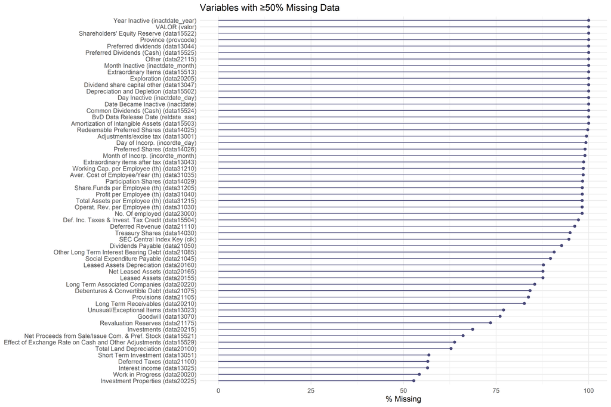

Figure 1: Variables with ≥50% missingness (2018-2021 combined). Bars show the percentage missing; only variables above the 50% threshold are plotted. Reference: Tutorial 8

```r
osiris_all_year <- bind_rows(osiris_list)

gg_miss_var(osiris_all_year %>%
  select(all_of(miss_var_summary(osiris_all_year) %>%
                filter(pct_miss >= 50) %>%
                pull(variable))), show_pct = TRUE) +
  coord_flip() +
  labs(title = "Variables with ≥50% Missing Data",
       x = NULL, y = "% Missing")
```

A visual summary was produced to highlight these variables, which were flagged to be excluded during the data cleaning stage to ensure that subsequent analyses are based on well-populated and consistent information.

**Constant variables Check**

```r
# Identify variables that have no variation (all missing or a single repeated value) across all records for removal.
const_vars <- osiris_all_year %>%
  summarise(across(everything(), ~ n_distinct(.x, na.rm = TRUE))) %>%
  pivot_longer(everything(), names_to = "variable", values_to = "n_unique") %>%
  filter(n_unique <= 1)

# List of empty/constant columns to consider dropping
const_vars
```

```
# A tibble: 24 × 2
   variable                             n_unique
   <chr>                                   <int>
 1 VALOR (valor)                               0
 2 BvD Data Release Date (reldate_sas)         0
 3 Province (provcode)                         0
 4 Country (country)                           1
 5 Country Code (cntrycde)                     1
 6 Date Became Inactive (inactdate)            0
 7 Year Inactive (inactdate_year)              0
 8 Month Inactive (inactdate_month)            0
 9 Day Inactive (inactdate_day)                0
10 Currency of the Statement (iso_curr)        1
# ℹ 14 more rows
```

Each variable was checked for the number of distinct (non-missing) values across all years. Twenty-four variables were found to be constant or entirely empty (`n_unique` ≤ 1).

Most of these fields—such as VALOR, BvD Data Release Date, Country, Currency, Template Category, and Preferred Dividends—contain either only missing values or a single repeated value (e.g., all “Thailand” or all “THB”).

These variables provide no analytical variation and were flagged for removal in the data-cleaning stage to maintain a concise and informative dataset for subsequent analysis.

**Initial Data Quality Check Summary**

The initial review confirmed that all four annual Osiris datasets (2018–2021) share a consistent structure, allowing reliable combination for further analysis. Missingness checks identified several variables with over 50 % missing values, which were flagged for later removal. The constant-variable test found 24 fields with no variation or entirely empty content (e.g., Country, Currency, Template Category), indicating redundant or uninformative data.

With these initial diagnostics complete, the next step is to clean and consolidate the datasets—selecting relevant variables, standardising financial years, and ensuring consistent naming for analysis.

#### Processing steps

**Select, Load, and Combine Data For Processing**

We begin by selecting key variables for analysis and then merge all years into one dataset.

```r
# ---- Select the key variables ----
key_vars <- c(
  "year",

  # ADD THIS ID COLUMN so we can filter by firm reliably
  "BvD ID Number (os_id_number)",

  # Company identification and basic information
  "Company Fiscal Year End Date (closdate)",
  "Consolidation Code (consol_code)",
  "Company Name (name)",
  "Listed/Unlisted/Delisted status (listed)",
  "CITY - City (city)",
  "Province (provcode)",
  "Status (status)",
  "Industrial Classification Benchmark (icb)",
  "US SIC, Core Code (csicuscde)",
  "NAICS Core Code (caics12cod)",
  "NACE Rev 1, Core Code (cnacecd)",
  "Template Name (tmplname)",
  "Template Category (tmplcat)",
  "Type of Statement Available (typeacc)",
  "Exchange Rate to US$ (exrate_usd)",
  "Audit Status (audstat)",

  # Key financial items
  "Total Current Assets (data13061)",
  "Net Stated Inventory (data20010)",
  "Total Cash & Short Term Investment (data20070)",
  "Investments (data20215)",
  "Investment Properties (data20225)",
  "Total Assets (data13077)",
  "Total Current Liabilities (data14011)",
  "Non Current Liabilities (data21060)",
  "Bank Loans (data21070)",
  "Pension Fund Provisions (data21095)",
  "Total Shareholders Equity (data14041)",
  "No. Of employed (data23000)",
  "Total revenues (data13004)",
  "Net sales (data13002)",
  "Other revenues (data13003)",
  "Earnings before Interest, Tax, Depreciation & Amortization (data13018)",
  "Earnings before Interest & Tax (data13024)",
  "Interest expenses (data13026)",
  "Earnings before tax (data13034)",
  "Earnings after tax (data13037)",
  "Net Profit (data13045)",
  "Net Income / Starting Line (data15500)",
  "Net Cash from Operating Activities (data15514)",
  "Net Cash used by Investing Activities (data15518)",
  "Net Cash provided by/used in Financing Activities (data15528)",
  "Inc/Dec in Cash & ST Investments (data15530)",
  "Cash & Equivalents at Beginning of Year (data15531)",
  "Cash & Equivalents at End of Year (data15532)",

  # Financial ratios and performance indicators
  "Profit Margin (%) (data31005)",
  "Return on Shareholders Funds (%) (data31010)",
  "Operat. Rev. per Employee (th) (data31030)",
  "Aver. Cost of Employee/Year (th) (data31035)",
  "Profit per Employee (th) (data31040)",
  "Cash Flow/Oper. Revenue (%) (data31045)",
  "Gross Margin (%) (data31050)",
  "EBIT Margin (%) (data31055)",
  "EBITDA Margin (%) (data31060)",
  "ROE (%) (data31065)",
  "ROA (%) (data31070)",
  "ROCE (%) (data31075)",
  "EV / EBITDA (data31080)",
  "Current ratio (data31105)",
  "Solvency ratio (%) (data31310)"
)

# ---- Load .rda, get the loaded object by name, select only needed columns
load_select <- function(path) {
  obj <- load(here(path))
  get(obj) |>
    select(any_of(key_vars))
}

# ---- Load each year and select columns immediately
th_2018 <- load_select("osiris/osiris_Thailand_2018.rda")
th_2019 <- load_select("osiris/osiris_Thailand_2019.rda")
th_2020 <- load_select("osiris/osiris_Thailand_2020.rda")
th_2021 <- load_select("osiris/osiris_Thailand_2021.rda")

# ---- Merge AFTER filtering
osiris_filtered <- bind_rows(th_2018, th_2019, th_2020, th_2021)

# ---- Clean column labels: remove codes in parentheses
names(osiris_filtered) <- gsub("\\s*\\([^\\)]+\\)", "", names(osiris_filtered))
```

**Variable Consistency Check**

Using the code below, we confirmed schema consistency across all yearly OSIRIS datasets. Each dataset contains **61 columns** with identical variable names and ordering.

```r
df_list <- list(th_2018, th_2019, th_2020, th_2021)

tibble(col_name = unlist(map(df_list, names))) %>%
  count(col_name, name = "frequency") %>%
  filter(frequency < 4)
```

**Standardize the Year column**

The original year field in OSIRIS is inconsistent with the actual financial statement period (e.g., a 2017 report may cover 2017/06/30-2018/06/30 but be recorded as 2017/05/31-2018/05/31). We therefore define a new `Financial Year` variable as the calendar year of the fiscal year end date (Company Fiscal Year End Date (closdate)).

```r
osiris_standard <- osiris_filtered %>%
  mutate(
    `Company Fiscal Year End Date` = as.Date(
      as.character(`Company Fiscal Year End Date`), "%Y%m%d"
    ),
    `Financial Year` = {
      yr <- as.integer(format(`Company Fiscal Year End Date`, "%Y"))
      mo <- as.integer(format(`Company Fiscal Year End Date`, "%m"))
      if_else(mo <= 6L, yr - 1L, yr)
    }
  ) %>%
  select(`Financial Year`, everything(), -year)
```

**De-duplicate and restrict to FY2018–FY2021**

Each annual OSIRIS extract contains two snapshots per company: the current fiscal year (t) and the prior year (t-1). To confirm this duplication, firm–year combinations appearing more than once were identified.

```r
# Check for duplicate firm-year records
dup_summary <- osiris_standard %>%
  count(`BvD ID Number`, `Financial Year`) %>%
  filter(n > 1) %>%
  summarise(
    n_firm_years = n(),
    n_duplicates = sum(n - 1)
  )

dup_summary %>%
  rename(
    `Firm-years with duplicates` = n_firm_years,
    `Extra duplicate rows`       = n_duplicates
  ) %>%
  kable(
    caption  = "Duplicate check — overall",
    align    = c("r","r"),
    booktabs = TRUE
  ) %>%
  kable_styling(full_width = FALSE, position = "center")
```

Duplicate check — overall

| Firm-years with duplicates | Extra duplicate rows |
| --- | --- |
| 2475 | 2476 |

A total of 2475 firm–year combinations were duplicated, corresponding to 2476 redundant entries. To ensure one observation per firm–year, duplicate rows were removed using `distinct()`.

We then restrict the dataset to the study period, FY2018 to FY2021, by keeping only records with Financial Year in 2018 to 2021.

```r
osiris_rm_dup <- osiris_standard %>%
  distinct() %>%
  filter(`Financial Year` %in% 2018:2021)
```

**Keep only firms with full 2018-2021 coverage**

To ensure comparability across time, we assessed coverage at the BvD ID level, avoiding the mix of consolidated and unconsolidated records for the same firm-year. Table 3 shows that the dataset is strongly balanced: 84% of firms appear in all four years (2018-2021), representing 88.5% of total records. A smaller share ends in 2018-2020 (12.2%), while other coverage patterns are rare (≤1%).

To maximize consistency and data integrity, our main analyses use the balanced 2018-2021 cohort (704 firms).

IDs with partial coverage are retained only for robustness checks.

```r
# Base: one row per ID/year
base_id_year <- osiris_rm_dup %>%
  filter(`Financial Year` %in% 2018:2021) %>%
  select(id = `BvD ID Number`, year = `Financial Year`) %>%
  distinct()

# Per-ID coverage summary
id_coverage <- base_id_year %>%
  group_by(id) %>%
  summarise(
    min_year = min(year),
    max_year = max(year),
    n_years  = n_distinct(year),
    years_str = paste(sort(unique(year)), collapse = ","),
    .groups = "drop"
  ) %>%
  mutate(
    consecutive = (max_year - min_year + 1L) == n_years,
    label = case_when(
      n_years == 1 ~ years_str,
      consecutive  ~ paste0(min_year, "-", max_year),
      TRUE         ~ years_str
    )
  )

# Counts, rows, and percentages per label
coverage_labels <- id_coverage %>%
  group_by(label) %>%
  summarise(
    `n IDs`  = n(),
    `n rows` = sum(n_years),
    .groups = "drop"
  ) %>%
  arrange(desc(`n IDs`)) %>%
  mutate(
    `Share of IDs (%)`  = sprintf("%.1f%%", 100 * `n IDs`  / sum(`n IDs`)),
    `Share of rows (%)` = sprintf("%.1f%%", 100 * `n rows` / sum(`n rows`))
  )

coverage_labels %>%
  kable(
    align = c("l", "r", "r", "r", "r"),
    caption = "BvD ID coverage by year label: counts and shares")
```

Table 3: BvD ID coverage by year label: counts and shares

| label | n IDs | n rows | Share of IDs (%) | Share of rows (%) |
| --- | --- | --- | --- | --- |
| 2018-2021 | 704 | 2816 | 84.0% | 88.5% |
| 2018-2020 | 102 | 306 | 12.2% | 9.6% |
| 2018-2019 | 8 | 16 | 1.0% | 0.5% |
| 2018 | 7 | 7 | 0.8% | 0.2% |
| 2019-2021 | 4 | 12 | 0.5% | 0.4% |
| 2020 | 3 | 3 | 0.4% | 0.1% |
| 2018,2019,2021 | 2 | 6 | 0.2% | 0.2% |
| 2018,2020 | 2 | 4 | 0.2% | 0.1% |
| 2018,2020,2021 | 2 | 6 | 0.2% | 0.2% |
| 2019 | 2 | 2 | 0.2% | 0.1% |
| 2019-2020 | 2 | 4 | 0.2% | 0.1% |

We retain only firms (`BvD ID Number`) with complete financial statements for all four years (2018-2021), ensuring a balanced panel for analysis.

```r
ids_1820_balanced <- osiris_rm_dup %>%
  filter(`Financial Year` %in% 2018:2021) %>%
  distinct(`BvD ID Number`, `Financial Year`) %>%
  count(`BvD ID Number`, name = "n_years") %>%
  filter(n_years == 4) %>%
  pull(`BvD ID Number`)

osiris_selected <- osiris_rm_dup %>%
  filter(`Financial Year` %in% 2018:2021,
         `BvD ID Number` %in% ids_1820_balanced)
```

**Data Check**

Table 4 compares observation counts before and after de-duplication, keeping only firms with full FY2018-FY2021 coverage.

Most years retain around 43-44% of records, consistent with removing the prior-year duplicates (each firm appearing twice per extract).

For FY2021, the retention rate is 99% because the 2022 extract does not yet exist, hence no overlapping prior-year data to remove.

Overall, approximately 50% of records are retained, confirming that one unique record per firm-year was preserved correctly.

```r
compare_tbl <- osiris_standard %>%
  filter(`Financial Year` %in% 2018:2021) %>%
  count(`Financial Year`, name = "before") %>%
  left_join(
    osiris_selected %>% count(`Financial Year`, name = "after"),
    by = "Financial Year"
  ) %>%
  mutate(
    `Retained (%)` = after / before * 100
  ) %>%
  arrange(`Financial Year`)

# Add total row
compare_tbl <- bind_rows(
  compare_tbl %>% mutate(`Financial Year` = as.character(`Financial Year`)),
  tibble(
    `Financial Year` = "Total",
    before = sum(compare_tbl$before),
    after = sum(compare_tbl$after),
    `Retained (%)` = sum(compare_tbl$after) / sum(compare_tbl$before) * 100
  )
)

# Rename and display
compare_tbl %>%
  rename(
    Year = `Financial Year`,
    `Observations (Before)` = before,
    `Observations (After)` = after
  ) %>%
  kable(
    align = c("l", "r", "r", "r"),
    caption = "Observations before vs after de-duplication (FY2018-FY2021)"
  )
```

Table 4: Observations before vs after de-duplication (FY2018-FY2021)

| Year | Observations (Before) | Observations (After) | Retained (%) |
| --- | --- | --- | --- |
| 2018 | 1654 | 704 | 43 |
| 2019 | 1648 | 704 | 43 |
| 2020 | 1608 | 704 | 44 |
| 2021 | 712 | 704 | 99 |
| Total | 5622 | 2816 | 50 |

**Missingness check**

```r
missing_tbl <- osiris_selected %>%
  summarise(across(everything(), ~ sum(is.na(.)))) %>%
  pivot_longer(everything(), names_to = "variable", values_to = "n_miss") %>%
  mutate(pct_miss = round(n_miss / nrow(osiris_selected) * 100, 2)) %>%
  arrange(desc(pct_miss))

datatable(
  missing_tbl,
  options = list(pageLength = 10),
  caption = "Missing values by variable"
)
```

|  | variable | n_miss | pct_miss |
| --- | --- | --- | --- |
| 1 | Province | 2816 | 100 |
| 2 | Aver. Cost of Employee/Year | 2769 | 98.33 |
| 3 | No. Of employed | 2763 | 98.12 |
| 4 | Operat. Rev. per Employee | 2763 | 98.12 |
| 5 | Profit per Employee | 2763 | 98.12 |
| 6 | Investments | 2020 | 71.73 |
| 7 | Investment Properties | 1391 | 49.4 |
| 8 | Bank Loans | 1257 | 44.64 |
| 9 | EV / EBITDA | 712 | 25.28 |
| 10 | Net Stated Inventory | 502 | 17.83 |

[output cut: 51 more lines]

The missingness summary identifies the proportion of missing values for each variable after cleaning and consolidation.

Variables with extensive missingness (e.g., above 50%) will be reviewed in the next section to determine whether they should be dropped, imputed, or retained for partial analysis.

### Handling Variables with Data Quality Issues

#### Review Variables with Major Missingness

Although several variables exhibit more than 50 % missing values, only those that are clearly uninformative or structurally incomplete (i.e., with more than 80 % missingness) were removed from the dataset. This ensures that key financial variables with partial but meaningful data are retained for analysis.

```r
miss80_drop <- missing_tbl %>%
  filter(pct_miss > 80) %>%
  pull(variable)

osiris_selected <- osiris_selected %>%
  select(-any_of(miss80_drop))
```

Their retention allows for meaningful analysis of differences between firms that do and do not engage in investment activities.

**Investments**

This variable represents the total long-term investments, including quoted and unquoted investments, own shares, and treasury bonds.

Although it shows 71.73% missing values. The dataset does not provide sufficient information to verify whether missing values represent true zeros or unreported data. Since this item is not derived from other accounting components but directly reported in financial statements, we cannot infer its value from related variables.

```r
# filter the non-missing value
osiris_inv <- osiris_selected %>%
  filter(!is.na(Investments))

# summary as a small table
tibble(
  Metric = c("Distinct companies", "Distinct NAICS Core Codes"),
  Value  = c(
    n_distinct(osiris_inv$`Company Name`),
    n_distinct(osiris_inv$`NAICS Core Code`)
  )
) %>%
  kable(caption = "Coverage for non-missing Investments")
```

Table 5: Coverage for non-missing Investments

| Metric | Value |
| --- | --- |
| Distinct companies | 308 |
| Distinct NAICS Core Codes | 114 |

**Investment Properties**

This variable captures total investment property assets, including valuation and cost adjustments, accumulated depreciation, impairments, rental guarantees, lease receivables, and properties held for sale.

Following the same rationale as as Investments, this is a directly disclosed line (not derivable), so NAs occur when the statement doesn’t present this item or it’s not applicable to the business model.

```r
# filter the non-missing value
osiris_invprop <- osiris_selected %>%
  filter(!is.na(`Investment Properties`))

# summary as a small table
tibble(
  Metric = c("Distinct companies", "Distinct NAICS Core Codes"),
  Value  = c(
    n_distinct(osiris_invprop$`Company Name`),
    n_distinct(osiris_invprop$`NAICS Core Code`)
  )
) %>%
  kable(caption = "Coverage for non-missing Investment Properties")
```

Table 6: Coverage for non-missing Investment Properties

| Metric | Value |
| --- | --- |
| Distinct companies | 400 |
| Distinct NAICS Core Codes | 131 |

#### Review Remaining Variables

##### Company Information

- **Spatial:**
  - **Drop**: `CITY - City` - 0.14% missing. Because the vast majority of firms are concentrated in the Central region, there are too few observations from other regions to support any meaningful spatial or regional comparison. Therefore, spatial analysis is not feasible, and this variable is dropped from further analysis.

```r
# Extract Unique Cities
unique_cities <- osiris_selected %>%
  mutate(city = `CITY - City`) %>%
  filter(!is.na(`CITY - City`)) %>%
  distinct(`CITY - City`) %>%
  arrange(`CITY - City`) %>%
  pull()

# Standardize city names to Province Level
osiris_regional_geo <- osiris_selected %>%
  mutate(city = `CITY - City`) %>%
  mutate(
    province_clean = case_when(
      str_detect(city, "BANGKOK|BANGNA|BAGNA|SATHORN|HUAI KHWANG|JATUJAK|LADPRAO|PRAWET|BANGPAKOK|BANGRAK|LAT PHRAO|LUMPINI|PATHUMWAN|PHAYATHAI|WANG THONGLANG") ~ "BANGKOK",
      str_detect(city, "NONTHABURI|PAK KRET|PAKKRED|BANG MAE NANG|BANG YAI|LAHAN|PAKKRET") ~ "NONTHABURI",
      str_detect(city, "PATHUM THANI|PATHUMTHANI|KLONG LUANG|LUMLUKKA|BUENGYEETHO|KHLONG LUANG|PRATHUMTANI|SAM KHOK") ~ "PATHUM THANI",
      str_detect(city, "SAMUT PRAKAN|SAMUTPRAKAN|SAMUT PRAKARN|SAMUTPRAKARN|BANG PHLE|PHRA PRADAENG|BANG SAO THONG|BANGSAOTHONG|PHRA SAMUT CHEDI|PHRAPRADAENG|PRAPADAENG") ~ "SAMUT PRAKAN",
      str_detect(city, "SAMUT SAKHON|SAMUTSAKHON|SAMUTSAKORN|KRATUMBAN") ~ "SAMUT SAKHON",
      str_detect(city, "NAKHON PATHOM|NAKORN PHATHOM|NAKORN PRATHOM|NAKORNPATHOM|SAM PHRAN|MUANG NAKHONPATHOM, NAKHONPATHOM|RAI KHING") ~ "NAKHON PATHOM",
      str_detect(city, "CHON BURI|CHONBURI|SIRACHA|PATTAYA") ~ "CHON BURI",
      str_detect(city, "RAYONG|KLAENG") ~ "RAYONG",
      str_detect(city, "CHACHOENGSAO|CHACHERNGSAO") ~ "CHACHOENGSAO",
      str_detect(city, "PHUKET") ~ "PHUKET",
      str_detect(city, "CHIANG MAI|CHIANGMAI") ~ "CHIANG MAI",
      str_detect(city, "KRABI") ~ "KRABI",
      str_detect(city, "SURAT THANI|DON SAK") ~ "SURAT THANI",
      str_detect(city, "SONGKHLA|HAT YAI") ~ "SONGKHLA",
      str_detect(city, "AYUTTHAYA|AYUTTHYA|AMPHUR UTHAI") ~ "AYUTTHAYA",
      str_detect(city, "KHON KAEN|KHONKEAN") ~ "KHON KAEN",
      str_detect(city, "NAKHON RATCHASIMA") ~ "NAKHON RATCHASIMA",
      str_detect(city, "SARABURI") ~ "SARABURI",
      str_detect(city, "PRACHIN BURI") ~ "PRACHIN BURI",
      str_detect(city, "BURIRAM|PRAKHONCHAI DISTRICT") ~ "BURIRAM",
      str_detect(city, "LAMPANG") ~ "LAMPANG",
      str_detect(city, "LAMPHUN") ~ "LAMPHUN",
      str_detect(city, "UDON THANI") ~ "UDON THANI",
      str_detect(city, "MUANG CHIANGRAI") ~ "CHIANG RAI",
      str_detect(city, "MUANG CHUMPHON, CHUMPHON") ~ "CHUMPHON",
      str_detect(city, "MUANG MAHASARAKHAM, MAHASARAKHAM") ~ "MAHASARAKHAM",
      str_detect(city, "MUANG TRANG") ~ "TRANG",
      str_detect(city, "UTTARADIT") ~ "UTTARADIT",
      str_detect(city, "WARIN SHAMRAP, UBONRATCHATHANI") ~ "UBONRATCHATHANI",
      str_detect(city, "CHAINART") ~ "CHAINART",
      TRUE ~ NA_character_ # Assign NA to unhandled cities
    )
  ) %>%

  # Geographical Classification - Group provinces into 6 standard regions
  mutate(
    region_geo = case_when(
      # 1. Central Region
      province_clean %in% c("BANGKOK", "NONTHABURI", "PATHUM THANI", "SAMUT PRAKAN",
                            "SAMUT SAKHON", "NAKHON PATHOM", "AYUTTHAYA", "SARABURI", "CHAINART") ~ "Central",

      # 2. East Region
      province_clean %in% c("CHON BURI", "RAYONG", "CHACHOENGSAO", "PRACHIN BURI") ~ "East",

      # 3. South Region
      province_clean %in% c("PHUKET", "KRABI", "SURAT THANI", "SONGKHLA", "CHUMPHON", "TRANG") ~ "South",

      # 4. North Region
      province_clean %in% c("CHIANG MAI", "LAMPANG", "LAMPHUN", "CHIANG RAI", "UTTARADIT") ~ "North",

      # 5. Northeast (Isan) Region
      province_clean %in% c("KHON KAEN", "NAKHON RATCHASIMA", "BURIRAM", "UDON THANI", "MAHASARAKHAM", "UBONRATCHATHANI") ~ "Northeast (Isan)",

      # 6. West Region
      province_clean %in% c("KANCHANABURI", "PHETCHABURI") ~ "West",

      # Catch-all for everything else
      TRUE ~ "Unclassified"
    )
  )

osiris_regional_geo %>%
  count(region_geo, sort = TRUE) %>%
  kable(caption = "Number of Firm-Year Observations by Geographical Region")
```

Table 7: Number of Firm-Year Observations by Geographical Region

| region_geo | n |
| --- | --- |
| Central | 2548 |
| East | 124 |
| South | 48 |
| Northeast (Isan) | 40 |
| North | 28 |
| Unclassified | 28 |

- **Industry classification codes:**
  - **Keep**: `NAICS Core Code` as the primary taxonomy. Although `US SIC, Core Code` has slightly lower missingness, `NAICS` offers finer, more modern industry granularity (especially for services and tech). We will harmonise all industry analysis to 2-4-digit NAICS. When `NAICS Core Code` is missing, we will backfill via crosswalks from SIC/ICB and manual company lookups where needed.
  - **Drop**: `US SIC, Core Code`, `Industrial Classification Benchmark (ICB)`, and `NACE Rev 1, Core Code` from the analytical dataset to avoid multi-coding the same concept. These fields are retained only as temporary helpers for backfilling `NAICS`, then excluded from final analyses.

  We completed missing NAICS codes by manually assigning the most appropriate industry based on each company’s public description/name, filling only NAs and leaving existing codes unchanged.

```r
naics_lookup <- c(
  "ASIA AVIATION PCL" = "4811",
  "ASSET WORLD CORP PUBLIC COMPANY LIMITED" = "7211",
  "AUTOCORP HOLDING PCL" = "4411",
  "BBGI PUBLIC COMPANY LIMITED" = "3251",
  "BOUTIQUE CORPORATION PUBLIC COMPANY LIMITED" = "7211",
  "HEMARAJ LEASEHOLD REAL ESTATE INVESTMENT TRUST" = "5259",
  "LH HOTEL LEASEHOLD REAL ESTATE INVESTMENT TRUST" = "5259",
  "PM THORESEN ASIA HOLDINGS PCL" = "3253",
  "PRAKIT HOLDINGS PCL" = "5418",
  "SAHA PATHANA INTER-HOLDING PLC" = "5511",
  "THAI ENGER HOLDING PCL" = "2362",
  "TRINITY WATTHANA PCL" = "5231"
)

osiris_selected <- osiris_selected %>%
  mutate(`NAICS Core Code` = if_else(
    is.na(`NAICS Core Code`),
    unname(naics_lookup[`Company Name`]),
    as.character(`NAICS Core Code`)
  ))
```

We also mutated a new variable, `Industry Category`, as a general sector label by taking the first two digits of NAICS Core Code (with standard consolidations 31-33, 44-45, 48-49). This yields larger, more stable groups for EDA, while the original 4-digit NAICS is retained for traceability and drill-down whenever we spot interesting patterns.

```r
naics_code_definition <- tribble(
  ~naics_prefix, ~`Industry Category`,
  "11","Agriculture, Forestry, Fishing, Hunting",
  "21","Mining, Quarrying, Oil, Gas Extraction",
  "22","Utilities",
  "23","Construction",
  "31-33","Manufacturing",
  "42","Wholesale Trade",
  "44-45","Retail Trade",
  "48-49","Transportation and Warehousing",
  "51","Information",
  "52","Finance and Insurance",
  "53","Real Estate, Rental, Leasing",
  "54","Professional, Scientific, Tech. Services",
  "55","Mgmt. of Companies & Enterprises",
  "56","Administrative, Support, Waste Mgmt., Remediation Services",
  "61","Educational Services",
  "62","Health Care and Social Assistance",
  "71","Arts, Entertainment, Recreation",
  "72","Accommodation and Food Services",
  "81","Other Services (except Public Administration)",
  "92","Public Administration"
)

osiris_selected <- osiris_selected %>%
  mutate(
    naics2 = substr(`NAICS Core Code`, 1, 2),
    consol = case_when(
      naics2 %in% c("31","32","33") ~ "31-33",
      naics2 %in% c("44","45") ~ "44-45",
      naics2 %in% c("48","49") ~ "48-49",
      TRUE ~ naics2
    )
  ) %>%

  left_join(naics_code_definition, by = c("consol" = "naics_prefix")) %>%
  select(-naics2, -consol)
```

- **Consolidation Code / Type of Statement Available**
  - **Keep**: `Consolidation Code`. We retain C1 and C2 (consolidated statements) for analysis to ensure a consistent reporting basis across firms. Records coded U1/U2 (unconsolidated) and C* (ambiguous/unknown companion status) are excluded to avoid mixing reporting scopes and potential double counting.
  - **Drop**: `Type of Statement Available`. This field largely duplicates the information in `Consolidation Code` (e.g., “Consolidated” ≈ C1; “Cons. & Uncons.” ≈ C2/U2). To prevent redundancy and confusion, we exclude it from the analytical dataset after filtering by Consolidation Code.

  Table Table 8 summarises the distribution of consolidation codes before filtering.

```r
tbl_consol_code <- osiris_selected %>%
  group_by(`Consolidation Code`) %>%
  summarise(
    n_records = n(),
    pct = round(100 * n() / nrow(osiris_selected), 2),
    .groups = "drop"
  ) %>%
  arrange(desc(n_records))

kable(
  tbl_consol_code,
  caption = "Distribution of Consolidation Code in the OSIRIS Thailand dataset (Before)",
  col.names = c("Consolidation Code", "Number of Records", "Percentage (%)"),
  align = c("c", "r", "r")
)
```

Table 8: Distribution of Consolidation Code in the OSIRIS Thailand dataset (Before)

| Consolidation Code | Number of Records | Percentage (%) |
| --- | --- | --- |
| C1 | 2800 | 99.43 |
| C2 | 12 | 0.43 |
| C* | 4 | 0.14 |

```r
osiris_selected <- osiris_selected %>%
  filter(`Consolidation Code` %in% (c("C1", "C2")))
```

- **BvD ID Number**

  **Drop**: 0% missing. Serves solely as the unique firm identifier to link years and build the balanced panel, but it is not an analytical feature, we remove it from the final analysis dataset.
- **Company Fiscal Year End Date**

  **Drop**: 0% missing. We already transformed this date into a standardized Financial Year (Jan-Jun → prior FY; Jul-Dec → same FY). After alignment, the raw close date adds no incremental analytical value, so we drop it from the analysis dataset
- **Template Name / Template Category**

  **Drop**: 0 missing. For `Template Name`, despite labeling statement templates (e.g., Industry (Anglo / Continental / Trust)) and a category field, our checks show no material impact on numeric definitions, and `Template Category` is effectively constant (e.g., IND), providing no analytic variation.
- **Audit Status**

  **Drop**: 0 missing. The category distribution is overwhelmingly Unqualified (≈ 98%), with very few Qualified/Qualified n.a. cases (≈ 2%), yielding insufficient variation for meaningful stratification or inference. Given its limited incremental relevance to our primary outcomes and potential confounding by industry/size, we drop it from the analysis dataset.

```r
audit_dist <- osiris_selected %>%
  count(`Audit Status`, name = "n") %>%
  mutate(pct = round(100 * n / sum(n), 2)) %>%
  arrange(desc(n))

kable(audit_dist,
             caption = "Audit Status distribution",
             col.names = c("Audit Status", "Count", "Percent (%)"),
             align = c("l","r","r"))
```

Audit Status distribution

| Audit Status | Count | Percent (%) |
| --- | --- | --- |
| Unqual | 2756 | 98.01 |
| Qual | 31 | 1.10 |
| Qualif n.a. | 25 | 0.89 |

- **Listed/Unlisted/Delisted status**

  **Drop**: 0 missing. The distribution of `Listed/Unlisted/Delisted status` (Table 9) is identical across all four years, with 694 firms listed and only 9 delisted throughout 2018–2021. This indicates no temporal or cross-sectional variation, meaning the variable cannot contribute explanatory value to subsequent analyses. It is therefore excluded from the analytical dataset.

```r
# Check Listed/Unlisted/Delisted status distribution by year
listed_status_summary <- osiris_selected %>%
  group_by(`Financial Year`, `Listed/Unlisted/Delisted status`) %>%
  summarise(n_companies = n_distinct(`BvD ID Number`), .groups = "drop") %>%
  arrange(`Financial Year`, desc(n_companies))

listed_status_summary %>%
  kable(
    caption = "Distribution of Listed/Unlisted/Delisted Companies by Year",
    col.names = c("Financial Year", "Status", "Number of Companies"),
    align = c("c", "l", "r")
  )
```

Table 9: Distribution of Listed/Unlisted/Delisted Companies by Year

| Financial Year | Status | Number of Companies |
| --- | --- | --- |
| 2018 | Listed | 694 |
| 2018 | Delisted | 9 |
| 2019 | Listed | 694 |
| 2019 | Delisted | 9 |
| 2020 | Listed | 694 |
| 2020 | Delisted | 9 |
| 2021 | Listed | 694 |
| 2021 | Delisted | 9 |

##### Income Statement

- **Net Sales**

  It represents revenue from a company’s core operations, after deducting returns, allowances, and discounts.

  Missing values in `Net sales` may partly reflect industry characteristics. In addition, certain missing observations likely result from data loss within the source dataset rather than the lack of actual values.

$$\textsf{Total revenues = Net sales + Other revenues}$$

- **Other Revenues**

  It refers to income generated from a company’s non-core business activities, such as interest income, gains from asset sales, or rental income.

  Missing values in `Other revenues` may occurs when not reported in the income statement, reflecting the absence on financial statements rather than missing data.
- **Total Revenues**

  It combines core (`Net Sales`) and non-core (`Other Revenues`) income, reflecting a company’s overall earnings capacity. This provides a comprehensive view of a firm’s total income-generating ability before any costs or expenses are deducted.

  Missing values in `Total revenues` likely occur when the income statement for a given year is incomplete or unavailable. In some cases, firms that primarily earn interest income do not report a separate total revenue item, resulting in missing values.
- **Interest Expenses**

  It represents the total cost incurred by a company on borrowed funds, such as bank loans and bonds.

  Missing values in `Interest expenses` may occur when the underlying data are unavailable or when firms have no outstanding debt or bank loans during the fiscal year.
- **Earnings before Interest, Tax, Depreciation & Amortization**

  This captures a firm’s operating performance by excluding financing and accounting effects, offering a proxy for cash-based profitability.

  Missing values in EBITDA may occur when the underlying components required for its calculation are incomplete or unavailable. In such cases, the variable was excluded from the analysis to maintain consistency and comparability across firms.

  EBITDA is computed as:

$$\textsf{EBITDA = Total Revenues - Cost of Goods Sold + Research and Development Expenses + Other Operating Items}$$

##### Balance Sheet

- **Bank Loans**

  The presence/absence of loans is itself informative, and banks typically assess creditworthiness via ratios (like `current ratio`, `liquidity ratio`, `ROE`), not just raw loan balances.
  - **Keep**: `Bank Loans` has 44.64% missing values. NAs occur when the item is not applicable for that year. At the firm level we see two patterns: (i) companies with all four years NA, and (ii) companies with partial coverage across years. Because both patterns can reflect either true absence of bank borrowing or unreported/not-mapped data, we cannot reclassify NA as zero or impute it reliably.

    Table 10 shows 467 distinct companies across 149 industries remain, indicating sufficient cross-firm and cross-industry coverage for analysis.

```r
# filter the non-missing value
osiris_invprop <- osiris_selected %>%
  filter(!is.na(`Bank Loans`))

# summary as a small table
tibble(
  Metric = c("Distinct companies", "Distinct NAICS Core Codes"),
  Value  = c(
    n_distinct(osiris_invprop$`Company Name`),
    n_distinct(osiris_invprop$`NAICS Core Code`)
  )
) %>%
  kable(caption = "Coverage for non-missing Bank Loans")
```

Table 10: Coverage for non-missing Bank Loans

| Metric | Value |
| --- | --- |
| Distinct companies | 467 |
| Distinct NAICS Core Codes | 149 |

  It represents the total value of inventories held by the company.
  - **Keep:** Although 17.83% of entries are missing, this is expected and informative. For firms that show inventory in some years but NA in other years, it is generally not plausible that the company suddenly reduced inventory to exactly zero for a year and then resumed normal levels without a major strategic change.

    These sectors are primarily financial or service-oriented and typically hold few or no physical inventories, so the absence of inventory data reflects business model characteristics rather than reporting gaps.

    Table 11 shows the company-level coverage of Net Stated Inventory (2018-2021).

```r
# Coverage categories for Net Stated Inventory
nsi_coverage_summary <- osiris_selected %>%
  group_by(`BvD ID Number`) %>%
  summarise(
    n_years = n_distinct(`Financial Year`),
    n_nonmiss = sum(!is.na(`Net Stated Inventory`)),
    .groups = "drop"
  ) %>%
  mutate(
    coverage_type = case_when(
      n_nonmiss == 0 ~ "All 4 years missing",
      n_nonmiss < n_years ~ "Partial coverage",
      n_nonmiss == n_years ~ "Complete 4-year coverage"
    )
  ) %>%
  count(coverage_type, name = "n_companies") %>%
  mutate(
    pct = round(100 * n_companies / sum(n_companies), 1)
  )

kable(
  nsi_coverage_summary,
  caption = "Company-level coverage of Net Stated Inventory (2018-2021)",
  align = c("l", "r", "r")
)
```

Table 11: Company-level coverage of Net Stated Inventory (2018-2021)

| coverage_type | n_companies | pct |
| --- | --- | --- |
| All 4 years missing | 104 | 14.8 |
| Complete 4-year coverage | 553 | 78.7 |
| Partial coverage | 46 | 6.5 |

Table 12 shows industries where all 4 years of Net Stated Inventory are missing.

```r
nsi_missing_full <- osiris_selected %>%
  group_by(`BvD ID Number`, `NAICS Core Code`) %>%
  summarise(
    n_years   = n_distinct(`Financial Year`),
    n_missing = sum(is.na(`Net Stated Inventory`)),
    .groups = "drop"
  ) %>%
  mutate(full_missing = n_missing == n_years) %>%
  group_by(`NAICS Core Code`) %>%
  summarise(
    total_companies        = n_distinct(`BvD ID Number`),
    missing_companies_full = sum(full_missing),
    pct_missing_full       = round(100 * missing_companies_full / total_companies, 1),
    .groups = "drop"
  ) %>%
  filter(pct_missing_full > 0) %>%
  mutate(`NAICS Code` = as.character(`NAICS Core Code`)) %>%
  select(`NAICS Code`, total_companies, missing_companies_full, pct_missing_full) %>%
  arrange(desc(pct_missing_full))

datatable(
  nsi_missing_full,
  options = list(pageLength = 5),
  caption = "Industries where all 4 years of Net Stated Inventory are missing"
)
```

Table 12

|  | NAICS Code | total_companies | missing_companies_full | pct_missing_full |
| --- | --- | --- | --- | --- |
| 1 | 4231 | 1 | 1 | 100 |
| 2 | 5242 | 1 | 1 | 100 |
| 3 | 5259 | 8 | 8 | 100 |
| 4 | 5613 | 1 | 1 | 100 |
| 5 | 5629 | 1 | 1 | 100 |
| 6 | 9221 | 1 | 1 | 100 |
| 7 | 5239 | 11 | 9 | 81.8 |
| 8 | 5191 | 5 | 4 | 80 |
| 9 | 5311 | 29 | 21 | 72.4 |
| 10 | 4889 | 5 | 3 | 60 |

[output cut: 26 more lines]

##### Cash Flow Statement

**Note**

We do not use any variables from the cash-flow statement in the analysis. Many of these fields have substantial missing values; when a higher-level line is missing, the component lines needed to recalculate it are typically missing or inconsistently mapped.

Consequently, we exclude cash-flow figures from cross-firm comparisons and focus instead on income-statement and balance-sheet items, as well as other financial variables.

- **Net Income / Starting Line**

  The starting point for the cash-flow statement, intended to align with bottom-line profit before non-cash adjustments.
  - Per the data guide, this field should match `Net Profit`, but in OSIRIS it excludes “Total net unrealized gain on investments,” while `Net Profit` includes it. The mismatch makes it unreliable as a standalone profitability measure.
- **Three Cash Flow Activities**
  - Operating activities (CFO) - cash generated or used by the company’s core business operations, such as receipts from customers, payments to suppliers, wages, and taxes.
  - Investing activities (CFI) - cash flows related to long-term assets and investments, including purchases or sales of property, equipment, and securities.
  - Financing activities (CFF) - cash flows arising from funding the business, such as borrowing, repaying loans, issuing or repurchasing shares, and paying dividends.

- **Inc/Dec in Cash & ST Investments**

  It represents the net change in a company’s cash over the fiscal year. It reflects the overall cash movement resulting from operating, investing, and financing activities combined.
- **Cash & Equivalents at Beginning of Year / Cash & Equivalents at End of Year**

  These variables represent the opening and closing balances of a company’s cash and cash-equivalent holdings for the fiscal year.

#### Ratio Imputation and Recalculation

To evaluate firms’ financial performance during the pandemic, five key ratios were selected: **ROA**, **ROCE**, **EBIT Margin**, **Solvency Ratio**, and **Current Ratio**. These capture profitability, efficiency, solvency, and liquidity.

Although all ratios are reported in OSIRIS, some contain minor missingness (<5%).

Where base components (e.g., EBIT, Total Assets, Current Assets, Liabilities, Equity) were complete, ratios were recalculated directly to ensure internal consistency.

For variables with missing values, industry–year median imputation was applied to maintain comparability across firms and years.

- **ROA (Return on Assets)** measures how efficiently a company uses its assets to generate profits.

$$\textsf{ROA (\%)} =
\left( \dfrac{\textsf{Net Profit}}{\textsf{Total Assets}} \right) \times 100$$

- **ROCE(Return on Capital Employed)** evaluates the return generated from long-term capital, reflecting overall capital efficiency.

$$\textsf{ROCE (\%)} =
\left( \dfrac{\textsf{Net Profit} - \textsf{Interest Expenses}}
{\textsf{Total Shareholders' Equity} + \textsf{Non-Current Liabilities}} \right) \times 100$$

- **EBIT Margin (Earnings Before Interest and Tax Margin)** indicates the profitability of core operations, showing how much of revenue is converted into operating profit.

$$\textsf{EBIT Margin (\%)} =
\left( \dfrac{\textsf{Earnings Before Interest \& Tax}}
{\textsf{Total Revenues}} \right) \times 100$$

- **Solvency ratio** assesses financial stability and long-term debt-paying capacity.

$$\textsf{Solvency Ratio (\%)} =
\left( \dfrac{\textsf{Total Shareholders' Equity}}
{\textsf{Total Assets}} \right) \times 100$$

$$\textsf{Current Ratio (\%)} =
\dfrac{\textsf{Total Current Assets}}
{\textsf{Total Current Liabilities}}$$

##### Imputation

After comparing the underlying variables with the missing value table, some variables were found to have missing observations. For these variables, industry–year median imputation was applied to fill in the gaps and maintain consistency across firms within the same industry.

**Interest Expenses Imputed:** Creating a new variable called `Interest Expenses Imputed`.

If **Bank Loans + Non-Current Liabilities = 0**, the missing value was replaced with 0; otherwise, it was imputed using the industry median (based on NAICS Core Code).

```r
osiris_impute <- osiris_selected |>
  mutate(
    .year = `Financial Year`,
    # global median
    .global_median_ie = median(`Interest expenses`, na.rm = TRUE)) |>
  # categorise by industry x financial year
  group_by(`NAICS Core Code`, .year) |>
  mutate(
    .industry_median_ie = median(`Interest expenses`, na.rm = TRUE),
    `Interest_expense_Imputed` = case_when(
      # bank loan and non-current L both 0 or both NA
      is.na(`Interest expenses`) &
        ( (is.na(`Bank Loans`) | `Bank Loans` == 0) &
          (is.na(`Non Current Liabilities`) | `Non Current Liabilities` == 0) ) ~ 0,
      # one of bank loan and non-current L not 0 or NA
      is.na(`Interest expenses`) &
        ( (!is.na(`Bank Loans`) & `Bank Loans` != 0) |
          (!is.na(`Non Current Liabilities`) & `Non Current Liabilities` != 0) ) &
        !is.na(.industry_median_ie) ~ .industry_median_ie,
      # one of bank loan and non-current L not 0 or NA
      # but insudtry median = NA
      is.na(`Interest expenses`) &
        ( (!is.na(`Bank Loans`) & `Bank Loans` != 0) |
          (!is.na(`Non Current Liabilities`) & `Non Current Liabilities` != 0) ) &
        is.na(.industry_median_ie) ~ .global_median_ie,
      # Otherwise remained
      TRUE ~ `Interest expenses`
    )
  ) |>
  ungroup() |>
  select(-.global_median_ie, -.industry_median_ie, -.year)
```

Compare the distribution of `Interest Expenses` before and after to check whether the imputed values maintain a reasonable scale and reduce missing observations without distorting the distribution.

The table shows that most missing values were resolved through imputation, and the overall distribution remained consistent with the original data.

```r
# compare yearly before and after
inex_impute_compare <- osiris_impute |>
  group_by(`Financial Year`) |>
  summarise(
    Min_Before = min(`Interest expenses`, na.rm = TRUE),
    Min_After  = min(`Interest_expense_Imputed`, na.rm = TRUE),
    Median_Before = median(`Interest expenses`, na.rm = TRUE),
    Median_After  = median(`Interest_expense_Imputed`, na.rm = TRUE),
    Mean_Before = mean(`Interest expenses`, na.rm = TRUE),
    Mean_After  = mean(`Interest_expense_Imputed`, na.rm = TRUE),
    Max_Before = max(`Interest expenses`, na.rm = TRUE),
    Max_After  = max(`Interest_expense_Imputed`, na.rm = TRUE),
    NAs_Before = sum(is.na(`Interest expenses`)),
    NAs_After  = sum(is.na(`Interest_expense_Imputed`))
  )

# summary as a table
kable(inex_impute_compare,
      caption = "Yearly Comparison of Interest Expenses Before and After Imputation",
      digits = 2,
      align = "lrrrrr")
```

Yearly Comparison of Interest Expenses Before and After Imputation

| Financial Year | Min_Before | Min_After | Median_Before | Median_After | Mean_Before | Mean_After | Max_Before | Max_After | NAs_Before | NAs_After |
| --- | --- | --- | --- | --- | --- | --- | --- | --- | --- | --- |
| 2018 | 0 | 0 | 20308 | 18996 | 297995 | 286977 | 2.8e+07 | 2.8e+07 | 27 | 0 |
| 2019 | -320 | -320 | 21361 | 20354 | 329814 | 319112 | 2.8e+07 | 2.8e+07 | 37 | 0 |
| 2020 | -5141 | -5141 | 25256 | 22992 | 386663 | 380134 | 2.9e+07 | 2.9e+07 | 22 | 0 |
| 2021 | 0 | 0 | 21772 | 21271 | 412790 | 406379 | 2.8e+07 | 2.8e+07 | 20 | 0 |

**Total Revenues Imputed:** Creating a new variable called `Total Revenues Imputed`.

Missing values were imputed using the industry median (based on NAICS Core Code) to maintain consistency and comparability across firms within the same industry.

```r
osiris_impute <- osiris_impute |>
  mutate(.year = `Financial Year`,
         # global median
         .global_med_tr = median(`Total revenues`, na.rm = TRUE)) |>
  # categorise by industry x financial year
  group_by(`NAICS Core Code`, .year) |>
  mutate(.ind_med_tr = median(`Total revenues`, na.rm = TRUE)) |>
  ungroup() |>
  mutate(
    `Total_revenues_Imputed` = case_when(
      # replace NA with industry median
      is.na(`Total revenues`) & !is.na(.ind_med_tr) ~ .ind_med_tr,
      # if no industry using global median
      is.na(`Total revenues`) & is.na(.ind_med_tr) ~ .global_med_tr,
      # otherwise remain
      TRUE ~ `Total revenues`
    )
  ) |>
  select(-.ind_med_tr, -.global_med_tr, -.year)
```

Compare the distribution of `Total Revenues` before and after to check whether the imputed values maintain a reasonable scale and reduce missing observations without distorting the distribution.

The table shows that most missing values were resolved through imputation, and the overall distribution remained consistent with the original data.

```r
# compare yearly before and after
trv_impute_compare <- osiris_impute |>
  group_by(`Financial Year`) |>
  summarise(
    Min_Before = min(`Total revenues`, na.rm = TRUE),
    Min_After  = min(`Total_revenues_Imputed`, na.rm = TRUE),
    Median_Before = median(`Total revenues`, na.rm = TRUE),
    Median_After  = median(`Total_revenues_Imputed`, na.rm = TRUE),
    Mean_Before = mean(`Total revenues`, na.rm = TRUE),
    Mean_After  = mean(`Total_revenues_Imputed`, na.rm = TRUE),
    Max_Before = max(`Total revenues`, na.rm = TRUE),
    Max_After  = max(`Total_revenues_Imputed`, na.rm = TRUE),
    NAs_Before = sum(is.na(`Total revenues`)),
    NAs_After  = sum(is.na(`Total_revenues_Imputed`))
  )

# summary as a table
kable(trv_impute_compare,
      caption = "Yearly Comparison of Total Revenues Before and After Imputation",
      digits = 2,
      align = "lrrrrr")
```

Yearly Comparison of Total Revenues Before and After Imputation

| Financial Year | Min_Before | Min_After | Median_Before | Median_After | Mean_Before | Mean_After | Max_Before | Max_After | NAs_Before | NAs_After |
| --- | --- | --- | --- | --- | --- | --- | --- | --- | --- | --- |
| 2018 | 204 | 204 | 1966953 | 1949796 | 1.8e+07 | 1.8e+07 | 2.3e+09 | 2.3e+09 | 3 | 0 |
| 2019 | 124 | 124 | 1960170 | 1954186 | 1.7e+07 | 1.7e+07 | 2.2e+09 | 2.2e+09 | 2 | 0 |
| 2020 | 106 | 106 | 1717675 | 1712922 | 1.5e+07 | 1.5e+07 | 1.6e+09 | 1.6e+09 | 2 | 0 |
| 2021 | 100 | 100 | 1922067 | 1915017 | 1.8e+07 | 1.8e+07 | 2.3e+09 | 2.3e+09 | 3 | 0 |

**ROCE (Return on Capital Employed) Imputed**

```r
osiris_impute <- osiris_impute |>
  mutate(.year = `Financial Year`,
         # global median
         .global_med_tr = median(`ROCE`, na.rm = TRUE)) |>
  # categorise by industry x financial year
  group_by(`NAICS Core Code`, .year) |>
  mutate(.ind_med_tr = median(`ROCE`, na.rm = TRUE)) |>
  ungroup() |>
  mutate(
    `ROCE_Imputed` = case_when(
      # replace NA with industry median
      is.na(`ROCE`) & !is.na(.ind_med_tr) ~ .ind_med_tr,
      # if no industry using global median
      is.na(`ROCE`) & is.na(.ind_med_tr) ~ .global_med_tr,
      # otherwise remain
      TRUE ~ `ROCE`
    )
  ) |>
  select(-.ind_med_tr, -.global_med_tr, -.year)
```

The distribution of `ROCE` before and after imputation was compared to assess whether the imputed values maintained a realistic scale and reduced missingness without altering the overall pattern.

Results indicate that most missing observations were successfully filled, and the post-imputation distribution remained consistent with the original data, confirming that the procedure preserved the variable’s integrity.

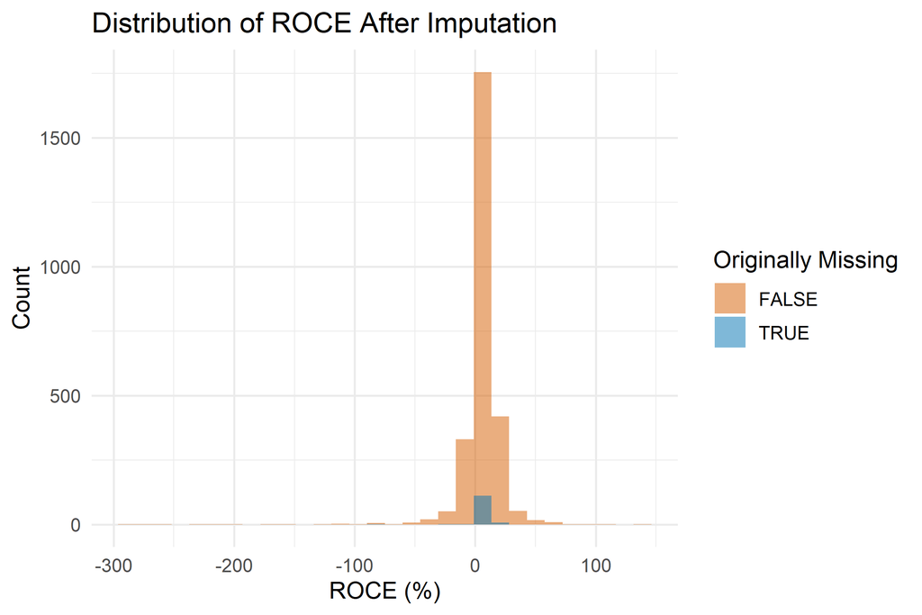

```r
# Compare original vs imputed distributions
osiris_impute %>%
  ggplot(aes(x = ROCE_Imputed, fill = is.na(ROCE))) +
  geom_histogram(position = "identity", alpha = 0.5, bins = 30) +
  labs(
    title = "Distribution of ROCE After Imputation",
    x = "ROCE (%)",
    y = "Count",
    fill = "Originally Missing"
  ) +
  theme_minimal()
```

The imputation introduced only minimal changes, with the post-imputation distribution of ROCE closely aligning with the original data. Imputed values fall within the same plausible range as observed observations, indicating that the procedure preserved the overall structure of the variable. The imputed ROCE values are therefore retained for further analysis.

**EBIT Margin (Earnings Before Interest and Tax Margin) Imputed**

```r
osiris_impute <- osiris_impute |>
  mutate(.year = `Financial Year`,
         # global median
         .global_med_tr = median(`EBIT Margin`, na.rm = TRUE)) |>
  # categorise by industry x financial year
  group_by(`NAICS Core Code`, .year) |>
  mutate(.ind_med_tr = median(`EBIT Margin`, na.rm = TRUE)) |>
  ungroup() |>
  mutate(
    `EBIT_Margin_Imputed` = case_when(
      # replace NA with industry median
      is.na(`EBIT Margin`) & !is.na(.ind_med_tr) ~ .ind_med_tr,
      # if no industry using global median
      is.na(`EBIT Margin`) & is.na(.ind_med_tr) ~ .global_med_tr,
      # otherwise remain
      TRUE ~ `EBIT Margin`
    )
  ) |>
  select(-.ind_med_tr, -.global_med_tr, -.year)
```

Compare the distribution of `EBIT Margin` before and after imputation to assess whether the filled values maintain a reasonable scale and effectively reduce missing observations without distorting the underlying distribution.

The summary indicates that most missing values were successfully imputed, with the overall pattern remaining consistent with the original data.

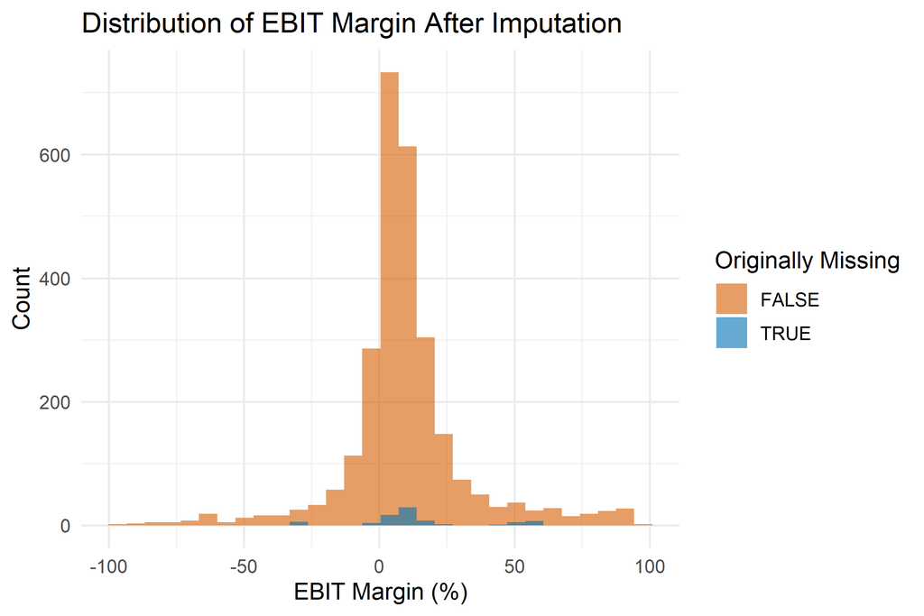

```r
# Compare original vs imputed distributions
osiris_impute |>
ggplot(aes(x = EBIT_Margin_Imputed, fill = is.na(`EBIT Margin`))) +
geom_histogram(position = "identity", alpha = 0.6, bins = 30) +
labs(
title = "Distribution of EBIT Margin After Imputation",
x = "EBIT Margin (%)",
y = "Count",
fill = "Originally Missing"
) +
theme_minimal()
```

The imputation introduced only minor adjustments, and the overall distribution of EBIT Margin remained closely aligned with the original data.

Therefore, the imputed EBIT Margin values are retained for subsequent analysis.

##### Recalculation

After comparing the underlying variables with the missing value table, ratios with missing observations but complete underlying variables were identified. For these cases, the ratios were recalculated to replace missing values and ensure internal consistency across the dataset.

**Recalculating Ratio for variables with zero-NA:** Creating new variables called `Recal ROA`, `Recal Solvency ratio` and `Recal Current Ratio`.

**ROA (Return on Assets) Recalculation**

```r
# Recalculate
osiris_impute <- osiris_impute |>
  mutate(`Recal ROA` = 100 * (`Net Profit` / `Total Assets`))
```

Compare the distribution of `ROA` before and after recalculation to verify that the recomputed values maintain a realistic scale while accurately reflecting profitability based on `Net Profit` and `Total Assets`.

This check helps confirm whether recalculation introduces any systematic distortion or unexpected outliers.

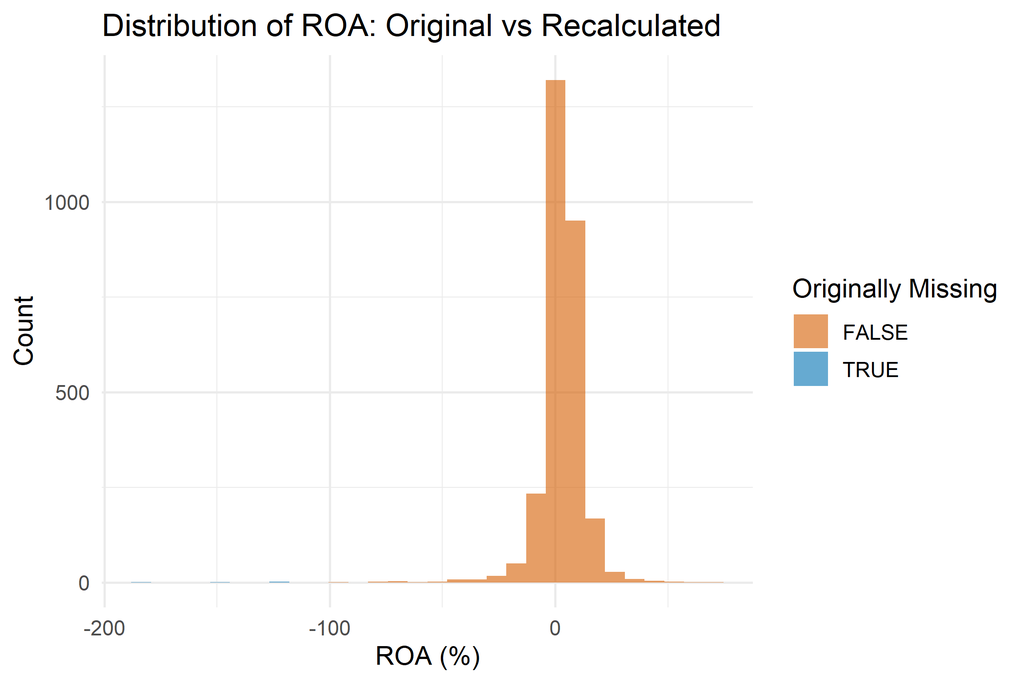

```r
# Compare yearly before and after
osiris_impute |>
ggplot(aes(x = `Recal ROA`, fill = is.na(`ROA`))) +
geom_histogram(position = "identity", alpha = 0.6, bins = 30) +
labs(
title = "Distribution of ROA: Original vs Recalculated",
x = "ROA (%)",
y = "Count",
fill = "Originally Missing"
) +
theme_minimal()
```

The overall distribution of recalculated ROA remains consistent with the original data, with a small number of additional negative observations visible in the left tail.

These reflect firms reporting losses relative to their asset base rather than data or calculation errors. Therefore, the **recalculated ROA** is used in the main exploratory analysis.

**Solvency ratio Recalculation**

```r
# Recalculate
osiris_impute <- osiris_impute |>
  mutate(`Recal Solvency ratio` = 100 * (`Total Shareholders Equity` / `Total Assets`))
```

Compare the distribution of `Solvency Ratio` before and after recalculation to ensure that the recomputed values remain within a realistic scale and correctly reflect firms’ capital structures based on `Total Shareholders’ Equity` and `Total Assets`.

This check verifies that the recalculation does not introduce distortion or unrealistic outliers in the data.

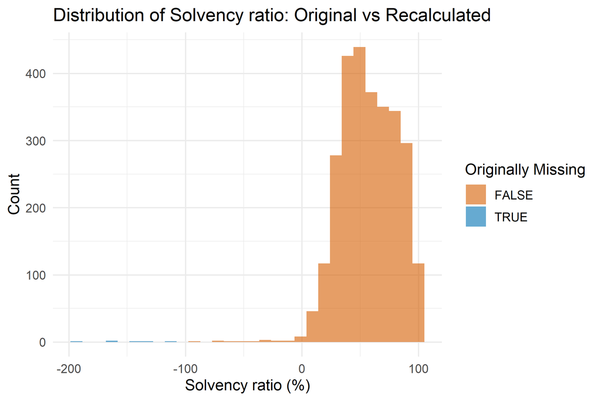

```r
# Compare yearly before and after
osiris_impute |>
  ggplot(aes(x = `Recal Solvency ratio`, fill = is.na(`Solvency ratio`))) +
  geom_histogram(position = "identity", alpha = 0.6, bins = 30) +
  labs(
    title = "Distribution of Solvency ratio: Original vs Recalculated",
    x = "Solvency ratio (%)",
    y = "Count",
    fill = "Originally Missing"
  ) +
  theme_minimal()
```

The recalculated Solvency Ratio closely matches the original distribution, with a small number of additional negative observations appearing in the left tail.

These correspond to firms with negative equity—indicating financial distress rather than calculation issues. Therefore, the **recalculated Solvency Ratio** is used in the main exploratory analysis.

**Current Ratio**

```r
# Recalculate
osiris_impute <- osiris_impute |>
  mutate(`Recal Current ratio` = `Total Current Assets` / `Total Current Liabilities`)
```

Compare the distribution of `Current Ratio` before and after recalculation to verify that the recomputed values accurately reflect firms’ short-term liquidity positions based on `Total Current Assets` and `Total Current Liabilities`.

This check ensures that the recalculation preserves the original distribution and does not introduce unrealistic or distorted values.

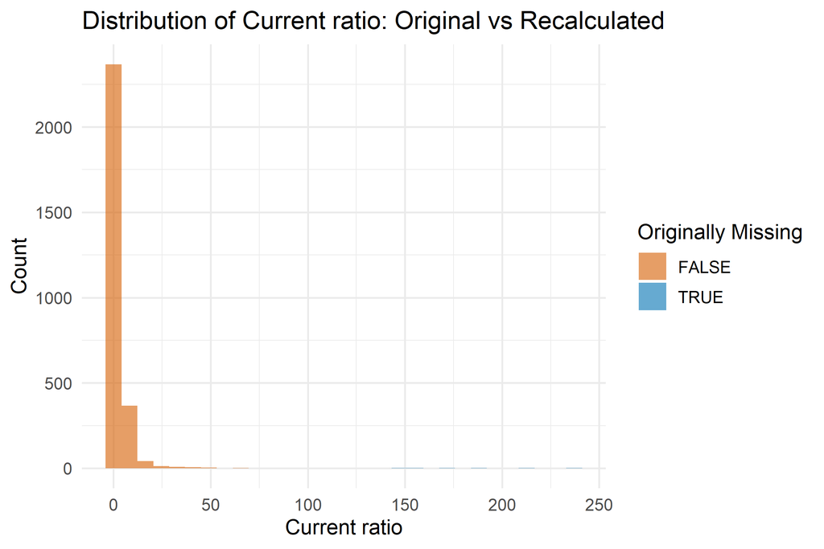

```r
# Compare yearly before and after
osiris_impute |>
  ggplot(aes(x = `Recal Current ratio`, fill = is.na(`Current ratio`))) +
  geom_histogram(position = "identity", alpha = 0.6, bins = 30) +
  labs( title = "Distribution of Current ratio: Original vs Recalculated",
        x = "Current ratio",
        y = "Count",
        fill = "Originally Missing"
        ) +
  theme_minimal()
```

The recalculated Current Ratio shows an almost identical distribution to the original, confirming that the recomputation using total current assets and liabilities preserves the underlying scale and variation.

### Final Variable List for EDA

The variables retained in osiris_tidy were selected based on both data quality and analytical relevance identified during the Initial Data Assessment (IDA).

Only variables with consistent reporting across 2018–2021 and minimal missingness were kept, while redundant identifiers, static fields, and poorly populated measures were excluded.

The retained variables collectively address the study’s central question — how the COVID-19 pandemic reshaped firm performance in Thailand — by covering four key analytical dimensions:

Profitability and performance — `net_sales`, `earnings_before_interest_tax`, `net_profit`, `roce_imputed`, `ebit_margin_imputed`, and `recal_roa` capture earnings capacity and operational efficiency.

Capital structure and solvency — `total_assets`, `total_shareholders_equity`, `non_current_liabilities`, `bank_loans`, and `recal_solvency_ratio assess` leverage and long-term financial stability.

Liquidity and short-term resilience — `total_current_assets`, `total_current_liabilities`, and `recal_current_ratio` measure the firm’s ability to meet short-term obligations.

Together, these variables form a tidy, analysis-ready dataset that preserves the core financial relationships necessary for exploring profitability, liquidity, and solvency trends before and during the pandemic.

```r
osiris_tidy <- osiris_impute %>%
  clean_names()

osiris_tidy <- osiris_tidy %>%
  select(c(financial_year,
           company_name,
           naics_core_code,
           industry_category,
           total_current_assets,
           total_assets,
           total_current_liabilities,
           non_current_liabilities,
           bank_loans,
           total_shareholders_equity,
           net_sales,
           earnings_before_interest_tax,
           net_profit,
           interest_expense_imputed,
           total_revenues_imputed,
           roce_imputed,
           ebit_margin_imputed,
           recal_roa,
           recal_solvency_ratio,
           recal_current_ratio))
```

## EDA

### Profitability

#### How did ROA and ROCE change through the pandemic?

**Interpretation**

ROA tells you how well a company turns what it owns, such as its buildings, machines, software, and cash into profits. **A higher ROA is better** because it means the business squeezes more earnings out of each dollar of resources, showing efficient use of assets.

ROCE shows how effectively a company uses long-term money. It looks at how well the company uses funds from owners and long-term lenders to earn returns. **A higher ROCE is better** because it indicates the company is earning more from the capital tied up in the business.

**Normality check for ROA and ROCE**

Figure 2 shows normal Q-Q plots for ROA (left) and ROCE (right).

In the ROA panel, points deviate from the reference line at both ends: the left tail dips below the line, indicating more very low/negative ROA values than a normal distribution would predict, while the right tail rises above the line, indicating some unusually high ROA observations.

Overall, both variables are non-normal with asymmetric, heavy tails, and ROCE exhibits a particularly heavy left tail.

The QQ plots show that most observations hug the reference line, and the non-normality comes from a small fraction in the tails (especially the left tail for ROCE). With a large sample, these extremes are diluted, so we **use the mean to read the overall pattern**. We reserve **medians for industry** cuts, where small sample sizes and uneven tails can skew the mean.

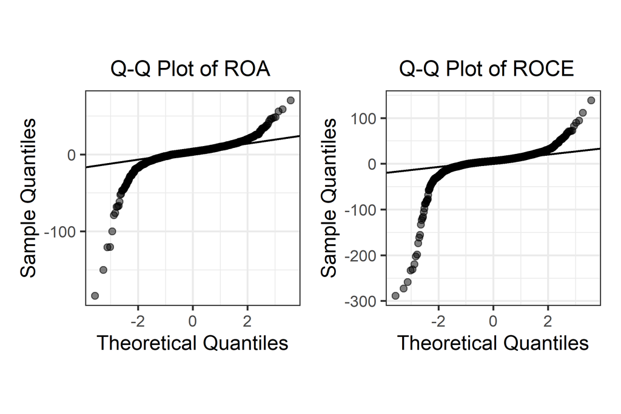

Figure 2: Normal Q-Q plots for ROA (left) and ROCE (right). Points = sample quantiles; line = normal reference. Reference: Lecture 5 - Quantitative variables

```r
roa_qq <- ggplot(osiris_tidy, aes(sample = recal_roa)) +
  stat_qq(alpha = 0.5) +
  stat_qq_line() +
  labs(title = "Q-Q Plot of ROA", x = "Theoretical Quantiles", y = "Sample Quantiles") +
  theme(plot.title = element_text(size = 15, hjust = 0.75))

roce_qq <- ggplot(osiris_tidy, aes(sample = roce_imputed)) +
  stat_qq(alpha = 0.5) +
  stat_qq_line() +
  labs(title = "Q-Q Plot of ROCE", x = "Theoretical Quantiles", y = "Sample Quantiles") +
  theme(plot.title = element_text(size = 15, hjust = 0.75))

roa_qq | roce_qq
```

**ROA & ROCE trend and dispersion (2018-2021)**

Figure 3 shows broadly stable profitability for both ratios. Red dots mark yearly means and the red GAM curve (REML) shows a slight upward drift. **ROA tightens toward low single digits by 2021; ROCE’s center also tightens even as tails remain active**.

For ROA, the 2018 cloud is more dispersed with several extreme negative observations, whereas by 2021 the points are more tightly clustered around low single-digit values, indicating reduced spread.

For ROCE, the central mass also becomes tighter over time, but the tails extend slightly further, a few observations move to more extreme negative values despite the middle concentrating.

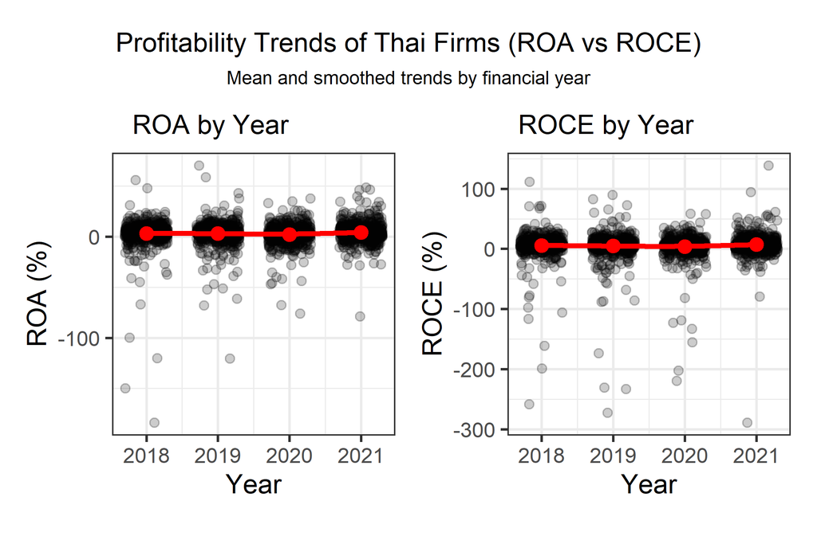

Figure 3: Firm-level ROA (left) and ROCE (right) by year, 2018-2021. Jittered points show individual companies; red dots mark annual means; red curve = smoothing spline (GAM, REML). Plot style adapted from Tutorial 7’s example and Week 11 p. 19.

```r
# ROA
roa_jitter <- ggplot(osiris_tidy, aes(x = financial_year, y = recal_roa)) +
  geom_jitter(width = 0.3, alpha = 0.2) +
  stat_summary(fun = mean, geom = "point", colour = "red", size = 3) +
  geom_smooth(method = mgcv::gam, formula = y ~ s(x, k = 4), colour = "red", se = FALSE) +
  labs(title = "ROA by Year", x = "Year", y = "ROA (%)") +
  theme(plot.title = element_text(size = 12, hjust = 0.5))

# ROCE
roce_jitter <- ggplot(osiris_tidy, aes(x = financial_year, y = roce_imputed)) +
  geom_jitter(width = 0.3, alpha = 0.2) +
  stat_summary(fun = mean, geom = "point", colour = "red", size = 3) +
  geom_smooth(method = mgcv::gam, formula = y ~ s(x, k = 4), colour = "red", se = FALSE) +
  labs(title = "ROCE by Year", x = "Year", y = "ROCE (%)") +
  theme(plot.title = element_text(size = 12, hjust = 0.5))

# Combine
(roa_jitter | roce_jitter) +
  plot_annotation(
    title = "Profitability Trends of Thai Firms (ROA vs ROCE)",
    subtitle = "Mean and smoothed trends by financial year"
  ) &
  theme(
    plot.title = element_text(size = 14, hjust = 0.5),
    plot.subtitle = element_text(size = 10, hjust = 0.5)
  )
```

Figure 4 zooms to the interquartile band: **ROA is flat to slightly up in 2019, dips in 2020, then reaches a four-year high in 2021**; **ROCE steps down from 2018 to 2020, then rebounds in 2021**. The gentle rise mainly reflects the 2021 recovery.

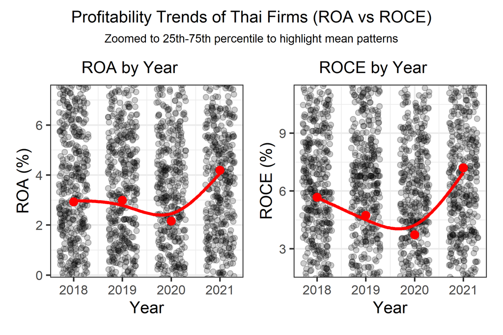

Figure 4: Firm-level ROA (left) and ROCE (right), 2018-2021. Jittered points = firms; red dots = annual means; red curve = smoothing spline (GAM, REML). Panels are zoomed to the interquartile range (25th-75th). Plot style adapted from Tutorial 7’s example and Week 11 p. 19.

```r
# Compute IQR bounds for ROA and ROCE
roa_limits <- quantile(osiris_tidy$recal_roa, probs = c(0.25, 0.75))
roce_limits <- quantile(osiris_tidy$roce_imputed, probs = c(0.25, 0.75))

# ROA plot
roa_jitter <- ggplot(osiris_tidy, aes(x = financial_year, y = recal_roa)) +
  geom_jitter(width = 0.3, alpha = 0.2) +
  stat_summary(fun = mean, geom = "point", colour = "red", size = 3) +
  geom_smooth(method = mgcv::gam, formula = y ~ s(x, k = 4), colour = "red", se = FALSE) +
  labs(title = "ROA by Year", x = "Year", y = "ROA (%)") +
  coord_cartesian(ylim = roa_limits) +
  theme(plot.title = element_text(size = 12, hjust = 0.5))

# ROCE plot
roce_jitter <- ggplot(osiris_tidy, aes(x = financial_year, y = roce_imputed)) +
  geom_jitter(width = 0.3, alpha = 0.2) +
  stat_summary(fun = mean, geom = "point", colour = "red", size = 3) +
  geom_smooth(method = mgcv::gam, formula = y ~ s(x, k = 4), colour = "red", se = FALSE) +
  labs(title = "ROCE by Year", x = "Year", y = "ROCE (%)") +
  coord_cartesian(ylim = roce_limits) +
  theme(plot.title = element_text(size = 12, hjust = 0.5))

# Combine
(roa_jitter | roce_jitter) +
  plot_annotation(
    title = "Profitability Trends of Thai Firms (ROA vs ROCE)",
    subtitle = "Zoomed to 25th-75th percentile to highlight mean patterns"
  ) &
  theme(
    plot.title = element_text(size = 14, hjust = 0.5),
    plot.subtitle = element_text(size = 10, hjust = 0.5)
  )
```

Table 13 shows wide interquartile ranges for both ROA and ROCE in every year, indicating substantial cross-firm heterogeneity.

ROA and ROCE is broadly steady in 2018-2019, then falls across the distribution in 2020, the ROA lower quartile even slips below zero before a sharp rebound in 2021 with central values returning to (and in places exceeding) pre-pandemic levels.

Means track the same pattern; **they sit close to or below medians in 2018-2020 (consistent with left-skew from weak performers) but rise above medians in 2021**, hinting at a stronger right tail driven by a subset of high performers.

```r
# Summarise ROA/ROCE by financial year
roa_roce_stats_tbl <- osiris_tidy %>%
  transmute(
    financial_year = financial_year,
    ROA = recal_roa,
    ROCE = roce_imputed
  ) %>%
  pivot_longer(c(ROA, ROCE), names_to = "metric", values_to = "value") %>%
  group_by(financial_year, metric) %>%
  summarise(
    mean = mean(value),
    median = median(value),
    q25 = quantile(value, 0.25),
    q75 = quantile(value, 0.75),
    .groups = "drop"
  ) %>%
  mutate(
    display = sprintf(
      "%.2f<br/>(%.2f ~ %.2f)<br/>median %.2f",
      mean, q25, q75, median
    )
  ) %>%
  select(financial_year, metric, display) %>%
  pivot_wider(names_from = metric, values_from = display) %>%
  arrange(financial_year) %>%
  rename(`Financial Year` = financial_year)

# Table
kable(
  roa_roce_stats_tbl,
  format = "html",
  escape = FALSE,
  align = c("c","c","c"),
  caption = "ROA and ROCE by year: mean, interquartile range, and median (values in %)."
) %>%
  kable_styling(full_width = FALSE, bootstrap_options = c("striped", "hover")) %>%
  row_spec(
    which(roa_roce_stats_tbl$`Financial Year` == 2020),
    background = "#ffe6e6",
    bold = TRUE
  )
```

Table 13: ROA and ROCE by year (2018-2021): mean, interquartile range (q25-q75), and median. Values are percentages; negative ratios reflect loss-making years; figures are scaled ×100 per the user guide. Reference: Lecture 5, p. 13.

ROA and ROCE by year: mean, interquartile range, and median (values in %).

| Financial Year | ROA | ROCE |
| --- | --- | --- |
| 2018 | 2.93 (0.65 ~ 7.52) median 3.82 | 5.68 (2.80 ~ 11.39) median 6.53 |
| 2019 | 2.98 (0.45 ~ 7.30) median 3.50 | 4.74 (1.84 ~ 11.22) median 6.69 |
| 2020 | 2.16 (-1.01 ~ 6.30) median 2.91 | 3.73 (0.58 ~ 9.80) median 5.23 |
| 2021 | 4.19 (0.59 ~ 7.66) median 3.90 | 7.20 (2.38 ~ 11.69) median 6.71 |

**ROA components in levels (net profit vs total assets)**

Figure 5 plots firm-level net profit vs total assets (2018-2021), the numerator and denominator of ROA with a grey dashed OLS fit in each panel. Left: raw scale with outliers highlighted in red; Right: asinh-transformed axes to compress heavy tails.

The left panel shows all firms on the raw scale; red points mark within-year outliers (outside the 1st-99th percentiles on either axis). Most firms cluster at modest asset sizes with profits near zero, so non-outliers sit on the left; a heavy right tail generates many flags. Five standouts remain: **four are PTT PCL across different years (scale-driven; ROA not abnormal) and one is THAI AIRWAYS INTERNATIONAL PCL in 2020, whose position indicates a very large negative net profit**.

The right panel applies asinh-transformed axes to the same data, which compresses extremes and reveals the dense core near the origin. The fitted slope correspondingly flattens, and the dispersion forms a clear V-shaped fan tight near zero but widening with asset size on both sides of zero, evidence of heteroscedasticity driven by firm scale.

```r
# data prep with per-year outlier flags & tooltips
np_assets <- osiris_tidy %>%
  transmute(
    year = financial_year,
    company = company_name,
    ROA = round(recal_roa, 2),
    net_profit_bn = net_profit / 1e6,
    assets_bn = total_assets / 1e6
  ) %>%
  group_by(year) %>%
  mutate(
    # Per-year 1st/99th percentiles as outlier cutoffs
    x_lo = quantile(assets_bn, 0.01),
    x_hi = quantile(assets_bn, 0.99),
    y_lo = quantile(net_profit_bn, 0.01),
    y_hi = quantile(net_profit_bn, 0.99),
    outlier = assets_bn < x_lo | assets_bn > x_hi |
              net_profit_bn < y_lo | net_profit_bn > y_hi
  ) %>%
  ungroup() %>%
  mutate(
    tooltip = paste0(
      "Company: ", company,
      "<br>Year: ", year,
      "<br>ROA: ", sprintf("%.2f", ROA),
      "<br>Total assets (THB bn): ", number(assets_bn, accuracy = 0.1),
      "<br>Net profit (THB bn): ", number(net_profit_bn, accuracy = 0.1)
    )
  )

# Scatter (raw axes) with outliers highlighted; dashed line = global OLS fit
np_assets_with <- ggplot(np_assets, aes(assets_bn, net_profit_bn, text = tooltip)) +
  geom_point(aes(color = year), alpha = 0.35, size = 1) +
  geom_point(
    data = subset(np_assets, outlier),
    aes(assets_bn, net_profit_bn, text = tooltip),
    color = "red", alpha = 0.85, size = 1.2
  ) +
  geom_smooth(
    data = np_assets, aes(assets_bn, net_profit_bn, group = 1),
    method = "lm", se = FALSE, color = "darkgrey", linewidth = 0.6, linetype = "dashed",
    inherit.aes = FALSE
  ) +
  scale_x_continuous("Total assets (THB bn)", labels = label_number(accuracy = 0.1)) +
  scale_y_continuous("Net profit (THB bn)",  labels = label_number(accuracy = 0.1)) +
  theme_minimal()

# Scatter with asinh axes (log-like compression; keeps zeros/negatives)
np_assets_asinh <- ggplot(np_assets, aes(assets_bn, net_profit_bn, text = tooltip)) +
  geom_point(aes(color = year), alpha = 0.5, size = 1) +
  geom_smooth(
    data = np_assets, aes(assets_bn, net_profit_bn, group = 1),
    method = "lm", se = FALSE, color = "darkgrey", linewidth = 0.6, linetype = "dashed",
    inherit.aes = FALSE
  ) +
  scale_x_continuous("Total assets (THB bn)",
                      labels = label_number(accuracy = 0.1),
                      trans = trans_new("asinh", transform = asinh, inverse = sinh)
) +
  scale_y_continuous("Net profit (THB bn)",
                      labels = label_number(accuracy = 0.1),
                      trans = trans_new("asinh",transform = asinh, inverse = sinh)
) +
  theme_minimal()

# Make interactive and arrange side-by-side
g1 <- ggplotly(np_assets_with, tooltip = "text")
g2 <- ggplotly(np_assets_asinh, tooltip = "text") %>%
  plotly::layout(showlegend = FALSE)

subplot(g1, g2, nrows = 1, shareX = FALSE, shareY = FALSE, titleX = TRUE, titleY = TRUE, margin = 0.06) %>%
  plotly::layout(
    title = list(
      text = paste0("Net profit vs Total assets (2018-2021)",
                    "<br><sup>Grey dashed line = OLS fit</sup>"),
      x = 0.5, xanchor = "center"
    ),
    annotations = list(
      list(text = "With outliers", x = 0.235, xref = "paper",
           y = 1.06, yref = "paper", showarrow = FALSE, xanchor = "center", yanchor = "bottom"),
      list(text = "Asinh axes", x = 0.765, xref = "paper",
           y = 1.06, yref = "paper", showarrow = FALSE, xanchor = "center", yanchor = "bottom")
    ),
    margin = list(t = 90)
  )
```

[interactive chart not shown]

Figure 5: Net profit vs total assets (THB bn), 2018-2021. Left: raw scale with outliers highlighted (red). Right: asinh-transformed axes. Grey dashed line = OLS fit. Reference: Lecture 5 - Transformations and Lecture 6 - Scatterplot.

Figure 6 breaks the ROA components into four yearly cross-sections (2018-2021). Each dot is a firm, red dots are annual means, and the red LOESS curve traces the cross-year trend; y-axes use an asinh transform to compress heavy tails.

Net profit (numerator): wide dispersion, a slight 2020 trough, and a rebound in 2021; spread widens in 2020.

Total assets (denominator): rises steadily from 2018 to 2021 with no pandemic dip. The asinh scaling emphasizes the central mass, so the smoother summarizes the typical firm rather than being pulled by very large firms.

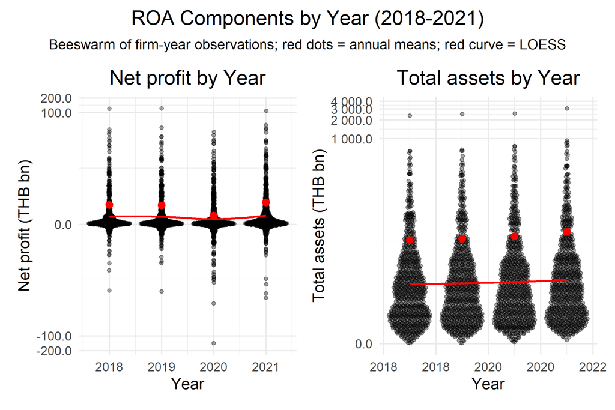

Figure 6: Firm-level net profit (left) and total assets (right), 2018-2021. Beeswarm points by year; red dots = annual means; red curve = LOESS smoother. Y-axes use an asinh transform. Reference: Lecture 5 - Transformations.

```r
# Keep year and scale amounts to THB billions
levels_by_year <- osiris_tidy %>%
  transmute(
    year = financial_year,
    net_profit_bn = net_profit / 1e6,
    assets_bn = total_assets / 1e6
  )

# Per-year average net profit
netprofit_yearly_mean <- levels_by_year %>%
  group_by(year) %>%
  summarise(mean_np = mean(net_profit_bn), .groups = "drop")

# Per-year average total assets
assets_yearly_mean <- levels_by_year %>%
  group_by(year) %>%
  summarise(mean_assets = mean(assets_bn), .groups = "drop")

# Net profit: quasirandom cloud + LOESS trend + yearly mean
# asinh axis compresses extremes but keeps zeros/negatives; geom_quasirandom from ggbeeswarm
plot_net_profit_by_year <- ggplot(levels_by_year, aes(x = year, y = net_profit_bn)) +
  geom_quasirandom(alpha = 0.35, size = 1) +
  geom_smooth(aes(x = year, y = net_profit_bn, group = 1),
              method = "loess", span = 0.8, colour = "red", linewidth = 0.7, se = FALSE) +
  geom_point(data = netprofit_yearly_mean,
             aes(x = year, y = mean_np),
             colour = "red", size = 2) +
  scale_y_continuous("Net profit (THB bn)",
                     labels = label_number(accuracy = 0.1),
                     trans  = trans_new("asinh", transform = asinh, inverse = sinh)) +
  labs(title = "Net profit by Year", x = "Year") +
  theme_minimal() +
  theme(plot.title = element_text(size = 12, hjust = 0.5))

# Total assets: quasirandom cloud + LOESS trend + yearly mean
plot_total_assets_by_year <- ggplot(levels_by_year, aes(x = year, y = assets_bn)) +
  geom_quasirandom(alpha = 0.35, size = 1) +
  geom_smooth(aes(x = year, y = assets_bn, group = 1),
              method = "loess", span = 0.8, colour = "red", linewidth = 0.7, se = FALSE) +
  geom_point(data = assets_yearly_mean,
             aes(x = year, y = mean_assets),
             colour = "red", size = 2) +
  scale_y_continuous("Total assets (THB bn)",
                     labels = label_number(accuracy = 0.1),
                     trans  = trans_new("asinh", transform = asinh, inverse = sinh)) +
  labs(title = "Total assets by Year", x = "Year") +
  theme_minimal() +
  theme(plot.title = element_text(size = 12, hjust = 0.5))

# combine
(plot_net_profit_by_year | plot_total_assets_by_year) +
  plot_annotation(
    title = "ROA Components by Year (2018-2021)",
    subtitle = "Beeswarm of firm-year observations; red dots = annual means; red curve = LOESS"
  ) &
  theme(
    plot.title = element_text(hjust = 0.5, size = 14),
    plot.subtitle = element_text(hjust = 0.5, size = 10)
  )
```

**ROCE components in levels (numerator vs capital employed)**

Figure 7 plots the ROCE components in levels: the numerator is **Net profit − Interest expenses**, and capital employed is **Total shareholders’ equity + Non-current liabilities**. The left panel shows the raw scale with outliers highlighted; the right panel applies asinh axes to compress heavy tails.

The overall pattern mirrors the ROA components view that a dense core near zero at modest capital employed, a pronounced right tail as firm size grows, and a V-shaped spread (wider dispersion at larger scale).

The most extreme points are again **PTT PCL (size-driven, not implying abnormal returns) and THAI AIRWAYS INTERNATIONAL PCL (2020), whose numerator is strongly negative**.

In a few distressed firms, capital employed can be close to or below zero (e.g., negative equity), which appears near the origin on the asinh plot but doesn’t alter the aggregate pattern. The asinh view confirms the same structure while making the interior cloud easier to read and flattening the fitted slope.

```r
# data prep with per-year outlier flags & tooltips
roce_levels <- osiris_tidy %>%
  transmute(
    year = financial_year,
    company = company_name,
    net_profit_bn = net_profit / 1e6,
    interest_bn = interest_expense_imputed / 1e6,
    equity_bn = total_shareholders_equity / 1e6,
    noncurrent_bn = non_current_liabilities / 1e6
  ) %>%
  mutate(
    roce_num_bn = net_profit_bn - interest_bn,
    capital_bn  = equity_bn + noncurrent_bn,
    ROCE_pct = round(100 * roce_num_bn / capital_bn, 2)
  ) %>%
  group_by(year) %>%
  mutate(
    # Per-year 1st/99th percentiles as outlier cutoffs
    x_lo = quantile(capital_bn, 0.01),
    x_hi = quantile(capital_bn, 0.99),
    y_lo = quantile(roce_num_bn, 0.01),
    y_hi = quantile(roce_num_bn, 0.99),
    outlier = capital_bn < x_lo | capital_bn > x_hi |
              roce_num_bn < y_lo | roce_num_bn > y_hi
  ) %>%
  ungroup() %>%
  mutate(
    tooltip = paste0(
      "Company: ", company,
      "<br>Year: ", year,
      "<br>ROCE (%): ", ROCE_pct,
      "<br>Numerator (NP − Interest): ", number(roce_num_bn, accuracy = 0.1), " THB bn",
      "<br>Capital employed (Equity + NCL): ", number(capital_bn, accuracy = 0.1), " THB bn"
    )
  )

# Scatter (raw axes) with outliers highlighted; dashed line = global OLS fit
p_roce_raw <- ggplot(roce_levels, aes(capital_bn, roce_num_bn, text = tooltip)) +
  geom_point(aes(color = year), alpha = 0.35, size = 1) +
  geom_point(
    data = subset(roce_levels, outlier),
    aes(capital_bn, roce_num_bn, text = tooltip),
    color = "red", alpha = 0.85, size = 1.2
  ) +
  geom_smooth(
    aes(group = 1), method = "lm", se = FALSE,
    color = "darkgrey", linewidth = 0.6, linetype = "dashed"
  ) +
  scale_x_continuous("Capital employed (THB bn)", labels = label_number(accuracy = 0.1)) +
  scale_y_continuous("Numerator: Net profit − Interest (THB bn)", labels = label_number(accuracy = 0.1)) +
  theme_minimal()

# Scatter with asinh axes (log-like compression; keeps zeros/negatives)
p_roce_asinh <- ggplot(roce_levels, aes(capital_bn, roce_num_bn, text = tooltip)) +
  geom_point(aes(color = year), alpha = 0.5, size = 1) +
  geom_smooth(
    aes(group = 1), method = "lm", se = FALSE,
    color = "darkgrey", linewidth = 0.6, linetype = "dashed"
  ) +
  scale_x_continuous(
    "Capital employed (THB bn)",
    labels = label_number(accuracy = 0.1),
    trans  = trans_new("asinh", transform = asinh, inverse = sinh)
  ) +
  scale_y_continuous(
    "Numerator: Net profit − Interest (THB bn)",
    labels = label_number(accuracy = 0.1),
    trans  = trans_new("asinh", transform = asinh, inverse = sinh)
  ) +
  theme_minimal()

# Make interactive and arrange side-by-side
g_roce_raw   <- ggplotly(p_roce_raw,   tooltip = "text")
g_roce_asinh <- ggplotly(p_roce_asinh, tooltip = "text") %>%
  plotly::layout(showlegend = FALSE)

subplot(g_roce_raw, g_roce_asinh,
                nrows = 1, shareX = FALSE, shareY = FALSE,
                titleX = TRUE, titleY = TRUE, margin = 0.06) %>%
  plotly::layout(
    title = list(
      text = paste0("ROCE components: Numerator vs Capital employed (2018-2021)",
                    "<br><sup>Grey dashed line = OLS fit</sup>"),
      x = 0.5, xanchor = "center"
    ),
    annotations = list(
      list(text = "With outliers", x = 0.235, xref = "paper",
           y = 1.06, yref = "paper", showarrow = FALSE,
           xanchor = "center", yanchor = "bottom"),
      list(text = "Asinh axes", x = 0.765, xref = "paper",
           y = 1.06, yref = "paper", showarrow = FALSE,
           xanchor = "center", yanchor = "bottom")
    ),
    margin = list(t = 90)
  )
```

[interactive chart not shown]

Figure 7: ROCE components in levels (THB bn), 2018-2021. Left: raw scale with outliers highlighted (red). Right: asinh-transformed axes. Grey dashed line = OLS fit. Formula per user guide: ROCE = (Net profit − Interest expenses)/(Equity + Non-current liabilities) × 100. Reference: Lecture 5 - Transformations and Lecture 6 - Scatterplot.

Figure 8 breaks the ROCE components into four yearly cross-sections (2018-2021): each dot is a firm, red dots are annual means, and the red LOESS curve traces the cross-year trend (asinh y-axes to tame heavy tails).

Numerator (Net profit − Interest): mirrors net profit with wide dispersion, a slight dip in 2020, and a rebound in 2021.

Capital employed (Equity + Non-current liabilities): rises steadily from 2018 to 2021 with no pandemic dip. The asinh scaling emphasizes the central mass, so the smoother summarizes the typical firm rather than tail values.

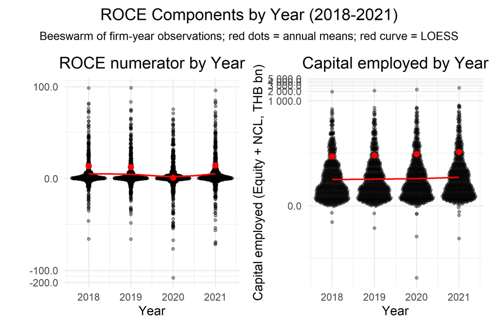

Figure 8: ROCE components by year (2018-2021): Beeswarm points by year; red dots = annual means; red curve = LOESS smoother. Y-axes asinh-transformed. Formula per user guide. Reference: Lecture 5 - Transformations.

```r
# Keep year and scale amounts to THB billions
roce_by_year <- osiris_tidy %>%
  transmute(
    year = financial_year,
    roce_num_bn  = (net_profit - interest_expense_imputed) / 1e6,           # Numerator
    capital_bn = (total_shareholders_equity + non_current_liabilities) / 1e6  # Capital employed
  )

# Per-year averages for red mean dots
roce_year_means <- roce_by_year %>%
  group_by(year) %>%
  summarise(
    mean_num = mean(roce_num_bn),
    mean_cap = mean(capital_bn),
    .groups = "drop"
  )

# Numerator: quasirandom cloud + LOESS trend + yearly mean
# asinh axis compresses extremes but keeps zeros/negatives; geom_quasirandom from ggbeeswarm
plot_roce_num_by_year <- ggplot(roce_by_year, aes(x = year, y = roce_num_bn)) +
  geom_quasirandom(alpha = 0.35, size = 1) +
  geom_smooth(aes(x = year, y = roce_num_bn, group = 1),
              method = "loess", span = 0.8, colour = "red", linewidth = 0.7, se = FALSE) +
  geom_point(data = roce_year_means,
             aes(x = year, y = mean_num),
             colour = "red", size = 2) +
  scale_y_continuous("Net profit − Interest (THB bn)",
                     labels = label_number(accuracy = 0.1),
                     trans  = trans_new("asinh", transform = asinh, inverse = sinh)) +
  labs(title = "ROCE numerator by Year", x = "Year") +
  theme_minimal() +
  theme(plot.title = element_text(size = 12, hjust = 0.5))

# Capital employed: quasirandom cloud + LOESS trend + yearly mean
plot_capital_by_year <- ggplot(roce_by_year, aes(x = year, y = capital_bn)) +
  geom_quasirandom(alpha = 0.35, size = 1) +
  geom_smooth(aes(x = year, y = capital_bn, group = 1),
              method = "loess", span = 0.8, colour = "red", linewidth = 0.7, se = FALSE) +
  geom_point(data = roce_year_means,
             aes(x = year, y = mean_cap),
             colour = "red", size = 2) +
  scale_y_continuous("Capital employed (Equity + NCL, THB bn)",
                     labels = label_number(accuracy = 0.1),
                     trans  = trans_new("asinh", transform = asinh, inverse = sinh)) +
  labs(title = "Capital employed by Year", x = "Year") +
  theme_minimal() +
  theme(plot.title = element_text(size = 12, hjust = 0.5))

# combine
(plot_roce_num_by_year | plot_capital_by_year) +
  plot_annotation(
    title = "ROCE Components by Year (2018-2021)",
    subtitle = "Beeswarm of firm-year observations; red dots = annual means; red curve = LOESS"
  ) &
  theme(
    plot.title = element_text(hjust = 0.5, size = 14),
    plot.subtitle = element_text(hjust = 0.5, size = 10)
  )
```

Across 2018-2021, both ROA and ROCE are not normal and have heavy tails. The plots tell a consistent story that **stable in 2018-2019, a slight dip in 2020, and a rebound in 2021**. In 2021 the means are often above the medians, which hints at a stronger right tail from high performers. Breaking the ratios into levels helps explain why the ratios do not move a lot: net profit (and the ROCE numerator, net profit minus interest) follows a drop in 2020 and a rise in 2021, while total assets and capital employed keep rising across all four years, so the growing denominator holds the ratios down. Dispersion gets wider in 2020, especially on the downside, then tightens a bit in 2021. The asinh views also show that a few very large firms drive much of the tail behavior.

Since these overall patterns can hide differences across firms, the next section looks at industry-level impacts to see which industries drove the 2020 trough and the 2021 recovery.

#### ROA and ROCE across industries during the pandemic

**Overall industry patterns: ROA & ROCE (2018-2021)**

Figure 9 shows ROA distributions by industry (2018-2021), with red dots marking medians (used because heavy outliers would distort means). Across industries, medians cluster close to zero, indicating broadly similar central performance and only modest differences in typical profitability.

In the ranking, *Mgmt. of Companies & Enterprises* and *Educational Services* appear first and second but each is based on a single company across four years, so these positions should be interpreted cautiously; among industries with broader coverage, *Health Care and Social Assistance* ranks third. Only two industries have medians below zero: *Other Services (except Public Administration)* at the bottom, and *Accommodation and Food Services* as the second lowest.

```r
# Order industries by median ROA (asc)
ind_order <- osiris_tidy %>%
  group_by(industry_category) %>%
  summarise(med_roa = median(recal_roa), .groups = "drop") %>%
  arrange(med_roa) %>%
  pull(industry_category)

# Industry medians (for red dots) and factor levels
med_df <- osiris_tidy %>%
  group_by(industry_category) %>%
  summarise(med_roa = median(recal_roa), .groups = "drop") %>%
  mutate(industry_category = factor(industry_category, levels = ind_order))

# Jitter firm-year ROA (grey); overlay industry median (red)
roa_indus_plot <- osiris_tidy %>%
  mutate(industry_category = factor(industry_category, levels = ind_order)) %>%
  ggplot(aes(x = industry_category, y = recal_roa)) +
  geom_point(
    aes(text = paste0(
      "Company: ", company_name,
      "<br>Year: ", financial_year,
      "<br>Industry: ", industry_category,
      "<br>ROA: ", number(recal_roa, accuracy = 0.01), " %"
    )),
    colour = "grey40",
    position = position_jitter(width = 0.1, height = 0),
    alpha = 0.35, size = 0.9
  ) +
  geom_point(
    data = med_df,
    aes(x = industry_category, y = med_roa),
    colour = "red", size = 1.8
  ) +
  coord_flip() +
  labs(
    title = "ROA distribution by industry (2018-2021)",
    x = "Industry", y = "ROA (%)"
  ) +
  theme_minimal() +
  theme(
    plot.title = element_text(size = 15, hjust = 0.5),
    axis.text.y = element_text(size = 9)
  )

ggplotly(roa_indus_plot, tooltip = "text") %>%
  plotly::layout(title = list(x = 0.9))
```

[interactive chart not shown]

Figure 9: ROA distribution by industry (2018-2021). Each grey dot is a firm-year; red dot = industry median. Industries are ordered by median ROA (highest at the top). Plot style adapted from Lecture 5 p. 20.

Figure 10 shows that while some industry patterns resemble ROA, the cross-industry gaps are so small that the rank order shifts considerably.

Even so, the bottom two remain *Other Services (except Public Administration)* and *Accommodation and Food Services*, which is the only industries with negative medians. At the top, the leading three on ROCE are *Professional, Scientific, Tech. Services*, *Wholesale Trade*, and *Administrative, Support, Waste Mgmt., Remediation Services*.

```r
# Order industries by median ROCE (asc)
ind_order <- osiris_tidy %>%
  group_by(industry_category) %>%
  summarise(med_roce = median(roce_imputed, na.rm = TRUE), .groups = "drop") %>%
  arrange(med_roce) %>%
  pull(industry_category)

# Industry medians (for red dots) and factor levels
med_df <- osiris_tidy %>%
  group_by(industry_category) %>%
  summarise(med_roce = median(roce_imputed, na.rm = TRUE), .groups = "drop") %>%
  mutate(industry_category = factor(industry_category, levels = ind_order))

# Jitter firm-year ROCE (grey); overlay industry median (red)
roce_indus_plot <- osiris_tidy %>%
  mutate(industry_category = factor(industry_category, levels = ind_order)) %>%
  ggplot(aes(x = industry_category, y = roce_imputed)) +
  geom_point(
    aes(text = paste0(
      "Company: ", company_name,
      "<br>Year: ", financial_year,
      "<br>Industry: ", industry_category,
      "<br>ROCE: ", number(roce_imputed, accuracy = 0.01), " %"
    )),
    colour = "grey40",
    position = position_jitter(width = 0.1, height = 0),
    alpha = 0.35, size = 0.9
  ) +
  geom_point(
    data = med_df,
    aes(x = industry_category, y = med_roce),
    colour = "red", size = 1.8
  ) +
  coord_flip() +
  labs(
    title = "ROCE distribution by industry (2018-2021)",
    x = "Industry", y = "ROCE (%)"
  ) +
  theme_minimal() +
  theme(
    plot.title = element_text(size = 15, hjust = 0.5),
    axis.text.y = element_text(size = 9)
  )

ggplotly(roce_indus_plot, tooltip = "text") %>%
  plotly::layout(title = list(x = 0.9))
```

[interactive chart not shown]

Figure 10: ROCE distribution by industry (2018-2021). Each grey dot is a firm-year; red dot = industry median. Industries are ordered by median ROCE (highest at the top). Plot style adapted from Lecture 5 p. 20.

**ROA and ROCE by Industry: Annual Patterns**

In normal conditions we usually expect ROCE ≥ ROA.

- Reason 1: the denominator is different.
  - ROA uses total assets.
  - ROCE uses capital employed, which is roughly the assets that are actively financed for operations (assets minus short-term liabilities, or equity plus long-term debt).

  Capital employed is usually smaller than total assets, so the ratio tends to be higher.
- Reason 2: the numerator can differ.
  - ROA often uses net profit.
  - ROCE often uses EBIT (profit before interest and tax).

  EBIT is usually larger than net profit, which also tends to push ROCE higher.
- Why ROCE can be lower than ROA?
  1. Low profitability on borrowed funds
     - The company is using debt (non-current liabilities) but not earning enough operating profit (EBIT) to cover the cost of that debt. This drags down ROCE because capital employed includes the borrowed portion, which doesn’t generate proportionate returns.
  2. High leverage with weak performance
     - Firms with large long-term liabilities but moderate EBIT inflate the denominator (capital employed) without increasing profit enough. This lowers ROCE relative to ROA.
  3. Interest expenses or financial inefficiency
     - Even though ROA uses Net Profit (after interest), ROCE uses EBIT (before interest). If interest expense is high relative to EBIT, the firm‘s financing structure is likely inefficient, reducing ROCE.
  4. Large idle or underperforming long-term assets
     - If capital (e.g., property, equipment, or investments) is not generating high returns, ROCE falls below ROA even if total assets look efficient overall.

Figure 11 shows in 2020, *Arts, Entertainment, Recreation* and *Other Services (except Public Administration)* have ROCE below ROA or a larger gap than usual. This suggests weaker operating returns that year, or net profit supported by one-off or non-operating gains, or little denominator advantage for ROCE.

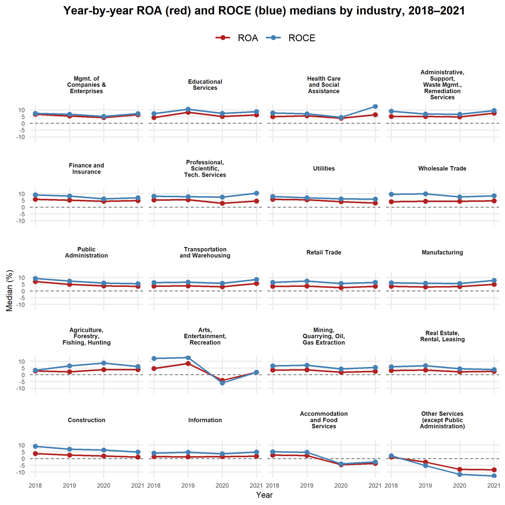

Figure 11: Year-by-year industry medians for ROA (red) and ROCE (blue), 2018-2021. Each panel is one industry; lines connect annual medians and the dashed line marks zero. Industries are ordered by overall ROA. Patterns show the 2020 COVID shock with mixed 2021 rebounds; ROCE generally moves more than ROA within industries. Reference: Lecture 7 - Comparing strata

```r
# Compute industry × year medians
ind_year_both <- osiris_tidy %>%
  group_by(industry_category, financial_year) %>%
  summarise(
    ROA  = median(recal_roa),
    ROCE = median(roce_imputed),
    .groups = "drop"
  ) %>%
  pivot_longer(c(ROA, ROCE), names_to = "metric", values_to = "median_val")

# Order industries by overall median ROA (desc) for consistent facet order
ind_order <- ind_year_both %>%
  filter(metric == "ROA") %>%
  group_by(industry_category) %>%
  summarise(overall = median(median_val), .groups = "drop") %>%
  arrange(desc(overall)) %>%
  pull(industry_category)

# Apply factor order and wrap long facet labels
ind_year_both <- ind_year_both %>%
  mutate(
    industry_category = factor(industry_category, levels = ind_order),
    industry_label = fct_relabel(industry_category, ~ str_wrap(.x, width = 16))
  )

# Plot: per-industry ROA (red) & ROCE (blue) over years (median values)
ggplot(ind_year_both,
       aes(x = financial_year, y = median_val, color = metric, group = metric)) +
  geom_hline(yintercept = 0, linewidth = 0.3, linetype = "dashed", alpha = 0.6) +
  geom_line(linewidth = 0.7) +
  geom_point(size = 1.5) +
  facet_wrap(~ industry_label, ncol = 4, scales = "fixed") +
  scale_color_manual(values = c(ROA = "firebrick", ROCE = "steelblue")) +
  scale_x_continuous(breaks = sort(unique(osiris_tidy$financial_year))) +
  labs(
    title = "Year-by-year ROA (red) and ROCE (blue) medians by industry, 2018–2021",
    x = "Year", y = "Median (%)", color = NULL
  ) +
  theme_minimal(base_size = 10) +
  theme(
    plot.title   = element_text(hjust = 0.5, face = "bold", size = 10),
    axis.title.x = element_text(size = 7),
    axis.title.y = element_text(size = 7),
    axis.text.x  = element_text(size = 5),
    axis.text.y  = element_text(size = 5),
    strip.text   = element_text(face = "bold", size = 5),
    legend.position = "top",
    panel.grid.minor = element_blank()
  )
```

Table 14 shows that the steepest pandemic hit in 2020 fell on consumer-facing and capital-intensive services:

*Arts, Entertainment & Recreation* (100% down on both ROA and ROCE) and *Accommodation & Food Services* (88%/88%) lead the declines, while *Utilities*, *Information*, *Health Care & Social Assistance*, *Construction*, *Transportation & Warehousing*, and *Retail Trade* each have roughly two-thirds or more of firms down on both metrics.

Rows with 100% declines in *Educational Services*, *Management of Companies & Enterprises*, and *Public Administration* reflect single-firm samples (n=1) and are not representative.

Two sectors show notable ROA-ROCE divergence: in *Professional*, *Scientific & Technical Services*, 56% of firms’ ROA falls but 59% of firms’ ROCE rises, consistent with stronger operating returns or a tighter capital base, whereas in *Finance & Insurance*, ROA is split 50/50 but 66% of firms see ROCE declines, pointing to operating strain or limited denominator relief.

The most resilient broad sector is *Manufacturing*, the largest sample (n=271) with slim majorities improving on both ROA and ROCE (53%/54%); *Agriculture, Forestry, Fishing & Hunting* also improves on both (67%/67%), though its tiny sample (n=3) warrants caution.

Overall, the cross-industry shares corroborate a broad 2020 downturn with **heterogeneous intensity and different operating versus accounting drivers**.

```r
# Build per-firm change flags for 2019→2020 (ROA)
delta_roa <- osiris_tidy %>%
  select(company_name, industry_category, financial_year, roa = recal_roa) %>%
  filter(financial_year %in% c(2019, 2020)) %>%
  pivot_wider(names_from = financial_year, values_from = roa, names_prefix = "y") %>%
  filter(!is.na(y2019), !is.na(y2020)) %>%
  mutate(status = if_else(y2020 < y2019, "Decline", "Upward"))

# Build per-firm change flags for 2019→2020 (ROCE)
delta_roce <- osiris_tidy %>%
  select(company_name, industry_category, financial_year, roce = roce_imputed) %>%
  filter(financial_year %in% c(2019, 2020)) %>%
  pivot_wider(names_from = financial_year, values_from = roce, names_prefix = "y") %>%
  filter(!is.na(y2019), !is.na(y2020)) %>%
  mutate(status = if_else(y2020 < y2019, "Decline", "Upward"))

# ROA: within-industry shares of Decline vs Upward
roa_share <- delta_roa %>%
  count(industry_category, status, name = "n_status") %>%
  group_by(industry_category) %>%
  mutate(pct = n_status / sum(n_status)) %>%
  ungroup() %>%
  select(industry_category, status, pct) %>%
  pivot_wider(names_from = status, values_from = pct, values_fill = 0) %>%
  rename(`ROA decline %` = Decline,
         `ROA upward %`  = Upward)

# ROCE: within-industry shares of Decline vs Upward
roce_share <- delta_roce %>%
  count(industry_category, status, name = "n_status") %>%
  group_by(industry_category) %>%
  mutate(pct = n_status / sum(n_status)) %>%
  ungroup() %>%
  select(industry_category, status, pct) %>%
  pivot_wider(names_from = status, values_from = pct, values_fill = 0) %>%
  rename(`ROCE decline %` = Decline,
         `ROCE upward %`  = Upward)

# Industry sample sizes (firms with ROA pairs)
industry_num <- delta_roa %>%
  count(industry_category, name = "industry_num")

# Combine, order by ROA decline share, format as percents
combined_tbl <- roa_share %>%
  left_join(roce_share,  by = "industry_category") %>%
  left_join(industry_num, by = "industry_category") %>%
  arrange(desc(`ROA decline %`)) %>%
  mutate(
    `ROA decline %`  = percent(`ROA decline %`,  accuracy = 1),
    `ROA upward %`   = percent(`ROA upward %`,   accuracy = 1),
    `ROCE decline %` = percent(`ROCE decline %`, accuracy = 1),
    `ROCE upward %`  = percent(`ROCE upward %`,  accuracy = 1)
  ) %>%
  select(
    Industry = industry_category,
    `ROA decline %`, `ROA upward %`,
    `ROCE decline %`, `ROCE upward %`,
    industry_num
  ) %>%
  rename(`Firm count` = industry_num)

# Table
kable(
  combined_tbl,
  format = "html",
  caption = "Share of firms with decline vs upward change from 2019 to 2020, by industry (ROA and ROCE side-by-side)."
) %>%
  kable_styling(full_width = FALSE, bootstrap_options = c("striped", "hover"))
```

Table 14: Share of firms with decline vs upward change from 2019 to 2020, by industry (ROA and ROCE side-by-side)

Share of firms with decline vs upward change from 2019 to 2020, by industry (ROA and ROCE side-by-side).

| Industry | ROA decline % | ROA upward % | ROCE decline % | ROCE upward % | Firm count |
| --- | --- | --- | --- | --- | --- |
| Arts, Entertainment, Recreation | 100% | 0% | 100% | 0% | 7 |
| Educational Services | 100% | 0% | 100% | 0% | 1 |
| Mgmt. of Companies & Enterprises | 100% | 0% | 100% | 0% | 1 |
| Public Administration | 100% | 0% | 100% | 0% | 1 |
| Accommodation and Food Services | 88% | 12% | 88% | 12% | 17 |
| Utilities | 83% | 17% | 78% | 22% | 18 |
| Information | 78% | 22% | 68% | 32% | 40 |
| Health Care and Social Assistance | 76% | 24% | 71% | 29% | 17 |
| Construction | 70% | 30% | 68% | 32% | 44 |
| Transportation and Warehousing | 69% | 31% | 73% | 27% | 26 |
| Retail Trade | 68% | 32% | 68% | 32% | 25 |
| Other Services (except Public Administration) | 67% | 33% | 67% | 33% | 3 |
| Wholesale Trade | 62% | 38% | 60% | 40% | 60 |
| Real Estate, Rental, Leasing | 60% | 40% | 67% | 33% | 73 |
| Administrative, Support, Waste Mgmt., Remediation Services | 58% | 42% | 67% | 33% | 12 |
| Mining, Quarrying, Oil, Gas Extraction | 58% | 42% | 67% | 33% | 12 |
| Professional, Scientific, Tech. Services | 56% | 44% | 41% | 59% | 34 |
| Finance and Insurance | 50% | 50% | 66% | 34% | 38 |
| Manufacturing | 47% | 53% | 46% | 54% | 271 |
| Agriculture, Forestry, Fishing, Hunting | 33% | 67% | 33% | 67% | 3 |

**Conclusion: ROA and ROCE Across Industries and Years**

**Across 2018-2021, ROA is steady in 2018-2019, dips in 2020, and rebounds in 2021**, with heavy left tails, and for ROCE, indicating more extreme underperformers during the downturn (Figure 3; Figure 4; Figure 2).

Comparing the two ratios helps locate pressure: a larger ROCE drop typically signals weaker core operations or little change in capital employed, whereas a smaller ROCE drop suggests operating profit held up or the capital base tightened. Decompositions clarify why ratios don’t surge more in 2021: the numerators (net profit; net profit minus interest) trace a V-shape, but denominators (total assets; capital employed) keep rising, tempering the rebound.

*Utilities*, *Information*, *Construction*, *Transportation and Warehousing*, and *Retail Trade* have ~70% (or more) of firms down on both ROA and ROCE in 2020, their industry medians dip only modestly, broad weakness, but not a collapse. Most other sectors are closer to a 50/50 split in the table and show little movement in medians across years.

#### How did EBIT margin change through the pandemic

EBIT (Earnings Before Interest and Taxes) Margin is a key ratio measuring a company’s **core operational efficiency**, independent of its financing and tax structure. Tracking this metric reveals the pandemic’s direct impact on business operations, highlighting which sectors were resilient and which struggled to maintain profitability.

**The Distribution of EBIT Margin: A Non-Normal Reality**

Before analyzing trends, we must understand the data’s underlying distribution. The charts below confirm that EBIT Margin is **significantly non-normal**, a typical characteristic of financial data.

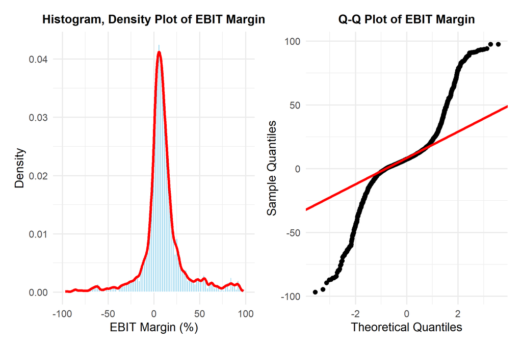

Figure 12: Distribution of EBIT Margin for all firms (2018-2021), Reference: Lecture 5_slide 30.

```r
# Histogram and Density Plot
p1 <- ggplot(osiris_tidy, aes(x = ebit_margin_imputed)) +
  geom_histogram(aes(y = ..density..), bins = 100, fill = "skyblue", color = "white") +
  geom_density(color = "red", size = 1) +
  coord_cartesian(xlim = c(-100, 100)) +
  labs(
    title = "Histogram, Density Plot of EBIT Margin",
    x = "EBIT Margin (%)",
    y = "Density"
  ) +
  theme_minimal(base_size = 10) +
  theme(
    plot.title = element_text(size = 10, face = "bold",
    aspect.ratio = 1, hjust = 0.5)
  )

# QQ Plot
p2 <- ggplot(osiris_tidy, aes(sample = ebit_margin_imputed)) +
  stat_qq() +
  stat_qq_line(color = "red", size = 1) +
  labs(
    title = "Q-Q Plot of EBIT Margin",
    x = "Theoretical Quantiles",
    y = "Sample Quantiles"
  ) +
  theme_minimal(base_size = 10) +
  theme(
    plot.title = element_text(size = 10, face = "bold",
    aspect.ratio = 1,hjust = 0.5)
  )

p1 + p2
```

**Overall Market Trend: A Sharp Shock and a Resilient Recovery**

To understand the pandemic’s macroeconomic impact, we first examine the overall trend in corporate profitability for the entire Thai market from 2018 to 2021.

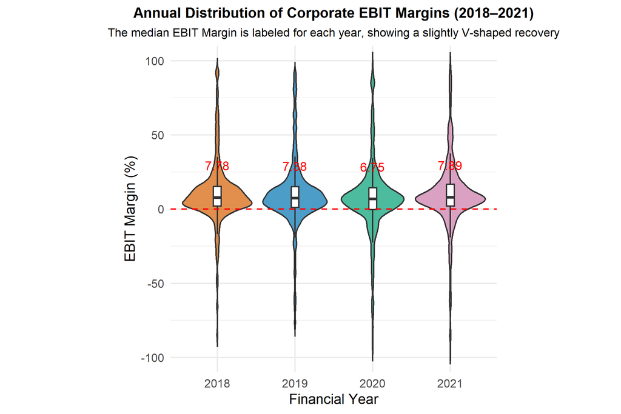

Figure 13: Annual Distribution of Corporate EBIT Margins (2018–2021), Reference: Lecture 7_slide 6

```r
ggplot(osiris_tidy, aes(x = as.factor(financial_year), y = ebit_margin_imputed)) +
  geom_violin(aes(fill = as.factor(financial_year)), trim = FALSE, alpha = 0.7, show.legend = FALSE) +
  geom_boxplot(width = 0.1, fill = "white", outlier.shape = NA) +
  stat_summary(
    fun = "median",
    geom = "text",
    aes(label = sprintf("%.2f", ..y..)),
    vjust = -3,
    size = 3,
    color = "red"
  ) +
  geom_hline(yintercept = 0, linetype = "dashed", color = "red") +
  coord_cartesian(ylim = c(-100, 100)) +
  labs(
    title = "Annual Distribution of Corporate EBIT Margins (2018–2021)",
    subtitle = "The median EBIT Margin is labeled for each year, showing a slightly V-shaped recovery",
    x = "Financial Year",
    y = "EBIT Margin (%)"
  ) +
  theme_minimal(base_size = 10) +
  theme(
    plot.title = element_text(size = 10, face = "bold", hjust = 0.5),
    plot.subtitle = element_text(size = 8, hjust = 0.5),
    aspect.ratio = 1
  )
```

Figure 13 provides two key insights. Firstly, the labeled median values clearly illustrate the V-shaped trend: profitability for the typical firm declined from a median of 7.38% in 2019 to a low of 6.75% in 2020, before surging to a four-year high of 7.89% in 2021.

Secondly, and more subtly, the chart reveals the **remarkable consistency of the market’s underlying structure**. Across all four years, the shape of the violin remains largely the same: a wide body concentrated around the median with very long, thin tails. This indicates that the fundamental nature of the Thai corporate landscape, a **large number of “typical” firms clustered together**, alongside a significant number of extreme high and low performers, did not change across 2018-2021. The pandemic acted as a systemic shock that shifted the entire distribution downward in 2020 and then upward in 2021, rather than fundamentally altering its shape.

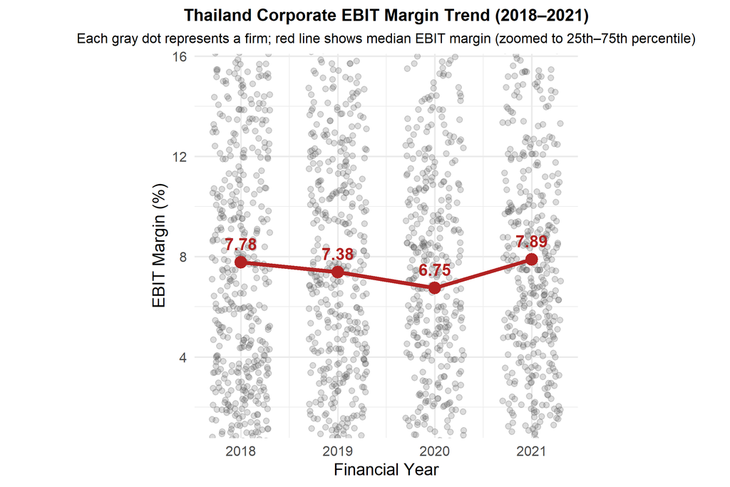

Figure 14: EBIT Margin Trend for the Interquartile Range (25th-75th Percentile), Reference: Tutorial 7 and Lecture 11_slide 19.

```r
median_ebit <- osiris_tidy %>%
  group_by(financial_year) %>%
  summarise(med_ebit = median(ebit_margin_imputed, na.rm = TRUE))

q_ebit <- quantile(osiris_tidy$ebit_margin_imputed, c(0.25, 0.75), na.rm = TRUE)

ggplot(osiris_tidy, aes(x = financial_year, y = ebit_margin_imputed)) +
  geom_jitter(width = 0.3, height = 0, alpha = 0.2, na.rm = TRUE, color = "gray30") +
  geom_line(data = median_ebit, aes(x = financial_year, y = med_ebit, group = 1),
            color = "firebrick", linewidth = 1.1) +
  geom_point(data = median_ebit, aes(x = financial_year, y = med_ebit),
             color = "firebrick", size = 3) +
  geom_text(data = median_ebit,
            aes(x = financial_year, y = med_ebit, label = round(med_ebit, 2)),
            vjust = -1, color = "firebrick", size = 3.5, fontface = "bold") +
  coord_cartesian(ylim = q_ebit) +
  scale_x_continuous(breaks = 2018:2021) +
  theme_minimal(base_size = 10) +
  theme(
    plot.title = element_text(size = 10, face = "bold", hjust = 0.5),
    plot.subtitle = element_text(size = 8, hjust = 0.5),
    aspect.ratio = 1) +
  labs(
    title = "Thailand Corporate EBIT Margin Trend (2018–2021)",
    subtitle = "Each gray dot represents a firm; red line shows median EBIT margin (zoomed to 25th–75th percentile)",
    x = "Financial Year",
    y = "EBIT Margin (%)"
  )
```

```r
trend_summary <- osiris_tidy %>%
  group_by(financial_year) %>%
  summarise(
    med_ebit_margin = median(ebit_margin_imputed, na.rm = TRUE),
  ) %>%
  mutate(
    margin_growth_rate = (med_ebit_margin - dplyr::lag(med_ebit_margin)) / dplyr::lag(med_ebit_margin) * 100
  )

knitr::kable(
  trend_summary,
  col.names = c("Financial Year", "Median EBIT Margin (%)", "YoY Growth Rate (%)"),
  caption = "Thailand Corporate Profitability Trend (2018-2021)",
  digits = 1 # Format numbers to one decimal place.
) %>%
  kableExtra::kable_styling(
    bootstrap_options = c("striped", "hover", "condensed"),
    full_width = FALSE
  )
```

Table 15: Year-over-Year Change in Median Corporate Profitability.

Thailand Corporate Profitability Trend (2018-2021)

| Financial Year | Median EBIT Margin (%) | YoY Growth Rate (%) |
| --- | --- | --- |
| 2018 | 7.8 | NA |
| 2019 | 7.4 | -5.1 |
| 2020 | 6.8 | -8.5 |
| 2021 | 7.9 | 16.9 |

Table 15 reveals a clear narrative of shock and recovery. The median EBIT margin fell from 7.4% in 2019 to a trough of 6.8% in 2020, an 8.5% year-over-year collapse. This was followed by a powerful 16.9% rebound in 2021, with the median margin surging to a four-year high of 7.9%. This pattern highlights both the severity of the 2020 shock and the remarkable resilience of the Thai corporate sector’s recovery.

**Relationship Between EBIT and Total Revenue**

The relationship between core operational profit (EBIT) and Total Revenue was examined to understand the underlying drivers of profitability. The analysis was conducted on both a linear and a log-log scale to identify outliers and discern the core trend.

```r
ebit_revenue_data <- osiris_tidy %>%
  mutate(
    pandemic_period = if_else(financial_year <= 2019, "Pre-pandemic (2018–2019)", "During-pandemic (2020–2021)"),
    Revenue_bn = total_revenues_imputed / 1e9,
    EBIT_bn = earnings_before_interest_tax / 1e9
  ) %>%
  select(
    company_name, financial_year, industry_category, pandemic_period,
    Revenue_bn, EBIT_bn, ebit_margin_imputed
  ) %>%
  filter(!is.na(Revenue_bn), !is.na(EBIT_bn), Revenue_bn > 0, EBIT_bn > 0)

# Linear plot
ebit_plot_linear <- ggplot(
  ebit_revenue_data,
  aes(
    x = Revenue_bn,
    y = EBIT_bn,
    colour = pandemic_period,
    text = paste0(
      "Company: ", company_name,
      "<br>Year: ", financial_year,
      "<br>Industry: ", industry_category,
      "<br>EBIT Margin: ", round(ebit_margin_imputed, 2), " %",
      "<br>Total Revenue: ", round(Revenue_bn, 2), " bn",
      "<br>EBIT: ", round(EBIT_bn, 2), " bn"
    )
  )
) +
  geom_point(alpha = 0.6) +
  geom_smooth(method = "lm", color = "grey50", linetype = "dashed", linewidth = 0.6) +
  labs(x = "Total Revenue (THB bn)", y = "EBIT (THB bn)") +
  theme_minimal() +
  theme(plot.title = element_blank())

# log-log
ebit_plot_log <- ggplot(
  ebit_revenue_data,
  aes(
    x = Revenue_bn,
    y = EBIT_bn,
    colour = pandemic_period,
    text = paste0(
      "Company: ", company_name,
      "<br>Year: ", financial_year,
      "<br>Industry: ", industry_category,
      "<br>EBIT Margin: ", round(ebit_margin_imputed, 2), " %",
      "<br>Total Revenue: ", round(Revenue_bn, 2), " bn",
      "<br>EBIT: ", round(EBIT_bn, 2), " bn"
    )
  )
) +
  geom_point(alpha = 0.6) +
  geom_smooth(method = "lm", color = "grey50", linetype = "dashed", linewidth = 0.6) +
  scale_x_log10(labels = label_number(accuracy = 0.1)) +
  scale_y_log10(labels = label_number(accuracy = 0.1)) +
  labs(x = "Total Revenue (log10 THB bn)", y = "EBIT (log10 THB bn)") +
  theme_minimal() +
  theme(plot.title = element_blank())


pL <- ggplotly(ebit_plot_linear, tooltip = "text") |> style(showlegend = FALSE)
pR <- ggplotly(ebit_plot_log, tooltip = "text")


subplot(
  pL, pR,
  shareX = FALSE, shareY = FALSE,
  nrows = 1,
  margin = 0.12,
  titleX = TRUE, titleY = TRUE
) |> plotly::layout(
  margin = list(t = 100, b = 120, l = 70, r = 110),
  xaxis  = list(domain = c(0.00, 0.47)),
  xaxis2 = list(domain = c(0.53, 1.00)),
  legend = list(
    orientation = "h",
    x = 0.5, y = -0.25, xanchor = "center",
    title = list(text = "Pandemic period")
  ),
  title = list(
    text = paste0("EBIT vs. Total Revenue Before and During the Pandemic",
                  "<br><sup>Grey dashed line: OLS fit</sup>"),
    x = 0.5, xanchor = "center"
  ),
  annotations = list(
    list(x = 0.225, y = 1.06, xref = "paper", yref = "paper",
         text = "Linear scale (THB bn)", showarrow = FALSE,
         xanchor = "center", font = list(size = 10)),
    list(x = 0.775, y = 1.06, xref = "paper", yref = "paper",
         text = "Log–log scale", showarrow = FALSE,
         xanchor = "center", font = list(size = 10))
  )
)
```

[interactive chart not shown]

Figure 15: Relationship between EBIT and Total Revenue on linear (left) and log-log (right) scales, comparing pre- and during-pandemic periods.

Figure 15 illustrates the relationship between firms’ earnings (EBIT) and total revenue before and during the pandemic. In the linear-scale plot(left plot), most firms cluster near the origin, indicating relatively small earnings and revenues, while a few extreme observations, which mainly from the `mining, quarrying, and oil & gas extraction` industries, drive the wide range of values.

After applying a log–log transformation(right plot), the relationship becomes clearer and more linear, suggesting a consistent proportional growth pattern between EBIT and total revenue across firms. The fitted OLS lines (grey dashed) reveal that the general profitability–revenue relationship remained stable during the pandemic, although dispersion slightly increased, implying higher variation in firm performance under economic disruption.

#### EBIT margin across industries during the pandemic

**Industry-Level Analysis: A “K-Shaped” Divergence**

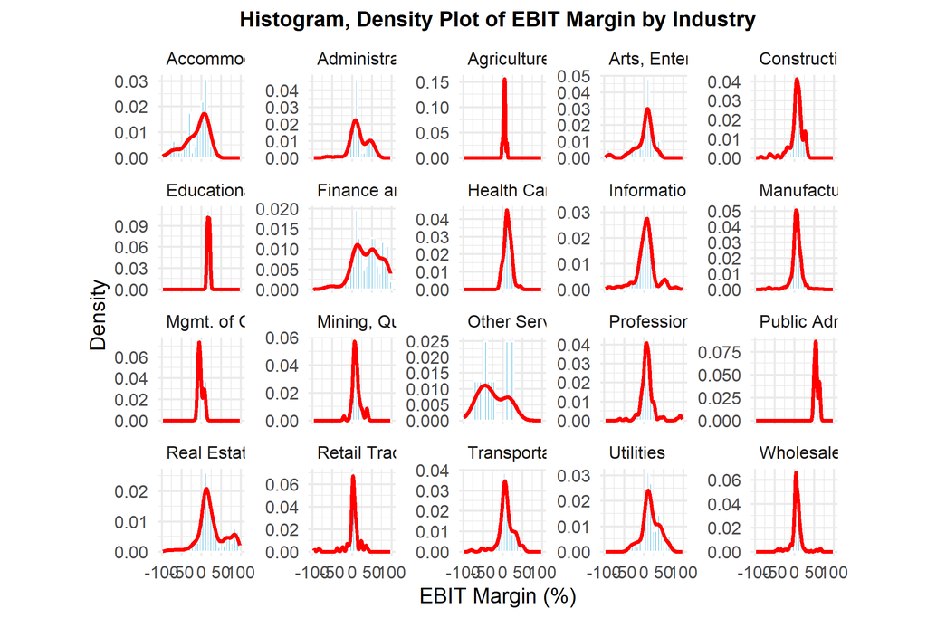

Figure 16: Distribution of EBIT margin by Industries ,Reference: Lecture 5_slide 30

```r
p1_industry <- osiris_tidy %>%
  filter(!is.na(industry_category)) %>%
  ggplot(aes(x = ebit_margin_imputed)) +
  geom_histogram(aes(y = ..density..), bins = 30, fill = "skyblue", color = "white") +
  geom_density(color = "red", size = 0.8) +
  coord_cartesian(xlim = c(-100, 100)) +
  labs(
    title = "Histogram, Density Plot of EBIT Margin by Industry",
    x = "EBIT Margin (%)",
    y = "Density"
  ) +
  theme_minimal(base_size = 10) +
  theme(
    plot.title = element_text(size = 10, face = "bold", hjust = 0.5),
    aspect.ratio = 1) +
  facet_wrap(~ industry_category, scales = "free_y") +
  theme(
    strip.text = element_text(angle = 0, hjust = 0, size = 8)
  )
p1_industry
```

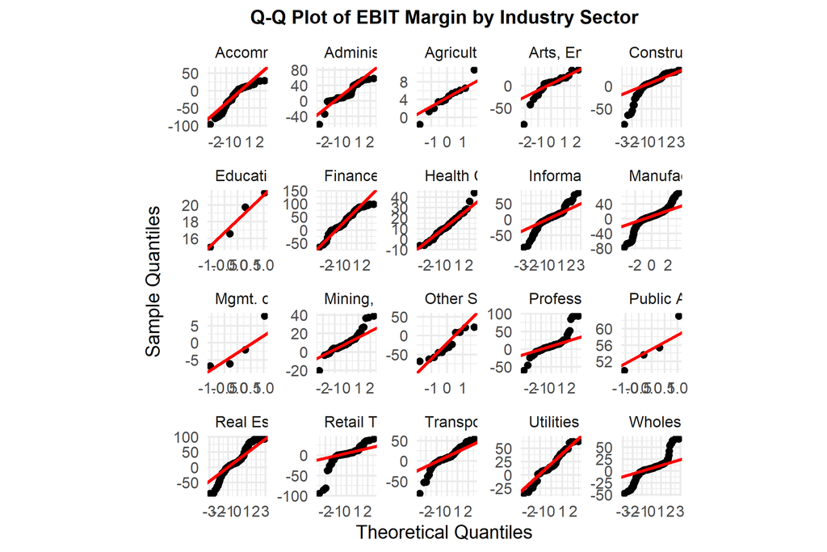

Figure 17: Distribution of EBIT margin by Industries ,Reference: Lecture 5_slide 30

```r
#
p2_industry <- osiris_tidy %>%
  filter(!is.na(industry_category)) %>%
  ggplot(aes(sample = ebit_margin_imputed)) +
  stat_qq() +
  stat_qq_line(color = "red", size = 0.8) +
  labs(
    title = "Q-Q Plot of EBIT Margin by Industry Sector",
    x = "Theoretical Quantiles",
    y = "Sample Quantiles"
  ) +
  theme_minimal(base_size = 10) +
  theme(
    plot.title = element_text(size = 10, face = "bold", hjust = 0.5),
    aspect.ratio = 1) +
  facet_wrap(~ industry_category, scales = "free") +
  theme(
    strip.text = element_text(angle = 0, hjust = 0, size = 8)
  )


p2_industry
```

As Figure 16 shown, histogram reveals that EBIT Margin distributions vary across industries. Most sectors have sharp peaks near zero or low positive values, indicating many firms with slim profits. For example, `Accommodation and Food Services` and `Retail Trade` exhibit negative skewness with tails extending to large losses, likely due to pandemic impacts. In contrast, `Finance and Insurance` and `Public Administration` have peaks in positive ranges, reflecting stable profitability. Fat tails in several industries suggest frequent extreme events, such as high gains or losses.

Figure 17 confirms non-normal distributions, with data points forming S-shaped curves that deviate from the red line. Negative tails (e.g., Arts, Entertainment, and Recreation) dip below the line, showing more severe losses than expected. Positive tails (e.g., in Professional, Scientific, Technical Services) rise above, indicating extreme profits. This highlights leptokurtosis and heavy tails, especially in contact-intensive sectors affected by COVID-19.

These patterns reveal industry-specific vulnerabilities, with service-oriented sectors showing greater non-normality due to economic shocks. For analysis, use median values to avoid bias from outliers.

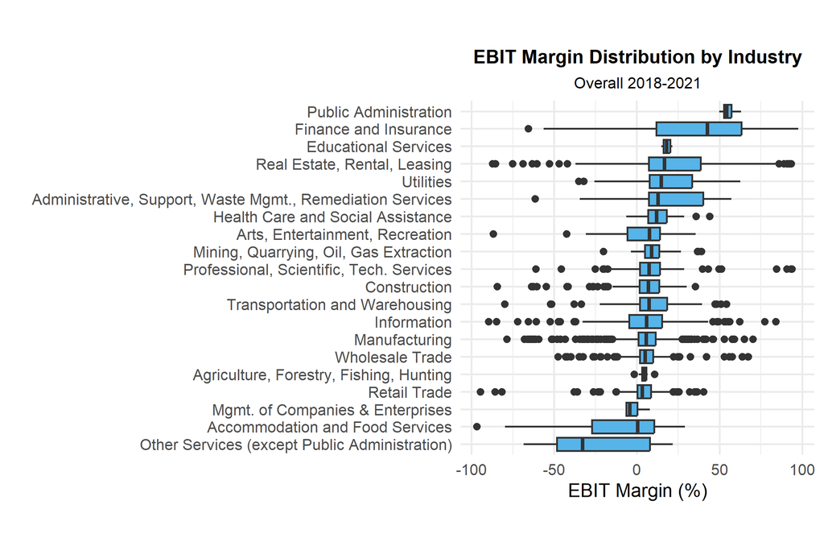

Figure 18: Each boxplot shows the spread of company-level profitability (EBIT margin) within each industry. Boxes represent the interquartile range (IQR), with medians shown as center lines. Industries are ordered by median profitability. Reference: Lecture 5_p.17

```r
industry_yearly_median <- osiris_tidy %>%
  filter(!is.na(industry_category)) %>%
  group_by(industry_category, financial_year) %>%
  summarise(med_ebit_margin = median(ebit_margin_imputed, na.rm = TRUE),
            .groups = 'drop')

# Create a period variable to distinguish pre- and post-COVID for later analyses
osiris_analyzed <- osiris_tidy %>%
  mutate(
    period = case_when(
      financial_year %in% c(2018, 2019) ~ "Pre-COVID",
      financial_year %in% c(2020, 2021) ~ "Post-COVID",
      TRUE ~ NA_character_
    )
  )

# Calculate overall median per industry and sort for consistent ordering in the plot
industry_order_boxplot <- industry_yearly_median %>%
  group_by(industry_category) %>%
  summarise(overall_median = median(med_ebit_margin, na.rm = TRUE)) %>%
  arrange(overall_median) %>%
  pull(industry_category)

# Generate the boxplot
osiris_tidy %>%
  filter(!is.na(industry_category)) %>%
  mutate(industry_category = factor(industry_category, levels = industry_order_boxplot)) %>%
  ggplot(aes(x = industry_category, y = ebit_margin_imputed)) +
  geom_boxplot(fill = "#56B4E9") +
  labs(
    title = "EBIT Margin Distribution by Industry",
    subtitle = "Overall 2018-2021",
    x = "",
    y = "EBIT Margin (%)"
  ) +
  theme_minimal(base_size = 10) +
  theme(
    plot.title = element_text(size = 10, face = "bold",hjust = 0.5),
    plot.subtitle = element_text(size = 8, hjust = 0.5),
    aspect.ratio = 1) +
  coord_flip()
```

**Year-Over-Year Evolution**

Building on the structural view, we introduce the time dimension. Figure 19 visualizes **year-over-year median EBIT margins**, enabling us to identify the pandemic’s acute impact in 2020 and observe subsequent recovery patterns in 2021, revealing divergent paths across sectors.

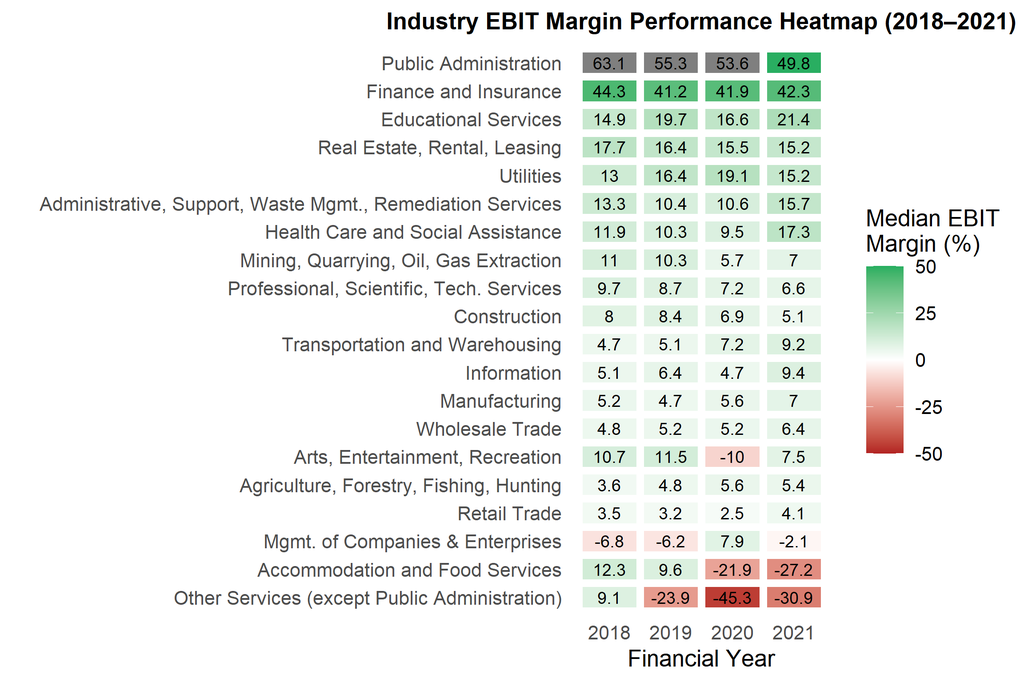

Figure 19: Year-over-year median EBIT Margin performance by industry. Reference: Tutorial 6

```r
# Calculate the 4-year average of the yearly medians
industry_order_heatmap <- industry_yearly_median %>%
  group_by(industry_category) %>%
  summarise(overall_avg_of_medians = mean(med_ebit_margin, na.rm = TRUE)) %>%
  arrange(overall_avg_of_medians) %>%
  pull(industry_category)

industry_yearly_median %>%
  mutate(industry_category = factor(industry_category, levels = industry_order_heatmap)) %>%
  ggplot(aes(x = as.factor(financial_year), y = industry_category, fill = med_ebit_margin)) +
  geom_tile(color = "white", lwd = 1.5) +
  geom_text(aes(label = round(med_ebit_margin, 1)), color = "black", size = 2.5) +
  scale_fill_gradient2(
    low = "firebrick", mid = "white", high = "#27ae60", midpoint = 0, limits = c(-50, 50),
    name = "Median EBIT\nMargin (%)"
  ) +
  labs(
    title = "Industry EBIT Margin Performance Heatmap (2018–2021)",
    x = "Financial Year", y = ""
  ) +
  theme_minimal(base_size = 10) +
  theme(panel.grid = element_blank(),
        plot.title = element_text(size = 10, face = "bold", hjust = 0.5),
  )
```

Figure 19 shows a clear “shock and recovery” pattern, with 2020 bringing sharp declines (e.g., Accommodation and Food Services) fell from 12.3% in 2018 to -21.9%, and Other Services dropped to -45.3%. Contact-intensive industries like Accommodation and Food Services, Arts, Entertainment, Recreation, and Other Services saw profitability turn deeply negative. Meanwhile, Public Administration and Finance and Insurance held strong with high positive margins.

In 2021, recovery varied: **Health Care** rose from 9.5% to 17.3% and **Education** from 16.6% to 21.4%, but `Accommodation & Food Services` and `Other Services` (e.g., personal care services, religious organizations, private households) remained in the red. This suggests the pandemic worsened existing weaknesses, hitting demand-sensitive sectors hard while essential services adapted or gained from support.

**Which Industries Suffered the Most**

Finally, we quantify the net effect by **comparing pre- and post-COVID periods**. This chart delivers the main conclusion, clearly identifying the industries that demonstrated resilience and growth versus those that suffered the most severe declines, summarizing the “K-shaped” divergence.

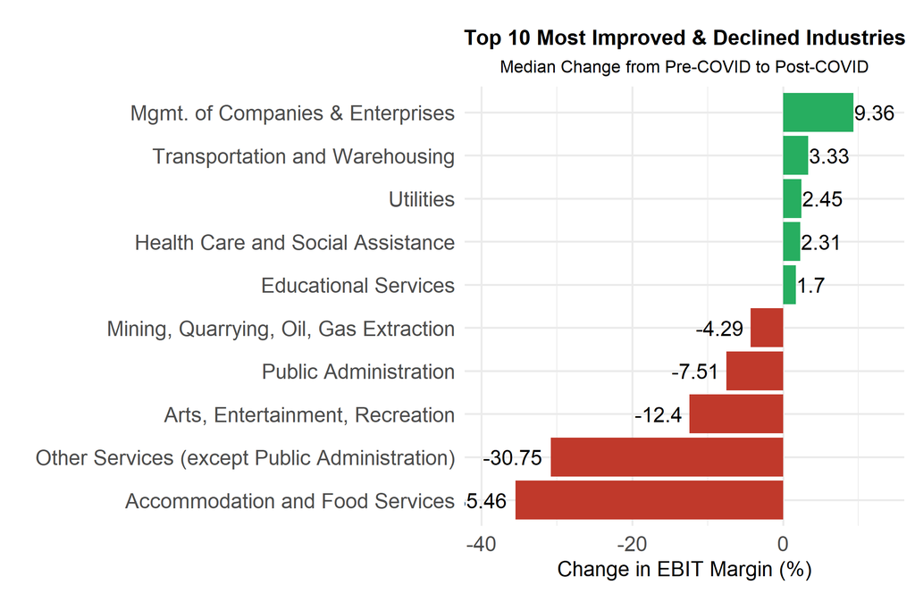

Figure 20: Bars show the change in median EBIT margin by industry, comparing 2018–2019 (Pre-COVID) to 2020–2021 (Post-COVID). Positive values indicate improved profitability, while negative values reflect deterioration. Reference: Lecture 6_slide 57

```r
industry_performance <- industry_yearly_median %>%
  mutate(
    period = if_else(financial_year <= 2019, "Pre-COVID", "Post-COVID")
  ) %>%
  group_by(industry_category, period) %>%
  summarise(period_median = median(med_ebit_margin, na.rm = TRUE), .groups = 'drop') %>%
  pivot_wider(names_from = period, values_from = period_median) %>%
  mutate(margin_change = `Post-COVID` - `Pre-COVID`) %>%
  filter(!is.na(margin_change))

# Select top 5 improved and declined industries based on margin change
top_list <- bind_rows(
  industry_performance %>% arrange(margin_change) %>% slice_head(n = 5),
  industry_performance %>% arrange(desc(margin_change)) %>% slice_head(n = 5)
)

ggplot(top_list, aes(x = margin_change, y = reorder(industry_category, margin_change))) +
  geom_col(aes(fill = margin_change > 0)) +
  geom_text(
    aes(label = round(margin_change, 2)),
    hjust = ifelse(top_list$margin_change > 0, -0.02, 1.15)
  ) +
  scale_fill_manual(values = c("FALSE" = "#c0392b", "TRUE" = "#27ae60")) +
  scale_x_continuous(
    expand = expansion(mult = c(0.15, 0.15))
  ) +
  labs(
    title = "Top 10 Most Improved & Declined Industries",
    subtitle = "Median Change from Pre-COVID to Post-COVID",
    x = "Change in EBIT Margin (%)", y = ""
  ) +
  theme_minimal(base_size = 10) +
  theme(
    legend.position = "none",
    plot.subtitle = element_text(size = 8, hjust = 0.5),
    axis.text.x = element_text(size = 10),
    axis.text.y = element_text(size = 10),
    plot.title = element_text(size = 10, face = "bold", hjust = 0.5),
    aspect.ratio = 1)
```

Figure 20 crystallizes the **“K-shaped”** impact of the pandemic. On one side, sectors like Transportation and Warehousing and Utilities demonstrated remarkable resilience, with their median profitability actually improving during the crisis, likely due to increased demand for logistics and essential services.

On the other side, the negative impact was far more severe. **Contact-intensive sectors** such as Accommodation and Food Services and Other Services experienced a catastrophic collapse in their core profitability, with median EBIT margins **declining by over 30%**. This highlights a clear divergence where essential and adaptable industries thrived while those dependent on physical interaction faced an existential crisis.

**Conclusion of EBIT Margin Analysis**

- **V-Shaped Recovery at the Macro Level:** The overall Thai market demonstrated a clear “V-shaped” recovery. The median firm’s EBIT margin, after falling by **8.5%** in FY2020, rebounded strongly with **16.9%** growth in FY2021, surging to a four-year high. This indicates remarkable resilience in the “typical” Thai company.
- **“K-Shaped” Divergence at the Industry Level:** Beneath the surface, the recovery was highly uneven. A stark “K-shaped” split emerged:
  - **Winners:** Essential and adaptable industries like **Management of Companies & Enterprises** (+9.4 %) and **Transportation** (+3.3 %) saw their median profitability improve.
  - **Losers:** Contact-intensive sectors suffered a catastrophic and lasting collapse, with **Accommodation & Food Services** (-35.5 pts) and **Other Services** (-30.8 pts) experiencing the most severe declines.

#### Conclusion for Profitability

The Q-Q plots (Figure 2) show that more firms recorded losses during the downturn, especially for ROCE. Even though profits improved again in 2021, the recovery in ratios was smaller because assets and capital employed kept rising, holding the percentages down (Figure 5; Figure 7).

These results are consistent with Thailand’s 6.1 % GDP fall in 2020 and 1.6 % rebound in 2021([World Bank (2024)](https://data.worldbank.org/indicator/NY.GDP.MKTP.KD.ZG?locations=TH)), when lockdowns and border closures hit tourism hard before gradual reopening supported business recovery.

Overall, the data point to a sharp but temporary fall in profitability, followed by partial recovery and larger differences between industries.

The next section turns to debt-paying ability, examining solvency and liquidity to see whether companies’ financial strength followed the same pattern or showed deeper balance-sheet stress.

### Debt-Paying Ability

Debt-paying ability measures a firm’s capacity to meet its financial obligations in both the short and long term. Stronger debt-paying ability is associated with lower default risk, greater financial resilience, and improved access to external financing under beneficial terms.

During the pandemic, these qualities became particularly critical as most firms faced disrupted cash flows, declining revenues, and heightened financial uncertainty. By examining debt-paying indicators before and during the pandemic, it evaluates how firms’ ability in short-term and long-term were affected, providing insights into how the pandemic influenced corporate financial.

#### Current ratio

The current ratio evaluates whether a company can meet its short-term liabilities using its current assets such as cash, receivables, and inventories. A low ratio indicates potential liquidity constraints, suggesting that the firm may rely on external financing or delayed payments. A high ratio implies adequate short-term solvency, though excessively high values may reflect inefficient use of assets. Overall, the current ratio serves as a key indicator of a firm’s short-term dimension of debt-paying ability.

##### Overall Current Ratio

Examining overall trend by yearly trend of all firms across four financial years (2018–2021), distribution of current ratio and potential shifts caused by the pandemic, and the relationship between component (current assets and current liability).

```r
# select the related variable
overall_cr_data <- osiris_tidy |>
  select(financial_year,
         company_name,
         industry_category,
         naics_core_code,
         total_current_assets,
         total_current_liabilities,
         recal_current_ratio) |>
  # mutate the period before and during pandemic
  mutate(pandemic_period = if_else(financial_year <= 2019,
                              "Pre-pandemic (2018–2019)",
                              "During-pandemic (2020–2021)"),
    pandemic_period = factor(pandemic_period,
                             levels = c("Pre-pandemic (2018–2019)",
                                        "During-pandemic (2020–2021)"))) |>
  mutate(log_cr = log10(recal_current_ratio)) |>
  group_by(financial_year) |>
  # if is outliers (>90%, <10%), True
  mutate(
    p10 = quantile(recal_current_ratio, 0.1, na.rm = TRUE),
    p90 = quantile(recal_current_ratio, 0.9, na.rm = TRUE),
    outlier_flag = recal_current_ratio < p10 | recal_current_ratio > p90
  ) |>
  ungroup() |>
  # CA and CL unit transfer
  mutate(
    CA_bn = total_current_assets / 1e6,
    CL_bn = total_current_liabilities / 1e6
  )

# zoom-in section for zoom in plot
zoomin_section <- overall_cr_data |>
  summarise(ymin = quantile(log_cr, 0.25, na.rm = TRUE),
            ymax = quantile(log_cr, 0.75, na.rm = TRUE))
```

**Current Ratio Time Trend (2018–2021)**

Figure 21 shows that firms maintained consistent current ratio these four years. Though the mean of 2020 decreased, the trend still indicating overall stability in firms current assets to meet current liabilities. However, the increased low-end outliers in 2020–2021 suggests that firms with weaker financial positions experienced short-term decline. Thus, while most firms remained stable, the pandemic led to greater variation in short-term debt-paying ability across firms, with financial pressure concentrated among few firms.

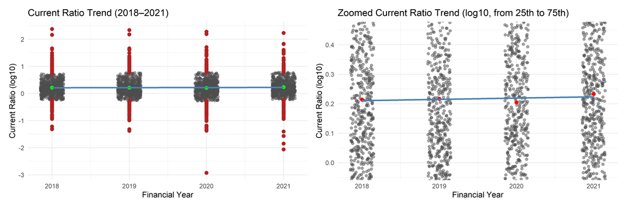

Figure 21: Four-year trend of the Current Ratio (log 10) between 2018 and 2021. The left panel displays the full distribution of firm-level current ratios. The right panel zooms into the 25th–75th percentile range to emphasize the stability of average liquidity over time. Tutorial 7

```r
overallcr_trend_plot <- ggplot(
  overall_cr_data, aes(x = financial_year, y = log_cr)) +
  geom_jitter(data = subset(overall_cr_data, !outlier_flag),
              width = 0.15, height = 0, alpha = 0.5, colour = "grey30") +
  # outliers point
  geom_point(
    data = subset(overall_cr_data, outlier_flag),
    colour = "firebrick", size = 2) +
  # yearly mean
  stat_summary(fun = "mean", geom = "point", colour = "green", size = 2)+
  geom_smooth(colour = "steelblue", se = FALSE, method = "lm") +
  labs(
    title = "Current Ratio Trend (2018–2021)",
    x = "Financial Year",
    y = "Current Ratio (log10)"
  ) +
  theme_minimal()

overallcr_trend_plot_zoom <- ggplot(
  overall_cr_data, aes(x = financial_year, y = log_cr)) +
  geom_jitter(data = subset(overall_cr_data, !outlier_flag),
              width = 0.15, height = 0, alpha = 0.5, colour = "grey30") +
  geom_point(data = subset(overall_cr_data, outlier_flag),
             colour = "firebrick", size = 2) +
  stat_summary(fun = "mean", geom = "point", colour = "red", size = 2) +
  geom_smooth(colour = "steelblue", se = FALSE, method = "lm") +
  # set up zoom in section
  coord_cartesian(ylim = c(zoomin_section$ymin, zoomin_section$ymax)) +
  labs(
    title = "Zoomed Current Ratio Trend (log10, from 25th to 75th)",
    x = "Financial Year",
    y = "Current Ratio (log10)"
  ) +
  theme_minimal()

overallcr_trend_plot | overallcr_trend_plot_zoom
```

**Distributional Shifts Before and During the Pandemic**

Figure 22 shows that the distribution of current ratios widened during the pandemic. The heavier lower tail during the pandemic period (2020–2021) indicates that a small group of firms experienced sharper decline in short-term debt-paying ability, while the overall median remained stable.

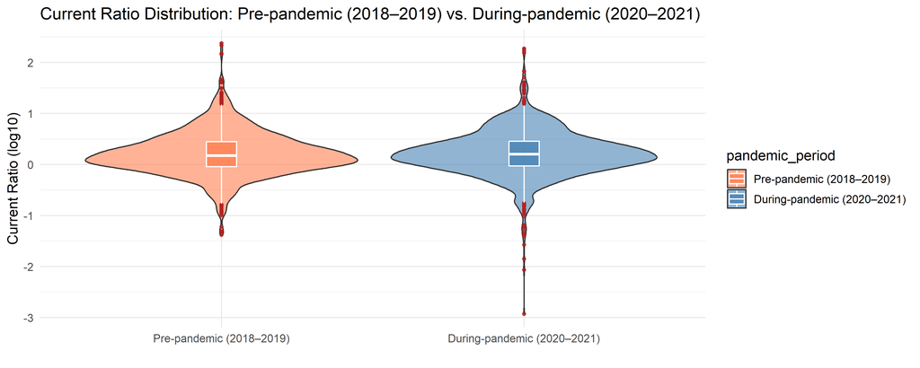

Figure 22: Distribution between the pre-pandemic (2018–2019) and during-pandemic (2020–2021) periods. Lecture 7, slides 6 and 8

```r
overallcr_distr_plot <- ggplot(
  overall_cr_data, aes(x = pandemic_period, y = log_cr,
                       fill = pandemic_period)) +
  geom_violin(alpha = 0.6) +
  geom_boxplot(width = 0.1, color = "white", alpha = 0.8,
               outlier.colour = "firebrick", outlier.size = 1) +
  scale_fill_manual(values = c("Pre-pandemic (2018–2019)" = "coral",
                               "During-pandemic (2020–2021)" = "steelblue")) +
  labs(
    title = "Current Ratio Distribution: Pre-pandemic (2018–2019) vs. During-pandemic (2020–2021)",
    x = "",
    y = "Current Ratio (log10)"
  ) +
  theme_minimal()

overallcr_distr_plot
```

**Relationship Between Current Assets (CA) and Current Liabilities (CL)**

In contrast, **PTT PCL** maintained a strong liquidity, illustrating how large, well-capitalized firms sustained stable short-term solvency despite the pandemic shock.

```r
# left: linear
ca_cl_plot_linear <- ggplot(
  overall_cr_data, aes(x = CL_bn,
                       y = CA_bn,
                       colour = pandemic_period,
                       text = paste0(
                         "Company: ", company_name,
                         "<br>Year: ", financial_year,
                         "<br>Industry: ", industry_category,
                         "<br>CR: ", round(recal_current_ratio, 2), " %",
                         "<br>CA: ", round(total_current_assets, 2),
                         "<br>CL: ", round(total_current_liabilities, 2)
                       ))) +
  geom_point(alpha = 0.6) +
  geom_smooth(method = "lm", color = "grey50", linetype = "dashed") +
  labs(
    x = "Current Liabilities (THB bn)",
    y = "Current Assets (THB bn)") +
  theme_minimal() +
  theme(plot.title = element_blank())

# right: log
ca_cl_plot_log <- ggplot(overall_cr_data, aes(x = CL_bn,
                                              y = CA_bn,
                                              colour = pandemic_period,
      text = paste0("Company: ", company_name,
                    "<br>Year: ", financial_year,
                    "<br>Industry: ", industry_category,
                    "<br>CR: ", round(recal_current_ratio, 2), " %",
                    "<br>CA: ", round(total_current_assets, 2),
                    "<br>CL: ", round(total_current_liabilities, 2)))) +
  geom_point(alpha = 0.6) +
  # CR = 1
  geom_abline(slope = 1, intercept = 0, linetype = "dotdash", linewidth = 0.4, color = "grey60") +
  geom_smooth(method = "lm", color = "grey50", linetype = "dashed") +
  scale_x_log10(
    labels = label_number(accuracy = 0.1)
  ) +
  scale_y_log10(
    labels = label_number(accuracy = 0.1)
  ) +
  labs(
    x = "Current Liabilities (log10 THB bn)",
    y = "Current Assets (log10 THB bn)") +
  theme_minimal() +
  theme(plot.title = element_blank())

# plotly
pL <- ggplotly(ca_cl_plot_linear, tooltip = "text") |>
  style(showlegend = FALSE)
pR <- ggplotly(ca_cl_plot_log, tooltip = "text")

# combine the plot
subplot(
  pL, pR,
  shareX = FALSE, shareY = FALSE,
  nrows = 1,
  margin = 0.12,
  titleX = TRUE, titleY = TRUE) |>
  plotly::layout(
    margin = list(t = 120, b = 90, l = 70, r = 110),
    xaxis  = list(domain = c(0.00, 0.47)),
    xaxis2 = list(domain = c(0.53, 1.00)),
    legend = list(orientation = "h", x = 0.5, y = -0.15,
                  title = list(text = "Pandemic period")),
    title = list(
      text = paste0("Current Assets–Liabilities Relationship Before and During the Pandemic", "<br><sup>Grey dashed line: Current Ratio = 1 (CA = CL)</sup>"),
      x = 0.5, xanchor = "center"
    ),
    margin = list(t = 70),
    annotations = list(
      list(x = 0.225, y = 1.06, xref = "paper", yref = "paper",
           text = "Linear scale (THB bn)", showarrow = FALSE,
           xanchor = "center",
           font = list(size = 10)),
      list(x = 0.775, y = 1.06, xref = "paper", yref = "paper",
           text = "Log–log scale", showarrow = FALSE, xanchor = "center",
           font = list(size = 10))))
```

[interactive chart not shown]

To further understand the drivers of this deterioration, the next step focuses on industries, comparing their total current assets and total current liabilities changes before and during the pandemic to identify the sources of liquidity weakening.

##### Iudstry-Level Current Ratio Analysis

**Yearly Trend by Industry**

```r
# median for year x industry
industry_cr_year <- overall_cr_data |>
  group_by(industry_category, financial_year) |>
  summarise(
    median_cr = median(recal_current_ratio, na.rm = TRUE),
    n = n(),
    .groups = "drop"
  )

# Industry abbreviation for facet plot
abbr_labels <- c(
  "Accommodation and Food Services" = "A.F.S.",
  "Administrative, Support, Waste Mgmt., Remediation Services" = "A.W.M.R.",
  "Agriculture, Forestry, Fishing, Hunting" = "A.F.F.H.",
  "Arts, Entertainment, Recreation" = "A.E.R.",
  "Construction" = "CONS.",
  "Educational Services" = "EDU.",
  "Finance and Insurance" = "FIN.",
  "Health Care and Social Assistance" = "H.C.S.A.",
  "Information" = "INFO.",
  "Manufacturing" = "MFG.",
  "Management of Companies & Enterprises" = "M.C.E.",
  "Mining, Quarrying, Oil, Gas Extraction" = "MIN.O.G.",
  "Other Services (except Public Administration)" = "OTH.SRV.",
  "Professional, Scientific, Tech. Services" = "P.S.T.S.",
  "Public Administration" = "PUB.ADM.",
  "Real Estate, Rental, Leasing" = "R.E.R.L.",
  "Retail Trade" = "RET.",
  "Transportation and Warehousing" = "TRANS.W.",
  "Utilities" = "UTIL.",
  "Wholesale Trade" = "WHSL."
)

industry_cr_year <- industry_cr_year |>
  mutate(industry_abbr  = recode(industry_category, !!!abbr_labels))
```

Figure 24 shows that most industries’ current ratio stayed above 1, though several industries (Transportation and Warehousing, Real Estate, and Education) showed sharp declines around 2020, indicating temporary liquidity stress. In contrast, Public Administration and Administrative & Waste Management recorded notable increases, reflecting uneven liquidity responses across industries during the pandemic.

```r
industry_yrmedian_plot <- ggplot(industry_cr_year, aes(
  x = financial_year,
  y = median_cr,
  group = industry_abbr,
  text = paste0(
    "<br>Year: ", financial_year,
    "<br>Industry: ", industry_category,
    "<br>Median Current Ratio: ", median_cr))) +
  geom_line(color = "steelblue") +
  geom_point(size = 1.5, color = "darkorange") +
  geom_hline(yintercept = 1, linetype = "dashed", color = "grey50") +
  facet_wrap(~ industry_abbr, scales = "free_y") +
  labs(
    title = "Median Current Ratio (2018–2021) by Industry",
    x = "Financial Year",
    y = "Median Current Ratio"
  ) +
  theme_minimal()

# plotly
industry_yrmedian_plotly <- ggplotly(
  industry_yrmedian_plot, tooltip = "text")
industry_yrmedian_plotly
```

[interactive chart not shown]

Figure 24: Yearly median Current Ratio for each industry, with the dashed grey line indicating the liquidity threshold (CR = 1).

Based on the industry-level trends, two contrasting groups are identified:

1. **Decrease when pandemic effect:** Transportation & Warehousing, Real Estate, and Educational Services
2. **Increase when pandemic effect:** Public Administration and Administrative & Waste Management

```r
grp_decrease <- c("Transportation and Warehousing",
                  "Real Estate, Rental, Leasing",
                  "Educational Services")

grp_increase <- c("Public Administration",
                  "Administrative, Support, Waste Mgmt., Remediation Services")

cr_decgroup_overall <- overall_cr_data |>
  filter(industry_category %in% grp_decrease)

cr_incgroup_overall <- overall_cr_data |>
  filter(industry_category %in% grp_increase)
```

Examining the movement of total current assets and total current liabilities within these industries helps explain whether the changes in short-term debt-paying ability from asset contraction, liability expansion, or policy effects.

**Current Ratio Decrease When Pandemic Effect**

Figure 25 shows that the decline in Current Ratios across the three industries from different balance sheet adjustments:

- **Educational Services:** The downward shift indicates a contraction in total current assets, likely due to operational shutdowns and reduced cash inflows during the pandemic.
- **Real Estate:** The rightward shift suggesting an expansion of total current liabilities, likely cause by rising short-term debt and delayed property demand.
- **Transportation and Warehousing:** The shift show both rightward and downward shifts, indicating the effect on both total current assets and total current liabilities, as cash flow disruptions met short-term financing pressure.

Real Estate firms moved more consistently, whereas Transportation firms showed greater differences in short-term pressure.

```r
deccr_bygroup_plot <- ggplot(cr_decgroup_overall,
                              aes(x = CL_bn, y = CA_bn,
                                  colour = factor(financial_year),
      text = paste0("Company: ", company_name,
                    "<br>Year: ", financial_year,
                    "<br>Industry: ", industry_category,
                    "<br>CR: ", round(recal_current_ratio, 2), " %",
                    "<br>CA: ", round(total_current_assets, 2),
                    "<br>CL: ", round(total_current_liabilities, 2)))) +
  geom_point(alpha = 0.6) +
  # CR = 1
  geom_abline(slope = 1, intercept = 0,
              linetype = "dotdash", linewidth = 0.4, color = "grey60") +
  facet_wrap(~ industry_category, scales = "free_y") +
  scale_x_log10(labels = label_number(accuracy = 0.1)) +
  scale_y_log10(labels = label_number(accuracy = 0.1)) +
  labs(
    title = "CA vs CL (log–log) — Industries with Current Ratio Decrease",
    x = "Current Liabilities (log10 THB bn)",
    y = "Current Assets (log10 THB bn)",
    colour = "Financial Year") +
  theme_minimal()

#plotly
deccr_bygroup_plotly <- ggplotly(deccr_bygroup_plot, tooltip = "text") |>
  plotly::layout(legend = list(orientation = "h", x = 0.5,
                       xanchor = "center", y = -0.12))

deccr_bygroup_plotly
```

[interactive chart not shown]

Figure 25: Log–log scatter of Current Assets (CA) and Current Liabilities (CL) for decreased current ratio industries. Points are colored by year (2018–2021), and the grey dashed line indicates CR = 1, where firms’ current assets equal current liabilities. Tutorial, week 6.

**Current Ratio Increase When Pandemic Effect**

Figure 26 shows that the increase in Current Ratios across the two industries mainly reflects improvements on the asset side:

- **Administrative & Waste Management:** The upward shift indicates an expansion in total current assets, likely driven by rising demand for public cleaning and waste management services during the pandemic.
- **Public Administration:** “Public Administration” represents government‐related entities and state‐owned organizations engaged in public management and service deliver. The improvement in liquidity within the Public Administration likely reflects temporary fiscal inflows and deferred expenditures during the pandemic. Increased government funding and postponed project spending together strengthened short-term debt-paying ability positions across public agencies.

Both industries moved further above the CR = 1 line, implying strengthened short-term solvency driven primarily by expansion of current assets and pandemic-related fiscal inflows.

```r
inccr_bygroup_plot <- ggplot(cr_incgroup_overall,
                              aes(x = CL_bn, y = CA_bn,
                                  colour = factor(financial_year),
      text = paste0("Company: ", company_name,
                    "<br>Year: ", financial_year,
                    "<br>Industry: ", industry_category,
                    "<br>CR: ", round(recal_current_ratio, 2), " %",
                    "<br>CA: ", round(total_current_assets, 2),
                    "<br>CL: ", round(total_current_liabilities, 2)))) +
  geom_point(alpha = 0.6) +
  # CR = 1
  geom_abline(slope = 1, intercept = 0,
              linetype = "dotdash", linewidth = 0.4, color = "grey60") +
  facet_wrap(~ industry_category, scales = "free_y") +
  scale_x_log10(labels = label_number(accuracy = 0.1)) +
  scale_y_log10(labels = label_number(accuracy = 0.1)) +
  labs(
    title = "CA vs CL (log–log) — Industries with Current Ratio Increase",
    x = "Current Liabilities (log10 THB bn)",
    y = "Current Assets (log10 THB bn)",
    colour = "Financial Year") +
  theme_minimal()

#plotly
inccr_bygroup_plotly <- ggplotly(inccr_bygroup_plot, tooltip = "text") |>
  plotly::layout(legend = list(orientation = "h", x = 0.5,
                       xanchor = "center", y = -0.12))

inccr_bygroup_plotly
```

[interactive chart not shown]

Figure 26: Log–log scatter of Current Assets (CA) and Current Liabilities (CL) for increased current ratio industries. Points are colored by year (2018–2021), and the grey dashed line indicates CR = 1, where firms’ current assets equal current liabilities. Tutorial, week 6.

##### Conclusion for Current Ratio

Overall, most firms maintained adequate short-term debt-paying ability despite pandemic disruptions. Liquidity temporarily weakened in 2020 but rebounded in 2021, indicating a quick recovery toward improved financial stability. The deterioration observed in industries such as Transportation and Warehousing, Real Estate, and Education mainly reflected asset contractions or rising short-term liabilities, whereas public-related industries benefited from fiscal support. These results highlight the uneven liquidity resilience across industries but also show that, overall, firms effectively restored their short-term debt-paying ability after the initial pandemic shock.

#### Solvency ratio

The solvency ratio evaluates long-term debt-paying ability by assessing whether a firm’s assets and capital structure can sustain its total liabilities. A higher ratio indicates a more stable financial structure and lower debt risk, while a lower ratio suggests greater dependence on external borrowing and higher long-term financial pressure. This ratio reflects the firm’s capital stability and long-term resilience, providing insight into its capacity to remain financially sustainable during economic fluctuations.

**Note**

Negative solvency ratios occurred in firms with accumulated losses exceeding their equity base, indicating negative shareholders’ equity. These firms were technically insolvent, as total liabilities surpassed total assets, reflecting severe financial distress or unprofitability. Conversely, the theoretical upper bound is 100%, representing firms with no debt obligations.

##### Overall Solvency Ratio

Examining overall trend by yearly trend of all firms across four financial years (2018–2021), distribution of solvency ratio and potential shifts caused by the pandemic, and the relationship between component (total shareholders equity and total assets).

```r
# select the related variable
overall_sr_data <- osiris_tidy |>
  select(financial_year,
         company_name,
         industry_category,
         naics_core_code,
         total_shareholders_equity,
         total_assets,
         recal_solvency_ratio) |>
  # mutate the period before and during pandemic
  mutate(pandemic_period = if_else(financial_year <= 2019,
                              "Pre-pandemic (2018–2019)",
                              "During-pandemic (2020–2021)"),
    pandemic_period = factor(pandemic_period,
                             levels = c("Pre-pandemic (2018–2019)",
                                        "During-pandemic (2020–2021)"))) |>
  group_by(financial_year) |>
  # if is outliers (>90%, <10%), True
  mutate(
    p10 = quantile(recal_solvency_ratio, 0.1, na.rm = TRUE),
    p90 = quantile(recal_solvency_ratio, 0.9, na.rm = TRUE),
    outlier_flag = recal_solvency_ratio < p10 | recal_solvency_ratio > p90
  ) |>
  ungroup() |>
  # CA and CL unit transfer
  mutate(
    TS_bn = total_shareholders_equity / 1e6,
    TA_bn = total_assets / 1e6
  ) |>
  mutate(
    TA_asinh = asinh(TA_bn),
    TS_asinh = asinh(TS_bn)
  )

# zoom-in section for zoom in plot
zoomin_section_sr <- overall_sr_data |>
  summarise(ymin = quantile(recal_solvency_ratio, 0.25, na.rm = TRUE),
            ymax = quantile(recal_solvency_ratio, 0.75, na.rm = TRUE))
```

**Solvency Ratio Time Trend (2018–2021)**

Figure 27 shows that firms’ solvency ratios stayed broadly stable from 2018 to 2021. A slight dip in 2020 suggests limited pandemic impact on long-term debt-paying capacity, as the median and IQR changed only marginally. A few lower-end outliers, including negative values, reflect highly leveraged firms, but the overall balance-sheet stability remained consistent.

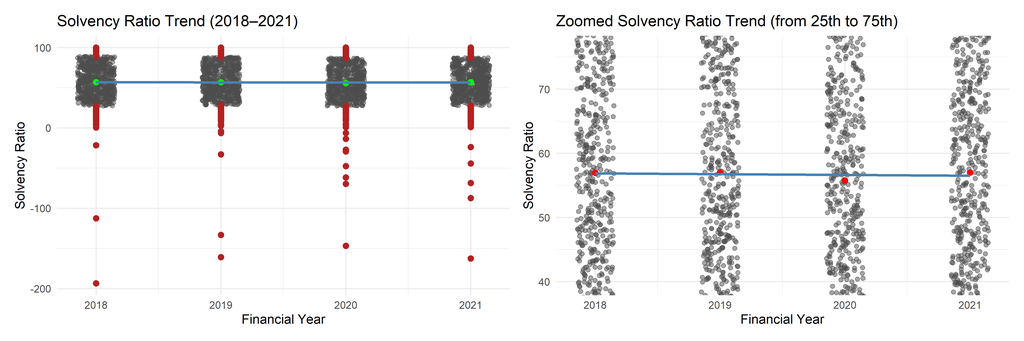

```r
overallsr_trend_plot <- ggplot(
  overall_sr_data, aes(x = financial_year, y = recal_solvency_ratio)) +
  geom_jitter(data = subset(overall_sr_data, !outlier_flag),
              width = 0.15, height = 0, alpha = 0.5, colour = "grey30") +
  # outliers point
  geom_point(
    data = subset(overall_sr_data, outlier_flag),
    colour = "firebrick", size = 2) +
  # yearly mean
  stat_summary(fun = "mean", geom = "point", colour = "green", size = 2)+
  geom_smooth(colour = "steelblue", se = FALSE, method = "lm") +
  labs(
    title = "Solvency Ratio Trend (2018–2021)",
    x = "Financial Year",
    y = "Solvency Ratio"
  ) +
  theme_minimal()

overallsr_trend_plot_zoom <- ggplot(
  overall_sr_data, aes(x = financial_year, y = recal_solvency_ratio)) +
  geom_jitter(data = subset(overall_sr_data, !outlier_flag),
              width = 0.15, height = 0, alpha = 0.5, colour = "grey30") +
  geom_point(data = subset(overall_sr_data, outlier_flag),
             colour = "firebrick", size = 2) +
  stat_summary(fun = "mean", geom = "point", colour = "red", size = 2) +
  geom_smooth(colour = "steelblue", se = FALSE, method = "lm") +
  # set up zoom in section
  coord_cartesian(ylim = c(zoomin_section_sr$ymin, zoomin_section_sr$ymax)) +
  labs(
    title = "Zoomed Solvency Ratio Trend (from 25th to 75th)",
    x = "Financial Year",
    y = "Solvency Ratio"
  ) +
  theme_minimal()

overallsr_trend_plot | overallsr_trend_plot_zoom
```

**Distributional Shifts Before and During the Pandemic**

Figure 28 shows that the solvency ratio distribution remained largely unchanged between the pre-pandemic (2018–2019) and during-pandemic (2020–2021) periods. Both periods display similar medians and interquartile ranges, suggesting that firms’ long-term financial structures were only marginally affected by the pandemic. The lower tails show minimal differences, with no substantial increase in outliers, indicating that few firms experienced severe balance-sheet deterioration. Overall, solvency positions were stable across the two periods, reflecting that long-term debt-paying capacity was more resilient than short-term liquidity during the pandemic.

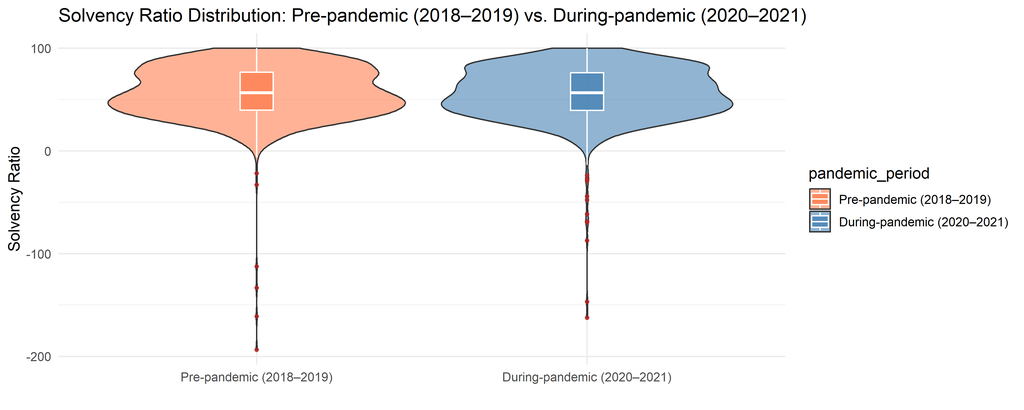

Figure 28: Distribution between the pre-pandemic (2018–2019) and during-pandemic (2020–2021) periods. The solvency ratio is theoretically capped at 100, as total shareholders’ equity cannot exceed total assets. Lecture 7, slides 6 and 8

```r
overallsr_distr_plot <- ggplot(
  overall_sr_data, aes(x = pandemic_period, y = recal_solvency_ratio,
                       fill = pandemic_period)) +
  geom_violin(alpha = 0.6) +
  geom_boxplot(width = 0.1, color = "white", alpha = 0.8,
               outlier.colour = "firebrick", outlier.size = 1) +
  scale_fill_manual(values = c("Pre-pandemic (2018–2019)" = "coral",
                               "During-pandemic (2020–2021)" = "steelblue")) +
  labs(
    title = "Solvency Ratio Distribution: Pre-pandemic (2018–2019) vs. During-pandemic (2020–2021)",
    x = "",
    y = "Solvency Ratio"
  ) +
  theme_minimal()

overallsr_distr_plot
```

**Relationship Between Total Shareholders Equity (TS) and Total Assets (TA)**

Figure 29 shows a strong relationship between total assets and shareholders’ equity across both pre-pandemic (2018–2019) and during-pandemic (2020–2021) periods. The close alignment of points along the diagonal line and the near-complete overlap between periods indicate that firms’ capital structures remained stable, with asset and equity movements largely proportional.

While some firms—most notably **THAI Airways International PCL** in 2021—deviate markedly below the main cluster due to severe equity erosion, **PTT PCL** remains near the main equity–asset, highlighting how large-cap firms preserved balance-sheet strength throughout the pandemic. Overall, the results suggest that firms’ long-term solvency and capital structures were largely unaffected by the crisis.

```r
# left: linear
ts_ta_plot_linear <- ggplot(
  overall_sr_data, aes(x = TA_bn,
                       y = TS_bn,
                       colour = pandemic_period,
                       text = paste0(
                         "Company: ", company_name,
                         "<br>Year: ", financial_year,
                         "<br>Industry: ", industry_category,
                         "<br>SR: ", round(recal_solvency_ratio, 2), " %",
                         "<br>TS: ", round(total_shareholders_equity, 2),
                         "<br>TA: ", round(total_assets, 2)
                       ))) +
  geom_point(alpha = 0.6) +
  geom_smooth(method = "lm", color = "grey50", linetype = "dashed") +
  labs(
    x = "Total Assets (THB bn)",
    y = "Total Shareholders Equity (THB bn)") +
  theme_minimal() +
  theme(plot.title = element_blank())

# right: log
ts_ta_plot_log <- ggplot(overall_sr_data, aes(x = TA_asinh,
                                              y = TS_asinh,
                                              colour = pandemic_period,
      text = paste0("Company: ", company_name,
                    "<br>Year: ", financial_year,
                    "<br>Industry: ", industry_category,
                    "<br>SR: ", round(recal_solvency_ratio, 2), " %",
                    "<br>TS: ", round(total_shareholders_equity, 2),
                    "<br>TA: ", round(total_assets, 2)))) +
  geom_point(alpha = 0.6) +
  geom_smooth(method = "lm", color = "grey50", linetype = "dashed") +
  scale_x_log10(
    labels = label_number(accuracy = 0.1)
  ) +
  scale_y_log10(
    labels = label_number(accuracy = 0.1)
  ) +
  labs(
    x = "asinh(Total Assets, THB bn)",
    y = "asinh(Total Shareholders Equity, THB bn)") +
  theme_minimal() +
  theme(plot.title = element_blank())

# plotly
pL <- ggplotly(ts_ta_plot_linear, tooltip = "text") |>
  style(showlegend = FALSE)
pR <- ggplotly(ts_ta_plot_log, tooltip = "text")

# combine the plot
subplot(
  pL, pR,
  shareX = FALSE, shareY = FALSE,
  nrows = 1,
  margin = 0.12,
  titleX = TRUE, titleY = TRUE) |>
  plotly::layout(
    margin = list(t = 120, b = 90, l = 70, r = 110),
    xaxis  = list(domain = c(0.00, 0.47)),
    xaxis2 = list(domain = c(0.53, 1.00)),
    legend = list(orientation = "h", x = 0.5, y = -0.15,
                  title = list(text = "Pandemic period")),
    title = list(
      text = paste0("Total Shareholders Equity–Assets Relationship Before and During the Pandemic"),
      x = 0.5, xanchor = "center"
    ),
    margin = list(t = 70),
    annotations = list(
      list(x = 0.225, y = 1.06, xref = "paper", yref = "paper",
           text = "Linear scale (THB bn)", showarrow = FALSE,
           xanchor = "center",
           font = list(size = 10)),
      list(x = 0.775, y = 1.06, xref = "paper", yref = "paper",
           text = "asinh–asinh scale", showarrow = FALSE, xanchor = "center",
           font = list(size = 10))))
```

[interactive chart not shown]

Figure 29: Distribution of Total Shareholders Equity and Assets under linear (left panel) and asinh–asinh scales (right panel), comparing the pre-pandemic (2018–2019) and during-pandemic (2020–2021) periods. Lecture 6, slides 20.

To further understand the difference in different industries, comparing their total shareholders equity and total assets changes before and during the pandemic to identify if long-term debt-paying ability is weakening.

##### Iudstry-Level Solvency Ratio Analysis

**Yearly Trend by Industry**

```r
# median for year x industry
industry_sr_year <- overall_sr_data |>
  group_by(industry_category, financial_year) |>
  summarise(
    median_sr = median(recal_solvency_ratio, na.rm = TRUE),
    n = n(),
    .groups = "drop"
  )

# Industry abbreviation for facet plot
abbr_labels <- c(
  "Accommodation and Food Services" = "A.F.S.",
  "Administrative, Support, Waste Mgmt., Remediation Services" = "A.W.M.R.",
  "Agriculture, Forestry, Fishing, Hunting" = "A.F.F.H.",
  "Arts, Entertainment, Recreation" = "A.E.R.",
  "Construction" = "CONS.",
  "Educational Services" = "EDU.",
  "Finance and Insurance" = "FIN.",
  "Health Care and Social Assistance" = "H.C.S.A.",
  "Information" = "INFO.",
  "Manufacturing" = "MFG.",
  "Management of Companies & Enterprises" = "M.C.E.",
  "Mining, Quarrying, Oil, Gas Extraction" = "MIN.O.G.",
  "Other Services (except Public Administration)" = "OTH.SRV.",
  "Professional, Scientific, Tech. Services" = "P.S.T.S.",
  "Public Administration" = "PUB.ADM.",
  "Real Estate, Rental, Leasing" = "R.E.R.L.",
  "Retail Trade" = "RET.",
  "Transportation and Warehousing" = "TRANS.W.",
  "Utilities" = "UTIL.",
  "Wholesale Trade" = "WHSL."
)

industry_sr_year <- industry_sr_year |>
  mutate(industry_abbr  = recode(industry_category, !!!abbr_labels))
```

Figure 30 shows that most industries maintained stable solvency ratios over 2018–2021, with a mild dip in 2020 followed by recovery in 2021. However, patterns diverged across industries such as Transportation and Warehousing, Real Estate, Retail, and Education exhibited persistent declines, indicating weaker capital structures or sustained leverage pressure. In contrast, Public Administration, Construction, Finance, and Mining recorded noticeable improvements, reflecting fiscal support and post-pandemic recovery in investment activities. Overall, most industries’ long-term debt-paying ability remained largely unaffected by pandemic.

```r
industry_yrsrmedian_plot <- ggplot(industry_sr_year, aes(
  x = financial_year,
  y = median_sr,
  group = industry_abbr,
  text = paste0(
    "<br>Year: ", financial_year,
    "<br>Industry: ", industry_category,
    "<br>Median Solvency Ratio: ", median_sr))) +
  geom_line(color = "steelblue") +
  geom_point(size = 1.5, color = "darkorange") +
  facet_wrap(~ industry_abbr, scales = "free_y") +
  labs(
    title = "Median Solvency Ratio (2018–2021) by Industry",
    x = "Financial Year",
    y = "Median Solvency Ratio"
  ) +
  theme_minimal()

# plotly
industry_yrsrmedian_plotly <- ggplotly(
  industry_yrsrmedian_plot, tooltip = "text")
industry_yrsrmedian_plotly
```

[interactive chart not shown]

Figure 30: Yearly median Slovency Ratio for each industry

Based on the industry-level trends, two contrasting groups are identified:

1. **Decrease when pandemic effect:** Transportation & Warehousing, Real Estate, Education Services, and Retail Trade.
2. **Increase or Rebound when pandemic effect:** Public Administration, Construction, Finance and Insurance, and Mining, Quarrying, Oil, Gas Extraction.

```r
grp_srdecrease <- c("Transportation and Warehousing",
                  "Real Estate, Rental, Leasing",
                  "Educational Services",
                  "Retail Trade")

grp_srincrease <- c("Public Administration",
                  "Construction",
                  "Finance and Insurance",
                  "Mining, Quarrying, Oil, Gas Extraction")

sr_decgroup_overall <- overall_sr_data |>
  filter(industry_category %in% grp_srdecrease)

sr_incgroup_overall <- overall_sr_data |>
  filter(industry_category %in% grp_srincrease)
```

Examining the movement of total shareholders’ equity and total assets within these industries helps explain whether the changes in long-term debt-paying ability from asset contraction, increased leverage, or policy-driven adjustments.

**Solvency Ratio Decrease When Pandemic Effect**

Figure 31 shows that the decline in solvency ratios across the four industries resulted from different balance-sheet adjustments:

- **Educational Services:** The lower-positioned point reflecting accumulated losses and weakened capital bases caused by prolonged school closures and reduced revenues.
- **Real Estate:** The downward shift indicates higher leverage, as liabilities grew faster than assets amid weak property demand and delayed projects.
- **Retail Trade:** The stable alignment of points shows limited change in equity–asset balance, suggesting that firms maintained long-term solvency despite temporary short-term pressure.
- **Transportation and Warehousing:** The downward and rightward movement suggests both asset contraction and equity decline due to cash flow disruptions and rising debt levels.

```r
decsr_bygroup_plot <- ggplot(sr_decgroup_overall,
                              aes(x = TA_asinh, y = TS_asinh,
                                  colour = factor(financial_year),
      text = paste0("Company: ", company_name,
                    "<br>Year: ", financial_year,
                    "<br>Industry: ", industry_category,
                    "<br>SR: ", round(recal_solvency_ratio, 2), " %",
                    "<br>TS: ", round(total_shareholders_equity, 2),
                    "<br>TA: ", round(total_assets, 2)))) +
  geom_point(alpha = 0.6) +
  facet_wrap(~ industry_category, scales = "free_y") +
  labs(
    title = "TS vs TA (asinh–asinh) — Industries with Solvency Ratio Decrease",
    x = "Total Assets (asinh THB bn)",
    y = "Total Shareholders' Equity (asinh THB bn)",
    colour = "Financial Year") +
  theme_minimal()

#plotly
decsr_bygroup_plotly <- ggplotly(decsr_bygroup_plot, tooltip = "text") |>
  plotly::layout(legend = list(orientation = "h", x = 0.5,
                       xanchor = "center", y = -0.12))

decsr_bygroup_plotly
```

[interactive chart not shown]

Figure 31: Asinh–asinh scatter of Total Shareholders’ Equity (TS) and Total Assets (TA) for decreased solvency ratio industries. Points are colored by year (2018–2021). Tutorial, week 6.

**Solvency Ratio Increase When Pandemic Effect**

Figure 32 shows that the increase in solvency ratios across these industries mainly reflects strengthened equity positions and more conservative leverage management during the pandemic period:

- **Construction:** The upward shift indicates stronger equity growth relative to assets, supported by renewed infrastructure investment and government spending.
- **Finance and Insurance:** The points remained tightly aligned along the equity–asset proportion, suggesting stable and well-capitalized balance sheets. Likely maintain strong solvency positions throughout the pandemic with support and low interest rates.
- **Mining, Quarrying, Oil, Gas Extraction:** The upward movement reflects equity recovery and reduced leverage, likely driven by a rebound in commodity prices and cautious capital expenditure following before-pandemic downturns (2019).
- **Public Administration:** “Public Administration” representing government-related and state-owned entities, shows a clear upward shift due to fiscal injections and deferred expenditure programs, which temporarily boosted equity and strengthened long-term solvency.

```r
incsr_bygroup_plot <- ggplot(sr_incgroup_overall,
                              aes(x = TA_asinh, y = TS_asinh,
                                  colour = factor(financial_year),
      text = paste0("Company: ", company_name,
                    "<br>Year: ", financial_year,
                    "<br>Industry: ", industry_category,
                    "<br>SR: ", round(recal_solvency_ratio, 2), " %",
                    "<br>TS: ", round(total_shareholders_equity, 2),
                    "<br>TA: ", round(total_assets, 2)))) +
  geom_point(alpha = 0.6) +
  facet_wrap(~ industry_category, scales = "free_y") +
  labs(
    title = "TS vs TA (asinh–asinh) — Industries with Solvency Ratio Increase",
    x = "Total Assets (asinh THB bn)",
    y = "Total Shareholders' Equity (asinh THB bn)",
    colour = "Financial Year") +
  theme_minimal()

#plotly
incsr_bygroup_plotly <- ggplotly(incsr_bygroup_plot, tooltip = "text") |>
  plotly::layout(legend = list(orientation = "h", x = 0.5,
                       xanchor = "center", y = -0.12))

incsr_bygroup_plotly
```

[interactive chart not shown]

Figure 32: Asinh–asinh scatter of Total Shareholders’ Equity (TS) and Total Assets (TA) for increased solvency ratio industries. Points are colored by year (2018–2021). Tutorial, week 6.

##### Conclusion for Solvency Ratio

Overall, firms’ long-term debt-paying ability stayed stable during the pandemic. Solvency ratios showed only a small drop in 2020 and recovered quickly in 2021, suggesting no major impact on overall financial strength. The decline was mainly seen in Transportation & Warehousing, Real Estate, Retail, and Education, where equity weakened or debt increased, while Public Administration, Construction, Finance, and Mining improved with policy and investment support. In general, the pandemic caused temporary short-term pressure but did not lead to long-term solvency problems, as most industries recovered steadily by 2021.

#### Impact of the Pandemic on Corporate Debt-Paying Ability

The pandemic caused a brief but uneven impact on firms’ debt-paying ability.

Current ratios declined in 2020 but rebounded in 2021, indicating rapid liquidity recovery (Figure 21, Figure 22). Short-term stress was concentrated in industries such as Transportation & Warehousing, Real Estate, and Education, driven by asset contractions or rising liabilities (Figure 23, Figure 25), while Public Administration and Administrative & Waste Management improved through fiscal inflows (Figure 26).

Large firms such as PTT PCL remained liquid throughout, underscoring scale resilience. In contrast, solvency ratios stayed largely stable, with only minor fluctuations and sector-specific dips (Figure 27, Figure 30).

Overall, the pandemic temporarily weakened short-term liquidity but did not materially affect long-term solvency, showing that most firms preserved strong balance sheets and recovered their debt-paying capacity by 2021.

## Conclusions

### Hypothesis Testing

**ROA**

We test the null hypothesis $H_0$: There is no relationship between ROA and financial year.

To reduce the influence of extreme values and make year-to-year patterns clearer, the ROA values were transformed using the inverse hyperbolic sine (asinh) function.

Among the ten lineup panels (Figure 33), Panel 9 corresponds to the true data.

Unlike most null panels, Panel 9 shows a discernible dip in 2020 followed by a rebound in 2021, a coherent temporal pattern that does not arise from random permutation. Because this systematic 2020 slight dip and subsequent recovery are visually distinguishable from the nulls, we **reject** $H_0$ and conclude tha+t ROA varies with financial year.

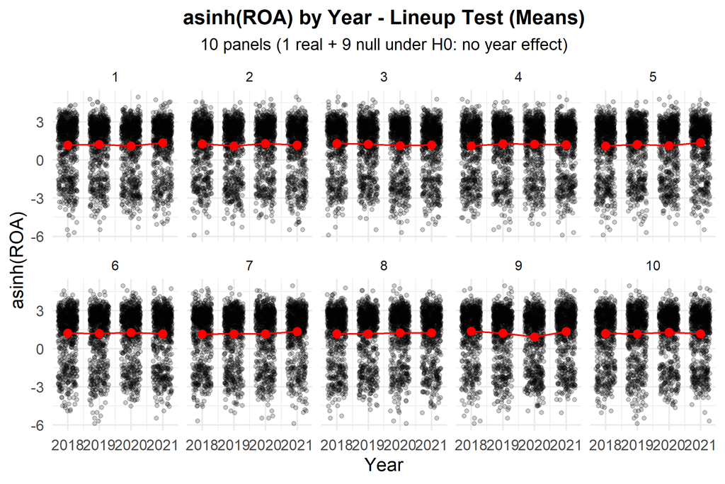

Figure 33: Lineup test of asinh-transformed ROA by financial year. Ten panels are displayed: one shows the real data, while the remaining nine display permuted versions generated under the null hypothesis of no year effect. Reference: Lecture 4 - Hypothesis Testing

```r
set.seed(35717343)

# Prepare data: asinh-transform ROA
base_roa <- osiris_tidy %>%
  transmute(
    financial_year,
    value = asinh(recal_roa)
  )

# Build lineup under H0 (no year effect)
roa_lineup <- lineup(null_permute("value"), true = base_roa, n = 10)

# Plot: jittered points; red markers/line show means
ggplot(roa_lineup, aes(x = financial_year, y = value)) +
  geom_jitter(width = 0.3, alpha = 0.2, size = 0.9) +
  stat_summary(fun = mean, geom = "point", colour = "red", size = 2) +
  stat_summary(fun = mean, geom = "line",  colour = "red", linewidth = 0.5) +
  facet_wrap(~ .sample, ncol = 5) +
  labs(
    title = "asinh(ROA) by Year - Lineup Test (Means)",
    subtitle = "10 panels (1 real + 9 null under H0: no year effect)",
    x = "Year", y = "asinh(ROA)"
  ) +
  theme_minimal() +
  theme(
    plot.title    = element_text(hjust = 0.5, face = "bold", size = 12),
    plot.subtitle = element_text(hjust = 0.5, size = 10),
    strip.text    = element_text(size = 8)
  )
```

**ROCE**

We test the null hypothesis $H_0$: There is no relationship between ROCE and financial year.

Again, the asinh transformation was applied to stabilise the distribution and enhance the visibility of potential trends.

In the lineup of ten panels (Figure 34), Panel 9 represents the real data.

This panel also hints at a small dip around 2020 and a subsequent rise in 2021, consistent with the ROA lineup, though the magnitude of this pattern is weaker.

Given that similar fluctuations occasionally appear in several null panels, Because this pattern is visually distinguishable from the nulls, we **reject** $H_0$ and conclude that ROCE varies with financial year.

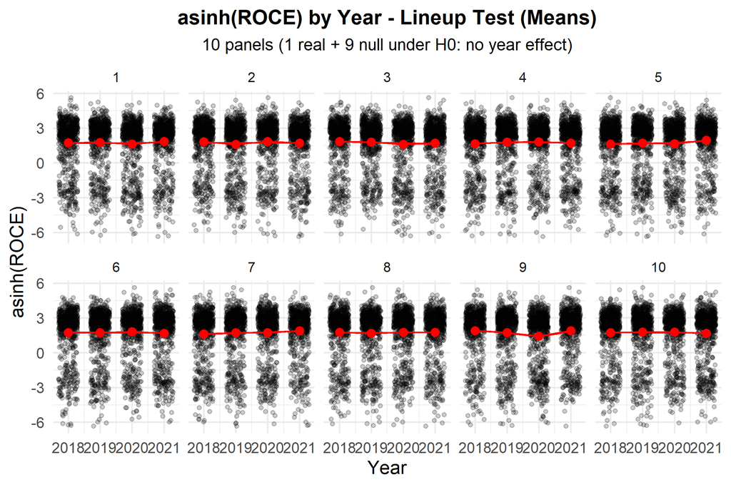

Figure 34: Lineup test of asinh-transformed ROCE by financial year. Ten panels are displayed: one shows the real data, while the remaining nine display permuted versions generated under the null hypothesis of no year effect. Reference: Lecture 4 - Hypothesis Testing

```r
set.seed(35717343)

# Prepare data: asinh-transform ROCE
base_roce <- osiris_tidy %>%
  transmute(
    financial_year,
    value = asinh(roce_imputed)
  )

# Build lineup under H0 (no year effect)
roce_lineup <- lineup(null_permute("value"), true = base_roce, n = 10)

# Plot: jittered points; red markers/line show means
ggplot(roce_lineup, aes(x = financial_year, y = value)) +
  geom_jitter(width = 0.3, alpha = 0.2, size = 0.9) +
  stat_summary(fun = mean, geom = "point", colour = "red", size = 2) +
  stat_summary(fun = mean, geom = "line",  colour = "red", linewidth = 0.5) +
  geom_smooth(method = mgcv::gam, formula = y ~ s(x, k = 4),
              colour = "red", se = FALSE, linewidth = 0.5) +
  facet_wrap(~ .sample, ncol = 5) +
  labs(
    title = "asinh(ROCE) by Year - Lineup Test (Means)",
    subtitle = "10 panels (1 real + 9 null under H0: no year effect)",
    x = "Year", y = "asinh(ROCE)"
  ) +
  theme_minimal() +
  theme(
    plot.title    = element_text(hjust = 0.5, face = "bold", size = 12),
    plot.subtitle = element_text(hjust = 0.5, size = 10),
    strip.text    = element_text(size = 8)
  )
```

**EBIT margin**

We test the null hypothesis $H_0$: *There is no systematic relationship between EBIT Margin and financial year.*

The asinh transformation was applied to stabilize the variance and enhance the visibility of potential trends. Upon inspecting the lineup of 10 panels, it is not possible to confidently distinguish the real data plot from the null plots. The weak “V-shaped” pattern observed in the data appears with similar frequency and magnitude in several of the randomly generated null panels.

In the lineup of ten panels, Panel 5 represents the real data.

Because the evidence is insufficient to distinguish the real trend from random noise, we **fail to reject the null hypothesis** $H_0$. Essentially, while we can see a slight V-shape, the statistical test tells us: “This pattern isn’t strong enough to prove it’s a real trend. It could have happened by chance.”

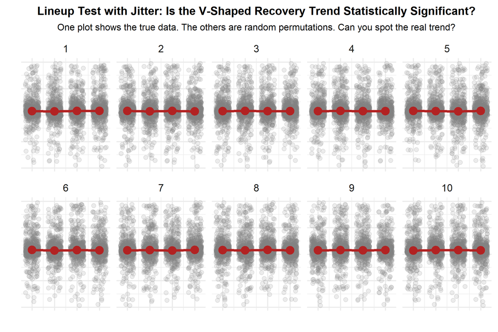

```r
set.seed(35567201)

lineup_data_jitter <- lineup(
  null_permute("financial_year"),
  osiris_tidy,
  n = 10
)

ggplot(lineup_data_jitter, aes(x = financial_year, y = ebit_margin_imputed)) +
  geom_jitter(width = 0.3, height = 0, alpha = 0.15, na.rm = TRUE, color = "gray50") +
  stat_summary(fun = median, geom = "line", aes(group = .sample), color = "firebrick", linewidth = 1) +
  stat_summary(fun = median, geom = "point", color = "firebrick", size = 3) +
  facet_wrap(~ .sample, ncol = 5) +
  labs(
    title = "Lineup Test with Jitter: Is the V-Shaped Recovery Trend Statistically Significant?",
    subtitle = "One plot shows the true data. The others are random permutations. Can you spot the real trend?",
    x = "", y = ""
  ) +
  theme_minimal() +
  theme(
    axis.text.x = element_blank(),
    axis.text.y = element_blank(),
    axis.ticks = element_blank(),
    plot.title = element_text(size = 10, face = "bold", hjust = 0.5),
    plot.subtitle = element_text(size = 8, hjust = 0.5)
  )
```

**Current Ratio**

We test the null hypothesis $H_0$: There is no relationship between Current Ratio and financial year.

To reduce the influence of extreme values and visualise the trend, the current ratio was transformed using a logarithmic scale (log10).

In the lineup of ten panels, Panel 9 represents the real data.

Although panel 9 shows a slight dip in 2020 followed by a rebound in 2021, similar patterns appear in several null panels; therefore, we **fail to reject** the null hypothesis $H_0$: no year effect in log10(Current Ratio). The line-up provides insufficient visual evidence of a year effect, and the 2020 decline appears weak and indistinguishable from patterns observed under the null distribution.

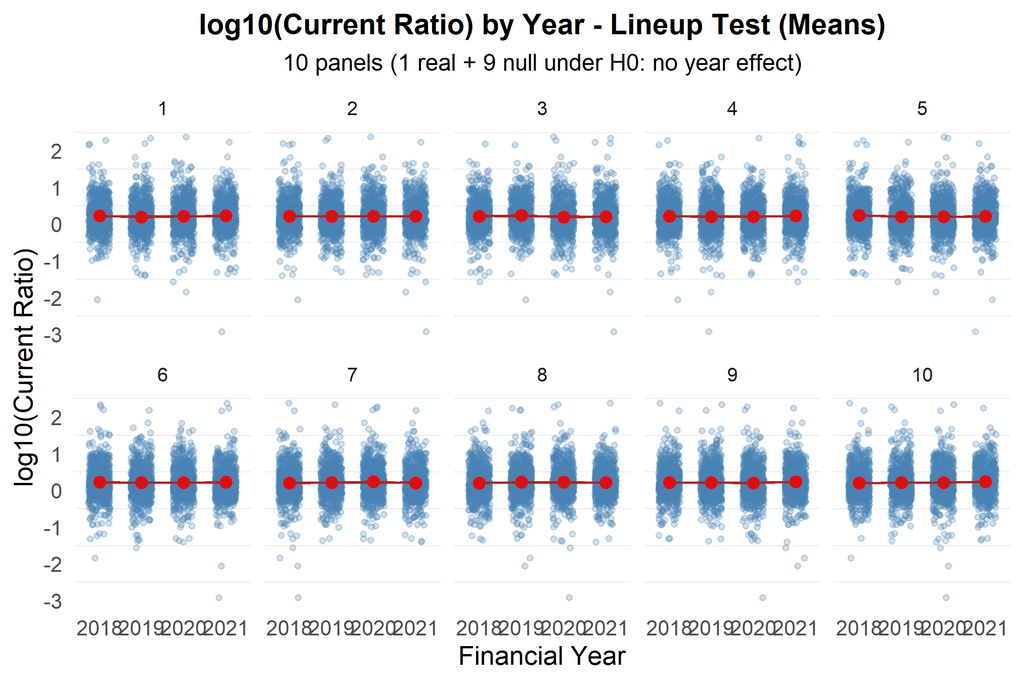

Figure 36: Ten panels are shown (one real and nine generated under H0: no year effect). Each panel displays jittered firm-year observations, yearly means (red dots), and a linear trend. Lecture 4 - Hypothesis Testing

```r
set.seed(35461586)

# Prepare data
base_cr <- overall_cr_data |>
  mutate(
    financial_year = factor(financial_year, levels = sort(unique(financial_year))),
    year_num = as.integer(financial_year),
    value   = log_cr
  ) |>
  select(financial_year, year_num, value)

# Build lineup under H0 (no year effect)
cr_lineup <- lineup(null_permute("value"), true = base_cr, n = 10)

# Plot: jittered points; red markers/line show MEANS
ggplot(cr_lineup, aes(x = financial_year, y = value)) +
  geom_jitter(width = 0.25, alpha = 0.25, size = 0.9, colour = "steelblue") +
  stat_summary(fun = mean, geom = "point", colour = "red", size = 2) +
  stat_summary(fun = mean, geom = "line",  colour = "red", linewidth = 0.5, aes(group = .sample)) +
  geom_smooth(
    aes(x = year_num, y = value, group = .sample),
    method = "lm", se = FALSE, colour = "firebrick", linewidth = 0.5
  ) +
  facet_wrap(~ .sample, ncol = 5) +
  labs(
    title = "log10(Current Ratio) by Year - Lineup Test (Means)",
    subtitle = "10 panels (1 real + 9 null under H0: no year effect)",
    x = "Financial Year",
    y = "log10(Current Ratio)"
  ) +
  theme_minimal() +
  theme(
    plot.title = element_text(hjust = 0.5, face = "bold", size = 12),
    plot.subtitle = element_text(hjust = 0.5, size = 10),
    strip.text = element_text(size = 8),
    panel.grid.major = element_blank(),
    legend.position = "none"
  )
```

**Solvency Ratio**

We test the null hypothesis $H_0$: There is no relationship between Solvency Ratio and financial year.

In the lineup of ten panels, Panel 6 represents the real data.

Although the real panel shows a very slight decrease in the Solvency Ratio around 2020, the overall yearly pattern remains weak and indistinct. Similar variations appear across several null panels, indicating that the observed fluctuation is minor and not systematically different from what would be expected under randomness. Therefore, we **fail to reject** the null hypothesis that the Solvency Ratio does not vary systematically across years.

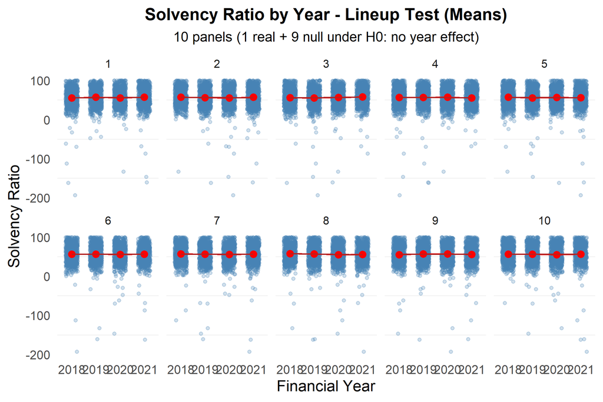

Figure 37: Ten panels are shown (one real and nine generated under H0: no year effect). Each panel displays jittered firm-year observations, yearly means (red dots), and a linear trend. Lecture 4 - Hypothesis Testing

```r
set.seed(35461587)

# Prepare data
base_sr <- overall_sr_data |>
  mutate(
    financial_year = factor(financial_year, levels = sort(unique(financial_year))),
    year_num = as.integer(financial_year),
    value   = recal_solvency_ratio
  ) |>
  select(financial_year, year_num, value)

# Build lineup under H0 (no year effect)
sr_lineup <- lineup(null_permute("value"), true = base_sr, n = 10)

# Plot: jittered points; red markers/line show MEANS
ggplot(sr_lineup, aes(x = financial_year, y = value)) +
  geom_jitter(width = 0.25, alpha = 0.25, size = 0.9, colour = "steelblue") +
  stat_summary(fun = mean, geom = "point", colour = "red", size = 2) +
  stat_summary(fun = mean, geom = "line",  colour = "red", linewidth = 0.5, aes(group = .sample)) +
  geom_smooth(
    aes(x = year_num, y = value, group = .sample),
    method = "lm", se = FALSE, colour = "firebrick", linewidth = 0.5
  ) +
  facet_wrap(~ .sample, ncol = 5) +
  labs(
    title = "Solvency Ratio by Year - Lineup Test (Means)",
    subtitle = "10 panels (1 real + 9 null under H0: no year effect)",
    x = "Financial Year",
    y = "Solvency Ratio"
  ) +
  theme_minimal() +
  theme(
    plot.title = element_text(hjust = 0.5, face = "bold", size = 12),
    plot.subtitle = element_text(hjust = 0.5, size = 10),
    strip.text = element_text(size = 8),
    panel.grid.major = element_blank(),
    legend.position = "none"
  )
```

### How did the pandemic affect corporate financials?

Taken together, the results show that the pandemic mainly hurt firms’ income generation (profitability) rather than their financial stability (debt-paying capacity). Firms experienced a temporary earnings collapse but largely preserved their capital base and liquidity buffers, enabling a relatively fast financial recovery once economic activity resumed.

The lineup hypothesis tests support this interpretation: profitability measures (ROA and ROCE) showed significant year effects, confirming a genuine 2020 downturn and 2021 rebound, while EBIT Margin, Current Ratio, and Solvency Ratio exhibited no statistically distinct shifts across years. These patterns indicate that although profits were temporarily disrupted, firms maintained stable liquidity and solvency positions—highlighting both the short-term sensitivity of earnings to the pandemic shock and the underlying resilience of Thai corporate balance sheets.

However, a key limitation is that the dataset primarily covers large listed firms (694 listed companies, with only 9 delisted), whose financial structures are generally more stable and supported by stronger capital bases. The analysis therefore cannot capture the full extent of the pandemic’s impact on small and medium-sized enterprises (SMEs), which likely faced greater liquidity pressures and weaker recovery paths. The conclusions here thus apply mainly to listed firms included in the dataset, rather than to all Thai businesses.

In summary, the pandemic temporarily weakened Thai firms’ profitability but left their financial stability largely intact, demonstrating a short-lived shock rather than a structural financial deterioration.

## Resources

The materials used for this report are:

**Packages**

1. Wickham H, Averick M, Bryan J, Chang W, McGowan LD, François R, Grolemund G, Hayes A, Henry L, Hester J, Kuhn M, Pedersen TL, Miller E, Bache SM, Müller K, Ooms J, Robinson D, Seidel DP, Spinu V, Takahashi K, Vaughan D, Wilke C, Woo K, Yutani H (2019). “Welcome to the tidyverse.” *Journal of Open Source Software*, *4*(43), 1686. [doi:10.21105/joss.01686](https://doi.org/10.21105/joss.01686).
2. Zhu H (2024). *kableExtra: Construct Complex Table with ‘kable’ and Pipe Syntax*. doi:10.32614/CRAN.package.kableExtra https://doi.org/10.32614/CRAN.package.kableExtra, R package version 1.4.0, https://CRAN.R-project.org/package=kableExtra.
3. Xie Y (2025). *knitr: A General-Purpose Package for Dynamic Report Generation in R*. R package version 1.50, https://yihui.org/knitr/.

Yihui Xie (2015) Dynamic Documents with R and knitr. 2nd edition. Chapman and Hall/CRC. ISBN 978-1498716963

Yihui Xie (2014) knitr: A Comprehensive Tool for Reproducible Research in R. In Victoria Stodden, Friedrich Leisch and Roger D. Peng, editors, Implementing Reproducible Computational Research. Chapman and Hall/CRC. ISBN 978-1466561595

4. Xie Y, Cheng J, Tan X, Aden-Buie G (2025). *DT: A Wrapper of the JavaScript Library ‘DataTables’*. doi:10.32614/CRAN.package.DT https://doi.org/10.32614/CRAN.package.DT, R package version 0.34.0, https://CRAN.R-project.org/package=DT.
5. Tierney N, Cook D (2023). “Expanding Tidy Data Principles to Facilitate Missing Data Exploration, Visualization and Assessment of Imputations.” *Journal of Statistical Software*, *105*(7), 1-31. doi:10.18637/jss.v105.i07 https://doi.org/10.18637/jss.v105.i07.
6. Müller K (2025). *here: A Simpler Way to Find Your Files*. doi:10.32614/CRAN.package.here https://doi.org/10.32614/CRAN.package.here, R package version 1.0.2, https://CRAN.R-project.org/package=here.
7. Firke S (2024). *janitor: Simple Tools for Examining and Cleaning Dirty Data*. doi:10.32614/CRAN.package.janitor https://doi.org/10.32614/CRAN.package.janitor, R package version 2.2.1, https://CRAN.R-project.org/package=janitor.
8. Pedersen T (2025). *patchwork: The Composer of Plots*. doi:10.32614/CRAN.package.patchwork https://doi.org/10.32614/CRAN.package.patchwork, R package version 1.3.2, https://CRAN.R-project.org/package=patchwork.
9. Clarke E, Sherrill-Mix S, Dawson C (2023). *ggbeeswarm: Categorical Scatter (Violin Point) Plots*. doi:10.32614/CRAN.package.ggbeeswarm https://doi.org/10.32614/CRAN.package.ggbeeswarm, R package version 0.7.2, https://CRAN.R-project.org/package=ggbeeswarm.
10. Wickham H, Pedersen T, Seidel D (2025). *scales: Scale Functions for Visualization*. doi:10.32614/CRAN.package.scales https://doi.org/10.32614/CRAN.package.scales, R package version 1.4.0, https://CRAN.R-project.org/package=scales.
11. C. Sievert. Interactive Web-Based Data Visualization with R, plotly, and shiny. Chapman and Hall/CRC Florida,
13. Buja A, Cook D, Hofmann H, Lawrence M, Lee E, Swayne DF, Wickham H (2009). “Statistical Inference for Exploratory Data Analysis and Model Diagnostics.” *Royal Society Philosophical Transactions A*, *367*(1906), 4361-4383. doi:10.1098/rsta.2009.0120 https://doi.org/10.1098/rsta.2009.0120.
14. Wood, S.N. (2017) Generalized Additive Models: An Introduction with R (2nd edition). Chapman and Hall/CRC.
15. Buja A, Cook D, Hofmann H, Lawrence M, Lee E, Swayne DF, Wickham H (2009). “Statistical Inference for Exploratory Data Analysis and Model Diagnostics.” *Royal Society Philosophical Transactions A*, *367*(1906), 4361-4383. doi:10.1098/rsta.2009.0120 https://doi.org/10.1098/rsta.2009.0120.

**Data resources and references**

1. Wikipedia contributors. (n.d.). Timeline of the COVID-19 pandemic in Thailand. In Wikipedia. Retrieved October 12, 2025, from https://en.wikipedia.org/wiki/Timeline_of_the_COVID-19_pandemic_in_Thailand
2. Paweenawat, S. W., & Liao, H. (2025, January 17). Thailand’s economic recovery after COVID-19: Employment, wages, and inequality. Institute of Developing Economies (IDE-JETRO). Retrieved October 12, 2025, from https://www.ide.go.jp/English/ResearchColumns/Columns/2025/paweenawat_and_liao.html
3. Bureau van Dijk. (n.d.). Osiris database. Retrieved October 12, 2025, from https://login.bvdinfo.com/R1/OsirisNeo
4. Moody’s Analytics. (2021). Osiris user guide. Bureau van Dijk. Retrieved October 12, 2025, from https://information.moodysanalytics.com/000000DAZUSRBCYCJ/
5. World Bank. (2024). *GDP growth (annual %) – Thailand*. World Development Indicators. https://data.worldbank.org/indicator/NY.GDP.MKTP.KD.ZG?locations=TH

## Generative AI analysis

The links to my use of ChatGPT for help on this assignment are:

- [TING-TING - AI LINK](https://chatgpt.com/share/68f60c96-9d7c-800d-afd0-5bf2dc7cebfd)
- [TZU-HSUAN - AI LINK](https://chatgpt.com/share/68f61310-6bdc-8009-ab40-da8af3298527)
- [Heng-Hsieh - AI LINK](https://chatgpt.com/share/68f57a63-f9e0-8000-a2f5-b0d5db8e083e)
- [Nutchanok - AI LINK](https://chatgpt.com/share/68f627a9-4ed0-800a-ae38-1f2bb5ba6a93)

We primarily used AI for visualization and coding debugging. Since our analysis is based on financial statements, two of our group members with accounting backgrounds raised concerns about the accuracy of AI-generated interpretations. In addition, there are discrepancies between the Osiris dataset user guide and the actual calculation methods, which made it difficult for us to rely on AI to complete the analysis. As a result, we were unable to fully adopt AI for this project, which also increased the level of challenge.